# What can we learn about human individual face recognition from experimental studies in monkeys? - ScienceDirect

## [Vision Research](https://www.sciencedirect.com/journal/vision-research)

[Volume 157](https://www.sciencedirect.com/journal/vision-research/vol/157/suppl/C), April 2019, Pages 142-158

# What can we learn about human individual face recognition from experimental studies in monkeys?

https://doi.org/10.1016/j.visres.2018.03.012[Get rights and content](https://s100.copyright.com/AppDispatchServlet?publisherName=ELS&contentID=S0042698918301160&orderBeanReset=true)

Under an Elsevier [user license](http://www.elsevier.com/open-access/userlicense/1.0/)

open archive

## Abstract

Typical human adults recognize numerous individuals from their faces accurately, rapidly and automatically, reaching a level of expertise at individual [face recognition](https://www.sciencedirect.com/topics/medicine-and-dentistry/facial-recognition) that is important for the quality of their [social interactions](https://www.sciencedirect.com/topics/neuroscience/social-interaction). A non-human species of primates, the rhesus monkey, has been used for decades as a model of human face processing, in particular for understanding the neural basis of individual face recognition. However, despite responding specifically to faces behaviourally and neurally, this species, as well as other Old World and New World monkeys, is remarkably poor at individuating faces of conspecifics. Following extensive conditioning, monkeys only achieve moderate performance at individual face matching tasks where image-based cues are available. Contrary to humans, monkeys do not show a systematic inversion effect in such tasks, or an advantage for matching face pictures of familiar versus unfamiliar individuals, indicating that they do not rely on qualitatively similar individual face recognition processes as humans. These observations concur with the characteristics of the rhesus monkey cortical face processing system, which lacks two critical aspects for human expertise at individual face recognition: a distinct ventral face-selective pathway and a right [hemispheric specialization](https://www.sciencedirect.com/topics/neuroscience/hemispheric-specialization). While the rhesus monkey brain is undoubtedly an informative non-human model for studying the neural basis of social [behaviour](https://www.sciencedirect.com/topics/neuroscience/behavior-neuroscience) and visual cognition, it does not provide an adequate model of human individual face recognition. More generally, this review urges for caution when drawing direct inferences across species without sufficient homologies in behaviour and anatomico-functional landmarks.

## Keywords

Individual face recognition

Monkey

Fusiform gyrus

Expertise

Human brain

## 1. Introduction

In a number of social animal species, recognition of other individuals is fundamental for [social interactions](https://www.sciencedirect.com/topics/neuroscience/social-interaction) (Tibbetts & Dale, 2007). In humans, individual recognition is thought to be based primarily on the face, which is clearly visible during most interactions and shows elevated phenotypic and genetic interindividual variability compared to other parts of the body (Sheehan & Nachman, 2014). Despite this variability, individual faces are very similar from one another in their overall visual configuration. Hence, since most humans live in large societies and many individuals need to be recognized for adequate social interactions, individual face recognition (IFR) is a very challenging function for the human brain. Despite this challenge, people are generally able to recognize individuals from their face with high accuracy, rapidly (i.e., often at a glance) and automatically (i.e., without explicit instructions to do so) (e.g., Barragan-Jason et al., 2013, Hsiao and Cottrell, 2008, Gobbini et al., 2013, Ramon et al., 2011). Individual faces can also be recognized under occlusion or severely degraded conditions (Bachmann, 1991, Burton et al., 1999, Sinha, 2002). Humans also encode a seemingly unlimited number of individual faces in memory for short or long periods of time throughout their whole life naturally, i.e., without formal training (Bahrick, Bahrick, & Wittlinger, 1975). For these reasons, typical human adults are generally considered to be *experts* at IFR (Carey, 1992, McKone et al., 2007, Rossion, 2018, Rossion et al., 2018, Schwaninger et al., 2003, Tanaka, 2001, Young and Burton, 2018).

Understanding the neural basis of human IFR, a function which relies on the most refined processes of perception and memory in the dominant visual modality, is a major scientific goal. In neuroimaging studies, the perception of face stimuli selectively (i.e., differentially with respect to other object shapes) activates a number of regions of the [visual cortex](https://www.sciencedirect.com/topics/neuroscience/visual-cortex), in particular in the inferior side of the brain, i.e. the Ventral Occipito-Temporal Cortex (VOTC; Gao et al., 2018, Grill-Spector et al., 2017, Haxby et al., 2000, Rossion et al., 2012, Sergent et al., 1992, Zhen et al., 2015). Focal damage to these regions, in particular in the [right hemisphere](https://www.sciencedirect.com/topics/medicine-and-dentistry/right-hemisphere), can cause *prosopagnosia*, a severe and specific breakdown of the ability to recognize individual faces, which cannot be explained by low-level visual deficits, a general (i.e., multimodal) recognition problem, or intellectual deficiencies (Bodamer, 1947, Davies-Thompson et al., 2014, Hecaen and Angelergues, 1962, Meadows, 1974, Rossion, 2014, Rossion, 2014, Sergent and Signoret, 1992). Electrical intracranial stimulation applied to these right hemispheric VOTC regions can cause specific distortions of the face percept (Jonas et al., 2012, Rangarajan et al., 2014) and a transient selective inability to behaviourally recognize or discriminate between pictures of individual faces (Jonas et al., 2012, Jonas et al., 2015, Jonas et al., 2014). Likewise, [transcranial magnetic stimulation](https://www.sciencedirect.com/topics/neuroscience/transcranial-magnetic-stimulation) (TMS) applied over the most posterior region of this network, i.e., the right inferior occipital [gyrus](https://www.sciencedirect.com/topics/neuroscience/gyri), can lead to difficulties in individual face matching tasks (Pitcher, Walsh, Yovel, & Duchaine, 2007) or even in encoding facial identities in long-term memory (Ambrus, Windel, Burton, & Kovács, 2017). Neuroimaging studies of the healthy brain have also shown, using functional MR-adaptation (Grill-Spector & Malach, 2001), that these VOTC regions are sensitive to differences between different facial identities: their response is generally reduced to the repeated presentation of identical as compared to different facial identities (e.g., Davies-Thompson et al., 2009, Gauthier et al., 2000, Gentile and Rossion, 2014, Grill-Spector and Malach, 2001, Schiltz and Rossion, 2006). However, it is generally assumed that a full understanding of the neural mechanisms of human expertise at IFR requires complementary neural measures at lower levels of brain organization than cortical networks and local regions, all the way down to the level of single neurons.

This is where rhesus monkeys have served as a nonhuman primate model, potentially bridging what we learn from human [lesion studies](https://www.sciencedirect.com/topics/neuroscience/lesion-studies) and neuroimaging to activity at the level of the single cell. Non-human primates have been used for studies of the neural mechanisms of cognition for over 80 years (Jacobsen, 1936) under the assumption that this will improve our understanding of the human brain (Passingham, 2009). A variety of species have been used, but by far the most commonly used primates are macaques (*Macaca*), a genus of several species including the rhesus monkey (*Macaca mulatta*). The rhesus monkey, one of the best-known species of Old World monkeys, is considered by many neuroscientists as the best model of the human visual system, suitable to understand not only low-level visual processes but the most complex mechanisms of visual object recognition (DiCarlo, Zoccolan, & Rust, 2012).

Single neurons responding selectively to faces were found in the macaque infero-temporal (IT) cortex originally by Gross, Rocha-Miranda, and Bender (1972; see Gross, 2008 for a historical review). Further single cell studies performed during the 1980’s reported large proportions of these face-selective neurons in the macaque IT, describing their response properties in detail (e.g., Baylis et al., 1985, Bruce et al., 1981, Desimone et al., 1984, Perrett et al., 1982; for reviews of these early studies, see Desimone, 1991, Rolls, 1992, Perrett et al., 1992). Following the development of monkey fMRI (Logothetis et al., 1999, Vanduffel et al., 2014 for review), several face-selective regions (also called clusters or patches) were subsequently identified in macaque IT (Tsao, Freiwald, Knutsen, Mandeville, & Tootell, 2003), and these regions have since been targeted for the recording of face-selective cells in a few laboratories (e.g., Aparicio et al., 2016, Chang and Tsao, 2017, Freiwald and Tsao, 2010, Freiwald et al., 2009, Issa and DiCarlo, 2012, Ohayon et al., 2012, Taubert et al., 2015a, Taubert et al., 2015b, Tsao et al., 2006).

Under the assumption that macaques are typical primates who provide a general model for understanding cortical organization in the human brain, a major objective of this research program is to understand the neural basis of human face processing (e.g., Desimone, 1991, Rolls, 1992, Tovée and Tovée, 1993, Perrett et al., 1998), in particular of IFR. In this context, early studies, without pre-definition of the regions using fMRI, reported variability in the firing rate of single neurons’ in response to images of different individual faces, this variability being proposed as a mechanism for the recognition of individual faces (Baylis et al., 1985, Perrett et al., 1984, Rolls, 1984, Rolls, 1992). Specifically, these studies found that each face-selective neuron recorded in the macaque IT does not respond only to one face, but has a different relative response to each of the members of a set of faces. Thus, the hypothesis has been that the firing rate across a *population* of such neurons can convey information about different individuals, i.e., a distributed neural code (Rolls, 1992). Moreover, this information is thought to directly relate to physical properties of the stimuli: faces that are physically similar appear to be represented by similar distributed codes across the neuronal population (Leopold et al., 2006, Young and Yamane, 1992). In recent years, this seminal work has been extended to target, and compare, the coding of different individual faces in functionally-defined, face selective regions of macaque IT (Tsao et al., 2006). For instance, a recent study reported that the firing rates of approximately 200 neurons sampled from face-selective regions in two macaque brains could be used to decode visual similarity among 2000 humanoid faces, claiming to make a major breakthrough in understanding the neural code that allows the human brain to recognize individual faces (Chang & Tsao, 2017).

Here, we extend on a brief and specific commentary about this latter piece of work (Rossion & Taubert, 2017) to review three lines of evidence (or lack thereof) challenging the assumptions of this research program, and argue on this basis that electrophysiological recordings in macaques are severely limited in their ability to provide information about the neural basis of human IFR. First, objective behavioral measures in laboratory settings show that macaques and other monkeys are poor at recognizing individual faces, requiring extensive exposure and training with specific images to reach only moderate levels of performance (Section 2). Second, there is no evidence that IFR performance in monkeys is affected by key image manipulations, such as picture-plane inversion, or by the degree of familiarity of the individual faces, indicating that monkeys do not rely on qualitatively similar perceptual processes as humans (Section 3). Third, macaques do not possess a (right lateralized) ventral cortical face network in the occipito-temporal cortex, which is critical in the human species to support expertise at IFR (Section 4). For these reasons, we argue that distributed codes across populations of neurons in the macaque IT for images of different individuals does not inform about the fundamental mechanisms of human IFR (Section 5).

Before getting into the core of the argumentation, we need to clarify three points. First, we define IFR here as *when one individual identifies another according to its individually distinctive facial characteristics*. It is the most precise form of facial recognition (e.g., compared to the recognition of gender, emotional expression, etc.), involving and requiring unique (combination of) cues. In studies of human IFR, pictures of individual faces are (explicitly or incidentally) encoded, to then be subsequently recognized (“recognition tasks”). Alternatively, face pictures are presented briefly one after the other, or even simultaneously, participants being asked to determine if they depict the same person or not. These latter tasks are usually defined as “face matching tasks” or “individual face matching tasks”. However, all of these tasks aim at measuring IFR, which corresponds to the matching between two or more stimuli of the same face identity. The tasks generally imply various levels of visual *discrimination* (from other individual faces, i.e. distractors), and *generalization* (across different images of the same individual).

Second, in human studies, IFR is typically measured with images of *unfamiliar* faces (i.e., faces never seen before), for practical and methodological reasons (i.e., control of stimuli, comparable level of knowledge across participants). While performance at IFR, including matching tasks, is undoubtedly substantially improved for face pictures of familiar as compared to unfamiliar individuals (e.g., Bruce, 1982, Bruce et al., 1999, Bruce et al., 2001), performance with unfamiliar faces is usually good to very good, even in difficult tasks and similarly looking distractors, without any training. Hence, we do not subscribe to the view that typical human adults would lack expertise at IFR for unfamiliar faces (Hancock et al., 2000, Megreya and Burton, 2006, Young and Burton, 2018). In fact, one of the most important points to derive from the present review, from our point of view, is to realize that, compared to monkeys, typical human adults indeed demonstrate a high level of expertise when tasked with recognizing unfamiliar faces (Rossion, 2018, Rossion et al., 2018).

Third, although there are at least 200 species of primates living today (Fleagle, 1999, Purvis, 1995), including nearly 90 species of Old World monkeys, the rhesus monkey is by far the most widely used species, in particular in neurophysiological studies. In fact, in the common parlance of neuroscientists, rhesus monkeys and other macaques are often referred to as simply ‘monkeys’ (Preuss, 2000). Here, therefore, when using the term “monkeys” to refer to neurophysiological studies (e.g., “monkey IT”), we mean *macaque monkeys* (generally rhesus monkeys). However, other species of monkeys, including New World monkeys, have also been included in behavioral experiments. Observations in these studies are informative and are even sometimes referred to by monkey neurophysiologists as if they were directly transposable to rhesus monkeys, or to all monkey species. In this review, when referring to these studies, the specific species of monkeys will be mentioned.

## 2. Are monkeys experts at individual face recognition?

Many animals living in social groups have a face – a body part usually at the front, which emerged over half a billion years ago in sea creatures and has evolved as a biological interface between the [central nervous system](https://www.sciencedirect.com/topics/neuroscience/central-nervous-system) and the environment (Bruce and Young, 1998, McNeill, 2000). A face is collection of [sensory receptors](https://www.sciencedirect.com/topics/neuroscience/sensory-receptor) whereby animals can gather information about the world around them (via sight, sound, smell, etc.) and react appropriately. Since the primary purpose of the face is not to signal identity, it does not necessarily follow that all social animals with a face will depend on facial structure to recognize conspecifics. Signalling identity is, therefore, a secondary function that needs to be confirmed, empirically, on a species-by-species basis. For instance, evidence suggests that neither penguins nor seals rely on facial morphology, but rather on sound vocalizations, to recognize individual conspecifics (Insley, 2000, Jouventin et al., 1999, respectively). In contrast, the potential queens of a single species of wasp, *P. Fuscatus*, do rely on diagnostic facial marks to recognize individuals (Sheehan and Tibbetts, 2008, Sheehan and Tibbetts, 2011), but this recognition is limited to 6–10 familiar individuals. Other wasp species, with a less complex social structure, are not able to perform individual recognition of conspecifics based on the face (Sheehan & Tibbetts, 2011). Hence, while having a face is a necessary condition for IFR, it is not a *sufficient* condition in the animal world. Rather, the extent to which a species relies on facial structure ought to reflect the ecological demands of the species’ society (i.e., *is it important to distinguish groups or individuals within a society? Are all individuals familiar or is there a mixture of familiar and unfamiliar individuals, changing regularly? How many individuals comprise a functional society? What types of signals are readily available to individuate conspecifics?*). In this section, we argue that there is little evidence to support the assumption that rhesus monkeys and other monkeys rely primarily on facial information to individuate conspecifics, and certainly not to the same extent and level of expertise as humans.

We start by acknowledging that a number of experiments have shown that rhesus monkeys can learn to recognize individual faces of (unfamiliar) conspecifics following [operant conditioning](https://www.sciencedirect.com/topics/medicine-and-dentistry/instrumental-conditioning) (Bruce, 1982, Parr et al., 1999, Parr et al., 2000, Parr et al., 2008, Parr and Heintz, 2008, Rosenfeld and Van Hoesen, 1979, Vermeire and Hamilton, 1998; see also Micheletta et al., 2015 in crested macaques). Capuchins, a species of New World monkey, are also able to learn to individuate faces (Pokorny and de Waal, 2009a, Pokorny et al., 2011, Talbot et al., 2016). These studies are often cited as evidence that “*monkeys, like humans, are able to use faces to recognize individuals*” (e.g., Parr et al., 1999, Pokorny and de Waal, 2009a; see also Leopold & Rhodes, 2010) or, in monkey physiology studies investigating IFR, that “*faces are important for primates*” (e.g., Chang and Tsao, 2017, Meyers et al., 2015). However, if anything, a careful analysis of these behavioral experiments serve to demonstrate that rhesus monkeys do *not* possess a good natural ability to recognize individual faces.

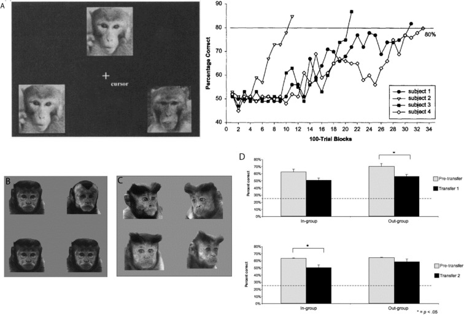

As a matter of fact, human adults who specifically lose this expertise following [brain damage](https://www.sciencedirect.com/topics/neuroscience/brain-injury), i.e. patients with prosopagnosia (Bodamer, 1947), are nevertheless also able to successfully learn specific images of individual faces (e.g., Caldara et al., 2005, Sergent and Signoret, 1992: 10 individuals with two images per individual, 100% performance after 2–3 h of training). These patients with prosopagnosia are also able to match identical images of faces with at least 80% performance (e.g., the first 6 items of the [Benton Facial Recognition Test](https://www.sciencedirect.com/topics/medicine-and-dentistry/benton-facial-recognition-test), BFRT, Benton & Van Allen, 1968; see Rossion & Michel, 2018), although they take significantly longer than typical individuals (e.g., Busigny, Joubert, Felician, Ceccaldi, & Rossion, 2010). In fact, many patients with prosopagnosia can also, albeit relatively slowly, match individual faces across head rotation changes well above chance level (e.g., Delvenne et al., 2004, Sergent and Signoret, 1992).

In typical human adults, natural (i.e., untrained) performance at unfamiliar face matching (with or without a brief delay between images) is excellent even across head orientation changes, a transformation preserving critical pigmentation cues (Laguesse et al., 2012, Rossion and Michel, 2018). In fact, it is only when having to find a single unfamiliar face across substantial changes of viewing conditions, in particular lighting direction variations, and among many similar unfamiliar distractors that individual face matching performance in humans drops to about 70–80%, i.e., a performance level that is sometimes defined as *low*”, “*highly inaccurate*” or even “*remarkably poor*” for human standards (e.g., Bruce et al., 1999, Hancock et al., 2000, Megreya and Burton, 2006, Megreya and Burton, 2008, Megreya et al., 2011, White et al., 2014, Young and Burton, 2018). However, with familiar faces, including faces that are briefly familiarized, performance is close to ceiling at the first attempt (Megreya & Burton, 2006). On the basis of their limited ability at much simpler tasks as described above and illustrated in Fig. 1, monkeys could not even be tested in such extremely challenging conditions as tested with humans in the latter studies: they would not be able to perform above chance level, even with unlimited time.

In sum, far from matching humans, monkeys required to individuate images of conspecific faces do not appear to perform better than other animal species, such as sheep (Kendrick, da Costa, Leigh, Hinton, & Peirce, 2001), wasps (Sheehan & Tibbetts, 2011) or fish (Wang & Takeuchi, 2017) similarly trained to recognize individual faces of conspecifics, or even to recognize individual human faces (e.g., bees, Dyer, Neumeyer, & Chittka, 2005; fish, Newport, Wallis, Reshitnyk, & Siebeck, 2016; sheep, Knolle, Goncalves, & Morton, 2017). They also perform well below human patients with prosopagnosia. The implication is that an intact set of specialized cortical face regions, or even a primate cortex, is not needed to accomplish these IFR tasks above chance level. In other words, successful performance at IFR after extensive training in monkeys (and other animal species) does not provide evidence that this species reaches a comparable level of expertise as humans and rely on comparable neurofunctional processes.

To avoid the issue of (over)training, a number of paradigms have been used in which macaque monkeys are required to habituate to a given unfamiliar face (i.e., the adapting stimulus). After looking at the adapting stimulus for a prolonged period of time, these studies report a viewing preference for a novel individual face over the adapting face, which is taken as evidence of successful IFR (Dahl et al., 2007, Dufour et al., 2006, Gothard et al., 2004, Gothard et al., 2009, Pascalis and Bachevalier, 1998, Sugita, 2008; see also Neiworth, Hassett, & Sylvester, 2007 in Tamarins). Unfortunately, IFR performance cannot be quantified with this paradigm, which simply reports a significant viewing preference (after adaptation). Moreover, although human adults can be tested in such tasks also (e.g., Pascalis et al., 2002, Scott et al., 2005), they may have no interest in spending more time looking at a novel or adapting stimulus in such habituation/novelty paradigms, which makes it difficult to obtain meaningful comparable datasets in humans to evaluate monkeys’ performance. Most importantly, although viewing preferences in such adaptation paradigms have generally been taken as evidence that monkeys are naturally able to individuate faces of conspecifics, these studies are confounded by repetition of the exact same images (Fig. 2). Hence, a significant viewing preference may reflect the recognition of an individual depicted in an image, or some other process such as the exogenous allocation of attention to low-level image cues. For example, when the exact same images are used to habituate and test monkeys’ preferential looking, the distractor images will be more novel irrespective of the individual they depict (i.e., both low-level image cues and a whole host of socially relevant signals such as head orientation or eye gaze direction can signal novelty; Fig. 2).

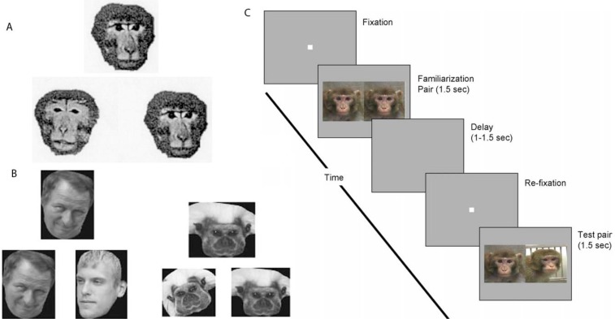

Fig. 2. Examples of images used in studies using the habituation/novelty paradigm to test monkeys’ [IFR](https://www.sciencedirect.com/topics/medicine-and-dentistry/facial-recognition) ability. A. Example of images from Pascalis and Bachevalier (1998), with the habituation stimulus on top, followed by the two images at the bottom. Viewing preference for the novel item may have nothing to do with face identity but can be based on obvious low-level image cues. Moreover, head orientation and gaze direction differ between the two faces. B. Example images used by Neiworth et al. (2007) to test Tamarin monkeys’ preference for novel human or Tamarin faces. In all cases, targets and distractors differ in terms of many cues beyond face identity. C. Example of an habituation/novelty trial used by Gothard et al. (2004), who showed longer eye gaze fixations on the novel face image presented after habituation. Again, many cues differ between these images, even outside of the faces displayed, seriously weakening claims in these studies that on the basis of a preferred response to a non-habituated stimulus, monkeys are able to perform IFR without training.

In summary, there is little empirical support for the claim that monkeys can naturally recognize individual faces of conspecifics, let alone approach human-like expertise at this function. Note that this conclusion arises even without considering speed of recognition, which is an important factor in human studies (i.e., to distinguish between typical observers and patients with prosopagnosia performing individual face matching tasks; e.g., Davidoff and Landis, 1990, Delvenne et al., 2004; see Rossion & Michel, 2018). It is also important to mention that studies showing rhesus monkeys’ ability to select familiar dominant monkeys based on face images only (Deaner, Khera, & Platt, 2005) do not provide solid evidence for their ability to actually recognize these individuals, since macaques can also extract such information from pictures of unfamiliar conspecifics (Micheletta et al., 2015, in crested macaques). More generally, many species have badges of status (i.e., reliable subsets of signals of quality that reveal information about an individual’s size and dominance) that can be readily decoded from the body, including the face. For instance, a species of wasps showing no evidence of IFR, *Polistes dominulus*, nevertheless relies on facial patterns to predict body size and social dominance (e.g., Tibbetts & Dale, 2004). In humans, signals of dominance can be readily extracted from the face of unfamiliar individuals (Todorov, Baron, & Oosterhof, 2008), and social judgments of faces that are correlated across people can be achieved even in the absence of a good ability to recognize individual faces (Quadflieg et al., 2012, Rezlescu et al., 2014, Todorov and Duchaine, 2008).

We suggest there are at least three reasons for which monkeys, in particular rhesus macaques, might find the tasks measuring IFR challenging. First, although the perceptual world of the rhesus monkey, like humans and many other primates, is dominated by vision, the human societies in which we live are characterized very differently from those formed by groups of rhesus monkeys. Rhesus monkeys’ society is generally comprised of a smaller number of individuals (a historical trend exaggerated in the conditions of monkeys raised in captivity and hosted in research laboratories), and they are organized around relative stable hierarchies based on relatedness to dominant females. Human society, on the other hand, is characterised by the presence of numerous individuals and fission–fusion dynamics, i.e., a tendency to change the number of individuals over time. Second, although human faces are extremely variable morphologically, even within a genetically homogenous group (Sheehan & Nachman, 2014), individual monkey faces, in particular those of macaques, may not necessarily vary substantially, and thus convey reliable (i.e., invariant) signals for identity. This could be because there is no need to individuate many individuals or because, unlike for humans (Sheehan & Nachman, 2014), there are other readily recognizable cues from the body shape or the voice that can be used to rapidly recognize the necessary limited number of individuals. Third, and more generally, although monkeys are diurnal – like us – and are closely related to humans from a [phylogenetic](https://www.sciencedirect.com/topics/neuroscience/phylogenetics) perspective (certainly more so than other mammals, including rodents), one cannot assume continuity across the primate order in all facets of visual cognition and cortical organization (Preuss, 2000). In fact, as discussed in the next section, the available evidence rather indicates that monkeys lack both the cognitive and neural specializations that support human IFR.

## 3. Cognitive specialization

A large body of scientific literature has concluded repeatedly that human recognition of individual exemplars differs qualitatively for faces and nonface stimuli (Farah et al., 1998, McKone et al., 2007; Rossion, 2008). In this section, we review studies that have investigated the same cognitive specializations in nonhuman primates.

### 3.1. Face inversion

In humans, there is a large drop of performance at individual face recognition tasks when pictures of faces are presented upside-down: this effect is typically about 20% in behavioral studies, and is much larger for faces than nonface objects (Yin, 1969). It has been replicated for 50 years across a wide variety of tasks (e.g., old/new recognition and matching tasks) and variables (accuracy rates or RTs) (for reviews, see Farah et al., 1998, Rossion, 2008, Rossion, 2009) and is arguably the strongest and most reliable effect found in the field of human face recognition. Strikingly, there is no evidence of such an inversion cost in macaques tested with conspecific faces in the same kinds of IFR tasks described in the previous section (Bruce, 1982, Bruce, 1982, Rosenfeld and Van Hoesen, 1979; see also Gothard et al., 2004, Phelps and Roberts, 1994, Wright and Roberts, 1996). Note that rhesus monkeys are perfectly able to detect the difference between an upright and inverted face image and, under unrestricted viewing conditions, they do prefer to look at upright than inverted images of faces (Adachi et al., 2009, Guo et al., 2003, Tomonaga, 1994). Importantly, rhesus monkeys do not have a prehensil tail, nor any specific adaptation for suspensory [behaviour](https://www.sciencedirect.com/topics/neuroscience/behavior-neuroscience) or arboreal locomotion such as brachiation. They live predominately on the ground, like humans; thus there is no particular reason to believe that they are exposed as often to inverted as upright faces.

It is important to note that investigation of the face inversion effect in macaque monkeys is often described as having yielded mixed results in the scientific literature (as reviewed in Dahl et al., 2013, Leopold and Rhodes, 2010). We argue that this ambiguity stems from three causes. First, while some studies consider an inversion effect in monkeys to be the mere preference for upright faces over inverted faces (Tomonaga, 1994), others relate it better performance for upright faces in a face/nonface detection task (Perrett, Mistlin, et al., 1988), or differences in eye movement exploration between upright and inverted faces (Dahl et al., 2009, Guo et al., 2003). However, none of these are dependent measures of *[individuation](https://www.sciencedirect.com/topics/medicine-and-dentistry/individualization)* *of* faces, the critical function at stake. Instead these outcomes point to a viewing preference for [visual stimuli](https://www.sciencedirect.com/topics/medicine-and-dentistry/visual-stimulation) presented in the cardinal (upright) orientation, better face categorization (i.e., face detection) when stimuli are upright compared to when they are turned upside down, or, finally, a reliable eye movement pattern for upright faces which could reflect an efficient strategy for extracting any number of socially relevant signals (e.g., expression, gender/attractiveness, gaze direction, health, kinship etc.). In sum, if these studies were testing human subjects, they would not meet the burden of proof required for making inferences about IFR.

The second cause of ambiguity in the literature concerns [operant conditioning](https://www.sciencedirect.com/topics/medicine-and-dentistry/instrumental-conditioning): some studies report a modest inversion effect in individuation tasks only after training monkeys extensively with upright faces, and then comparing performance for these *specific* stimuli at upright (trained) and inverted (untrained) orientations (Overman and Doty, 1982, Vermeire and Hamilton, 1998). Because this design confuses the face inversion effect with general learning biases, it is generally acknowledged that these studies do not provide evidence of a behavioral face inversion effect in monkeys (Bruce, 1982, Dahl et al., 2013, Vermeire and Hamilton, 1998).

A third source of ambiguity is the nature of matching tasks used. A number of studies have reported significant face inversion effects in two-alternative forced-choice tasks requiring a subject to discriminate between two face stimuli (Fig. 1; Parr, 2011, Parr et al., 1999, Parr et al., 2000, Parr et al., 2008, Parr and Heintz, 2008). In these tasks, a picture is presented to the monkeys during the initial encoding phase (the “sample”) and is followed by a “match-distractor stimulus pair” (i.e., one picture would be the correct match and the other the incorrect distractor). The potential problem with these tasks is that in the inverted conditions, the picture-plane orientation of the sample and the match-distractor pair differs by 180 degrees, whereas in the upright condition, all three stimuli are presented at the same orientation. As others have put it (Dahl et al., 2013), this paradigm (which is not used in human studies) therefore measures a “face rotation effect” rather than a “face inversion effect”. Hence, unsurprisingly, in these studies, “rotation effects” are found for other stimuli tested in monkeys, such as human and chimpanzee faces or pictures of automobiles (Parr et al., 1999), with no evidence of a larger effect for conspecific faces. Based on this lack of specificity and other findings, Parr et al. (2008) in fact concluded that rhesus monkeys lack human-like expertise for faces. The same limitation applies to studies measuring a “face rotation effect” in a habituation/novelty paradigm (*rhesus monkeys,* Gothard, et al., 2009; *Tamarins,* Neiworth et al., 2007, Fig. 2B).

In summary, although monkeys perceive the difference between upright and inverted faces, have a clear preference for upright faces, and are typically exposed to many more upright than upside-down faces in typical living conditions, as well as in experiments, they do not present with an advantage at *individuating* conspecific faces at upright over inverted orientations. This observation represents a striking difference with human performance in terms of the cognitive specializations thought to govern IFR (Rossion, 2008).

### 3.2. The composite face effect

In humans, the composite face effect has been used as an index of mandatory integration of facial parts into a unified representation of the individual face (“holistic face perception”; Young, Hellawell, & Hay, 1987; see Murphy et al., 2017, Rossion, 2013 for reviews). This effect is based primarily on a visual illusion: identical top halves of (unfamiliar) faces are perceived as being different when they are aligned with different bottom halves; this illusion disappearing when the two halves are misaligned, or when the faces are presented upside-down (Fig. 3). This composite face illusion shows that an individual face part (here the top half) cannot be perceived independently of the other parts (here the bottom half), as if the face processing system automatically fused the face parts into a single percept. Based on this illusion, many behavioral studies have designed matching paradigms in which human observers make mistakes and/or show prolonged responses times (RTs) at matching identical top halves of unfamiliar faces associated with different bottom halves. This effect is generally strong and reliable, although many versions of this paradigm in terms of stimuli and parameters have been used and can also lead to spurious effects (or absence of effects, see Rossion, 2013 for an extensive and critical review of the composite face effect).

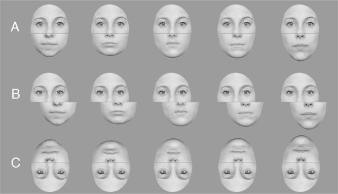

Fig. 3. The composite face illusion (adapted from Rossion, 2013). A. All 5 top halves (above the thin line) are physically identical. Yet, when they are aligned with distinct bottom halves (all of different identities, neutral expression, taken under the same lighting conditions), they are perceived as being different. B. If the bottom halves differ but are spatially misaligned with the top halves, one has no difficulties in perceiving the top face halves as being indeed identical. C. Same as in A but the display has been vertically flipped, showing inverted faces. All 5 “top” halves (here at the bottom of the display below the thin line) are physically identical and one does not see them as being different.

Taubert and Parr (2009) compared the performance of rhesus monkeys and spider monkeys (a New World primate species where members form societies governed by fission–fusion dynamics) in a matching task involving composite face stimuli. Both species were initially trained to attend only to the top half of the sample stimulus using face-like shapes. This was a lengthy process with a small number of stimuli and the inferences drawn from this study depend on the assumption that the subjects could generalize from round shapes to real [photographs](https://www.sciencedirect.com/topics/medicine-and-dentistry/photograph) of faces. Nonetheless the authors found differences in the response profile of both species, with evidence of a composite effect emerging independently of visual expertise. For example, rhesus monkeys only exhibited a composite effect for gorilla faces.

In Taubert, Qureshi, and Parr (2012), the authors were careful not to train rhesus monkeys with test stimuli and to measure a control condition where the exogenous bottom halves of the faces were not presented. They found a small composite effect for rhesus macaques driven by only 4 of the 6 subjects in the sample. In both papers the smaller effect sizes and the greater inter-subject differences for rhesus macaques as compared to humans was explained by differences in social structure and cognitive specializations (Taubert et al., 2012, Taubert and Parr, 2009).

Dahl et al. (2007) claimed to have overcome the limitations of trained effect tasks, instead using a “rebound” habituation effect as a proxy for the composite face effect in rhesus monkeys. The design was reasonably straightforward; when a stimulus is repeated, exchanging the bottom half of a face produced less rebound (in terms of eye movement exploration) in the misaligned condition then in the corresponding aligned condition. This result was interpreted as reflecting the perception of a novel identity in the top half of the face in the aligned condition (which is largely consistent with the theory behind the composite face effect in humans, see Rossion, 2013, and with evidence of such decreases in habituation in composite face tasks used in fMRI or EEG; Jacques and Rossion, 2009, Schiltz and Rossion, 2006, respectively). Unfortunately, unless one relies on gaze-contingent constraints for instance (Van Belle, de Graef, Verfaillie, Busigny, & Rossion, 2010), eye movement exploration is not well-suited to capture holistic (i.e., un-dissociable in parts) encoding of an individual face in composite face paradigms (e.g., no difference in eye gaze fixations between aligned and misaligned faces; De Heering, Rossion, Turati, & Simion, 2008).

Moreover, Dahl et al. (2007)’s finding suffers from a major shortcoming: in their study, the misaligned stimuli were not centered on the upper part of the monkey faces. That is, the critical region to compare between aligned and misaligned conditions (upper part) was not located at the same position on the images, being left lateralized relative to the centre in the misaligned trials only. Hence, if monkeys in that study looked more on the centre of the overall stimulus, there made fewer fixations on the eyes, independently of perceiving a novel face, for misaligned trials. Supporting this interpretation, the authors found a main effect of misalignment already in adaptation trials, where both top parts of the faces were novel. Importantly, there was no control condition to exclude a general effect of “misalignment”. Since monkeys would have been trained to fixate on a screen (usually centrally) and, further, they are used to stimuli (and objects in the natural environment) being whole and not disassembled, “less rebound” in misaligned trials could easily reflect a neophobic response to a strange stimulus or a reluctance to explore [facial features](https://www.sciencedirect.com/topics/medicine-and-dentistry/facies) displaced from the centre of the screen.

In sum, studies of the composite effect are in line with the lack of inversion effect in monkeys and do not provide further evidence that this species perceive individual faces holistically, a key process behind human expertise at individual face recognition.

### 3.3. Lack of advantage in matching familiar as compared to unfamiliar faces

Another clear index thought to characterize face individuation in humans is the strong advantage found for pictures of familiar over unfamiliar individuals. This advantage has been found not only in old/new recognition tasks (e.g., Bruce, 1982) but also in individual face matching tasks, in particular when the pictures to match vary in head orientation and/or lighting direction (e.g., Burton et al., 1999, Bruce et al., 2001, Megreya and Burton, 2006). Although (untrained) human performance at unfamiliar face matching tasks even in extremely difficult conditions is usually very good (e.g., 70–80% accuracy in 1/10 matching tasks with different target images, similar distractors, and catch trials with absent targets, Megreya & Burton, 2006) some authors have even claimed, on the basis of the advantage found for familiar faces, that human expertise at IFR would concern only familiar faces (Young & Burton, 2018; but see Rossion, 2018, Rossion et al., 2018).

Strikingly, the only study – to our knowledge – that compared familiar and unfamiliar face matching in macaques failed to find any advantage for familiar faces (Micheletta et al., 2015). In that study, three monkeys performed a 2AFC task requiring to match simultaneously presented different images of the same target face against a distractor individual face. The monkeys, who had been extensively trained at the task with other stimuli including identical images of faces, reached only a correct level of performance overall for such task (about 75%). However, there was no advantage for pictures of highly familiar as compared to unfamiliar individuals. The species tested was crested macaques, who are phylogenetically closely related to rhesus macaques but are considered as more socially tolerant (Duboscq et al., 2013).

Studies in Capuchin monkeys, a species of new world monkey which is also referred to by monkey physiologists as providing evidence that primates, in general, are uniquely adept at extracting information from faces, including identity (e.g., Meyers et al., 2015), have provided mixed results on this issue. In the first study of Capuchin monkeys that explicitly tested this hypothesis, the individual face matching task was performed even slightly better when the conspecifics face stimuli were unfamiliar (i.e., monkeys raised separately from the tested subjects) than when they were familiar (i.e., monkeys raised in the same group for many years; Pokorny and de Waal, 2009a; Fig. 1B). In a more recent study, performance did not differ either between in-group and out-group faces in a 4AFC simultaneous face matching task (Talbot et al., 2016). However, monkeys were visually familiar with the out-group individuals, and performance for these two groups of faces was better than for a completely unfamiliar set of faces. Although the authors took these findings as evidence of a familiarity effect in individual face matching in Capuchins, in the absence of a cross-over interaction between the subjects tested and the stimulus sets, this difference in performance easily be due to physical differences in stimulus sets (i.e., a larger physical homogeneity between the unfamiliar face pictures). Moreover, in that study, despite having been extensively trained at the task with clip arts and identical face images, Capuchins took more than 10,000 trials on average to perform the 4AFC across head orientation changes significantly above chance level, reaching only modest levels of performance overall (i.e., about 45% for familiar faces; see Talbot et al., 2016).

Hence, overall, while performance at matching different pictures of a given individual is superior for familiar than unfamiliar face identities in humans, there is no behavioral evidence for such effect in monkeys. This is not to say that monkeys, or other animal species, cannot recognize a few highly familiar individuals from their face, even on a still picture. In fact, several studies have shown that monkeys are able to do that, and even spontaneously associate these pictures to voice-identity information or affective responses (e.g., Sliwa, Duhamel, Pascalis, & Wirth, 2011: 3 highly familiar individual faces; Landi & Freiwald, 2017: 3 highly familiar individual faces, both studies in rhesus monkeys; Pokorny & de Waal, 2009b: 8–9 highly familiar individuals in Capuchins). In the study of Micheletta et al. (2015) with crested macaques (4 highly familiar individual faces), although matching performance was not influenced by familiarity, the monkeys were differentially influenced by the dominance status of the individual for familiar and unfamiliar faces, indicating that they recognized the few familiar faces. However, monkeys’ ability to recognize a few highly familiar individuals with well-known hierarchical relationships from their face alone does not imply reliance on a human-like expert system to readily extract the idiosyncratic configuration of numerous individual faces, and a dedicated neural circuitry for this expert individual face recognition function as in humans (see Section 4).

### 3.4. Conclusions: monkeys differ quantitatively and qualitatively from humans at individual face recognition behavior

To summarize this section, there is no evidence that macaque monkeys, or other monkey species, are naturally able to individuate various conspecifics based on their faces, let alone to come close to humans in terms of level of performance (i.e., level of expertise) at this function. There is no evidence either that monkeys rely on qualitatively similar [cognitive processes](https://www.sciencedirect.com/topics/neuroscience/cognitive-process) as humans, showing no inversion or typical composite face effects, and exhibiting no advantage at matching pictures of familiar over unfamiliar individuals. In fact, across a number of behavioural studies, there is evidence to the contrary: monkeys trained to individuate pictures of faces appear to rely merely on image-based cues (see Martin-Malivel, Mangini, Fagot, & Biederman, 2006 for direct evidence in the Guinea baboon, another Old World monkey). Hence, their performance vary considerably across trials (see Micheletta et al., 2015 for instance), generally drops when new images are introduced in a design, and is particularly poor when matching across changes in image format (i.e., invariance) is required. When transfer occurs, it is only for a few items and it could easily be accounted for by low-level cues that are preserved despite inversion (Bruce, 1982, Rosenfeld and Van Hoesen, 1979), scrambling or removal of internal features (e.g., experiment 2 in Parr et al., 2008). Monkey behavioural studies that do not rely on training and explicit IFR tasks but rather on visual habituation paradigms typically use identical images to compare distractors varying on many low-level cues but also and high-level cues non-identity cues such as eye gaze-direction (Fig. 2), showing some evidence of image discrimination at best, but not face discrimination based on identity signals.

In other studies, rhesus macaques did not respond preferentially to average faces (i.e., composites of different faces; Tomeo, Ungerleider, & Liu, 2017) nor were they able to match average faces (i.e., composites of multiple photographs taken of the same individual) more effectively to single instances (Taubert, Wardle, Flessert, Leopold, & Ungerleider, 2017). These latter studies indicate that averaging faces together does not yield the same behavioural advantage for monkeys as it does for humans. This might indicate a general resistance of monkeys’ face processing system to process stimuli that fall into “uncanny valley”. Alternatively, it might indicate a significant difference in how rhesus macaques encode morphological similarity among conspecific faces. Indeed this was the main conclusion of Parr, Taubert, Little, and Hancock (2012) who attempted to investigate perceptual distinctiveness among macaque monkeys faces.

Similarly to studies performed in human infants and children, it could be argued that the burden of proof should be systematically lowered for people working with monkeys in a comparative context because it is difficult to collect behavioural data from nonhuman subjects without severely changing the methodology used in studies of (adult) [human behaviour](https://www.sciencedirect.com/topics/neuroscience/human-behavior). For instance, we might forgive a failure to replicate because, unlike human subjects, monkeys cannot be verbally instructed. We do not deny that verbal communication plays a large role in behavioural measures of human performance, and that comparing performance at explicit behavioral tasks – which reflect the outcome of many sensory, cognitive and motor processes - across species or human populations is challenging. Nevertheless, it is worth noting that members of an ape species, namely common chimpanzees, have often performed more comparably to humans at behavioural face individuation tasks (Parr, 2011, Parr et al., 2011, Parr et al., 2012, Taubert et al., 2012, Taubert et al., 2012, Taubert et al., 2017, Weldon et al., 2013; also Taubert and Parr, 2009 for a comparison between Old and New World monkeys; and Talbot, Mayo, Stoinski, and Brosnan (2015) for a study in orang-utans). These direct comparisons across nonhuman primate species indicate that it is not the lack of verbal instruction that leads to rhesus macaques systematically “failing” researcher expectations. Instead, these studies point to cognitive discontinuities across the primate order, perhaps driven by qualitative and quantitative differences in social demands.

## 4. Neural specializations

If macaques do not possess a human-like ability to individually recognize faces, why would they have a complex network of cortical face-selective areas as identified with fMRI (Tsao, Moeller, & Freiwald, 2008)? For a start, we note that the mere presence of face-selective regions, or face-selective populations of neurons, does not imply that they support an IFR function. For instance, a face-selective cortical network as extended as in macaques has also been found in marmosets (Hung, Yen, Ciuchta, Papoti, & Bock, 2015), a new world species of monkeys with a smaller and more primitive brain than macaques (Fleagle, 1999), for which there is no evidence of behavioral IFR ability. Also, a face-selective area has been identified in the temporal cortex of dogs (Dilks et al., 2015), despite no evidence that dogs rely on faces to recognize other individual dogs. In the same vein, groups of face-selective neurons have been found in the temporal cortex of sheep (Kendrick & Baldwin, 1987), a species with no evidence of large interindividual morphological variability in the face, natural ability, and social requirement to individuate conspecifics<sup>1</sup>.

### 4.1. The cortical face network in the monkey STS

Coming back to the macaque brain, their network of brain regions responding selectively to faces in fMRI is found along the superior temporal sulcus (STS), where face-selective-cells have systematically been recorded since the seminal study of Gross, et al. (1972). In some studies, up to six face-selective regions have been reported, in the posterior, middle and anterior sections of the [STS](https://www.sciencedirect.com/topics/neuroscience/superior-temporal-sulcus), occupying space in the fundus, or the lower bank of the sulcus, close to its lateral tip (Fig. 4; Tsao et al., 2008). These regions have been named according to their localization within the STS, with e.g., the ML region being located in the *Lower* bank of the *Middle* section of the STS, while MF is located in the *Fundus* of the *Middle* STS (Fig. 4).

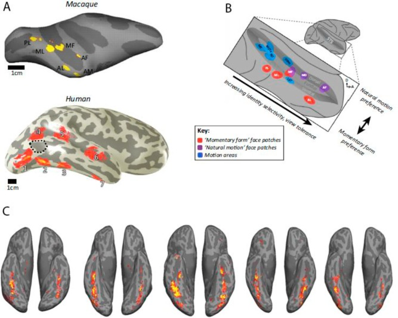

### 4.2. A lack of ventral cortical face network in the monkey brain

Importantly, unlike in the human brain, face-selective regions have not been found in the *ventral* occipito-temporal cortex of the monkey: even the most anterior face region, labelled AM, is found outside of the STS and located on the lateral surface of the anterior temporal lobe (Fig. 4). Note that this difference alone does not imply that there is no homologous relationship between human and monkey cortical face networks. For instance, while human primary [visual cortex](https://www.sciencedirect.com/topics/neuroscience/visual-cortex) is essentially located medially around the [calcarine sulcus](https://www.sciencedirect.com/topics/medicine-and-dentistry/calcarine-sulcus), macaque’s primary visual cortex, V1, extends much more laterally than human V1 (Schira, Tyler, & Rosa, 2012) and monkey’s ventral visual stream is thought to run on the lateral occipito-temporal cortex surface. However, V1 is also relatively (i.e., compared to other visual areas and the entire brain) much larger in macaques than humans (10% of the total cortical surface *vs.* 3%, respectively; Van Essen, 2005). In contrast, the temporal lobe is much smaller and thinner in macaques than humans, even accounting for body size differences (Rilling & Seligman, 2002; Fig. 5). Beyond size, they are also major differences in gyrification between the brains of macaques and humans (Zilles, Palomero-Gallagher, & Amunts, 2013). In humans, the ventral occipito-temporal surface is divided by two major sulci, the [collateral sulcus](https://www.sciencedirect.com/topics/medicine-and-dentistry/collateral-sulcus) (CS) more medially, and the occipito-temporal sulcus (OTS) more laterally, these two sulci defining the borders of the fusiform gyrus, the most important structure for IFR (Barton, 2008, Meadows, 1974, Rossion, 2014, Rossion, 2014). In contrast, monkeys possess only one main ventral sulcus, labelled as the OTS, therefore lacking a fusiform gyrus among other substantial neuroanatomical differences with the human VOTC (Fig. 5).

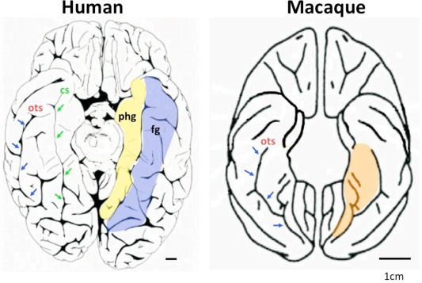

Fig. 5. The inferior surface of the brain in man and macaques, with the cerebellum removed. In the human brain, the occipito-temporal sulcus (ots) is labelled with blue (dark) arrows and the [collateral sulcus](https://www.sciencedirect.com/topics/medicine-and-dentistry/collateral-sulcus) (cs) with green (light) arrows. The human brain has two major gyri on its ventral surface while the macaque has only one (a minor sulcus, the mid-fusiform sulcus, separating the [fusiform gyrus](https://www.sciencedirect.com/topics/neuroscience/fusiform-gyrus) in its lateral and medial sections, has also been identified in the human brain, see Weiner et al., 2014). The fusiform gyrus (fg; blue area) lies between the ots and cs. The [parahippocampal gyrus](https://www.sciencedirect.com/topics/neuroscience/parahippocampal-gyrus) (phg; yellow region) lies medial to the cs. Based on anatomy, it is unclear whether the macaque gyrus best corresponds to the fg or phg, but contrary to humans, no face-selective activation is found in these regions of the monkey brain, while the monkey OTS and phg show selective responses to visual scenes, as the human phg and cs. The scale bar denotes 1 cm. (For interpretation of the references to color in this figure legend, the reader is referred to the web version of this article.)

In addition to a ventral network of face-selective areas, the human brain also holds a network of face-selective regions along the STS (Duchaine and Yovel, 2015, Haxby et al., 2000; Fig. 4). This STS network in humans does not seem to contribute significantly to IFR (e.g., there are no known cases of prosopagnosia following selective STS damage in humans). Rather, STS face-selective regions appear to be involved the coding of dynamic (i.e., rapidly changing) aspects of faces such as eye gaze direction, head orientation and facial expressions (Allison et al., 2000, Bernstein and Yovel, 2015, Carlin et al., 2011, Hoffman and Haxby, 2000, Pitcher et al., 2011, Pitcher et al., 2014, Winston et al., 2004).

These anatomico-functional differences between species, together with the lack of human-like ability at IFR in macaque monkeys as reviewed in previous sections, raise the intriguing possibility that the ventral face-selective recognition system – which is found essentially all along the fusiform gyrus and adjacent sulci (Fig. 4) - emerged relatively recently in evolution, and may even be so extensively developed specifically in the human species or its closest cousins (see e.g., Parr and Heintz, 2009, Chance et al., 2013 for neural studies relevant to face processing in chimpanzees).

### 4.3. A ventral shift of the STS face-selective network in the monkey brain?

Despite these obvious differences between species in cortical organization of face-selective networks, some authors consider that the STS cortical face network in the monkey brain is divided into two parts: (1) a dorsal part, which would be homologous to the face-selective STS network in humans, and (2) a ventral part, which would correspond to the face-selective VOTC network in humans (Freiwald et al., 2016, Lafer-Sousa et al., 2016, Tsao et al., 2008, Weiner and Grill-Spector, 2015, Yovel and Freiwald, 2013; Fig. 4B). According to this view, the putative ventral part of the monkey STS system would have been pushed onto the ventral surface of the brain over the course of human evolution by the expansion of regions engaged in language and [social cognition](https://www.sciencedirect.com/topics/neuroscience/social-cognition), in particular the temporal parietal junction (see fig. 9 in Lafer-Sousa et al., 2016 for instance). In monkeys, then, the more dorsal network would be involved in representing dynamic aspects of faces, such as facial expressions or eye gaze direction, and this putative “ventral” network would be involved in processing face identity (Fig. 4B; Fisher & Freiwald, 2015). Thus, these monkey STS regions are not only argued by some to constitute a precursor system in non-human primates of the human ventral cortical face network, but also to be homologous one-by-one to the face-selective regions found in the human brain (Tsao et al., 2008).

Establishing neuroanatomical homologies between two species which shared a common ancestor 25 million years ago (Kumar & Hedges, 1998) and differ considerably in brain size and gyrification (Zilles et al., 2013) is of course extremely difficult, and one must remain very careful in making strong statements on this issue. However, the arguments advanced in favour of this homology between a “ventral” face-selective STS system in the monkey brain and the face-selective VOTC human network are certainly not compelling, for a number of reasons.

First, according to the authors favouring this inter-species homology, the number of posterior face-selective regions identified with fMRI would be the same across species, i.e., 6 in each hemisphere, and these regions would be organized according to the same processing hierarchy (Tsao et al., 2008; see Fig. 1, Fig. 2 in that publication; Freiwald et al., 2016, Yovel and Freiwald, 2013). Under this view, the face-selective region known as ML in the monkey STS would correspond to the human mid-fusiform gyrus (“FFA”) for instance. However, the numbers do not add up because the region known as PL would then correspond to a face-selective region in the human inferior occipital gyrus (the “occipital face area”, OFA, Freiwald et al., 2016; Fig. 4) rather than to the human posterior STS, which would therefore not have any corresponding area in the monkey brain. Another example is that, in comparison to the single ML cluster in the monkey STS which would be part of the monkey “ventral” system, the human fusiform gyrus holds several sub-regions, for instance labelled FFA1 and FFA2 (or PFus and mFus) in a number of studies (Grill-Spector et al., 2017, Weiner and Grill-Spector, 2013; see Fig. 4A and C). In general then, the claim of one-to-one homology is based on both a systematic *over*estimation of the number of independent face-selective regions in the monkey brain, which vary in reality between two and six (Bell et al., 2009, Nasr et al., 2011, Pinsk et al., 2005, Pinsk et al., 2009, Rajimehr et al., 2009, Rajimehr et al., 2009, Tsao et al., 2003), together with an *under*estimation of the number of these regions in the human brain.

In short, since the number of face-selective regions remains unknown in both species, in particular varying largely across paradigms and individual human brains in fMRI paradigms (Rossion et al., 2012, Gao et al., 2018, Zhen et al., 2015; Fig. 4C), attempts to directly relate these functional regions one-by-one across species (Freiwald et al., 2016, Tsao et al., 2008, Yovel and Freiwald, 2013) and constrain human functional face processing models by monkey data (Duchaine and Yovel, 2015, Freiwald et al., 2016) in the absence of objective criteria appear premature and misleading.

Other arguments advanced to support the idea of homology between the face-selective VOTC regions in humans and a putative ventral STS face-selective system in monkeys are based on the positioning of the monkey network with respect to other functional regions. For example, whereas the STS face regions in humans are situated dorsally above MT, STS face regions in macaques (and marmosets) are ventral to the middle temporal area responding selectively to motion (MT/V5), potentially supporting the view of a ventral shift of these areas during evolution (Weiner & Grill-Spector, 2015). However, this ventral location with respect to MT in the monkey brain is valid for the *whole* network, not just the putative “ventral” section of this network. Similarly, based on the finding of neighbouring regions coding for places, color and faces, some authors (Lafer-Sousa et al., 2016) have also argued in favour of a ventral displacement “*en bloc”* of these networks during human evolution. However, this far-fetched story does not align with the fact that the so-called [parahippocampal place area](https://www.sciencedirect.com/topics/medicine-and-dentistry/parahippocampal-place-area) (PPA) lying next to the FFA in the human VOTC (Epstein & Kanwisher, 1998) is not found laterally but also ventrally in the monkey brain, at a similar location as in the human brain (Kornblith, Cheng, Ohayon, & Tsao, 2013). Hence, there is a large cortical space in the monkey brain between this region and the face-selective areas.

To summarize, at present, there is little objective evidence supporting a similarity in the gross topological structure into two parallel streams, a dorsal and a ventral face-selective network, in the two species. Rather, the most parsimonious account of current neuroimaging datasets is that *monkeys do not have a human-like ventral face-selective network*. In this context, it is worth reminding the reader of the origin of this putative [functional dissociation](https://www.sciencedirect.com/topics/neuroscience/functional-dissociation) between a ventral and dorsal STS network in the macaque brain. This view originates from the observation that neurons in the upper bank of the STS fire relatively more to variations of facial expressions, while neurons in the lower bank of the STS fire more for differences between individual faces (Hasselmo, Rolls, Baylis, & Nalwa, 1989). However, the claim made in that original study was based on a small number of neurons recorded, and has been openly criticized on methodological grounds (Tiberghien, Baudouin, Guillaume, & Montoute, 2003). Moreover, face-selective patches have not been found in the upper bank of the STS in fMRI, but rather in the fundus, i.e., the regions labelled MF and AF (Fig. 4). Interestingly, both detailed anatomical connections determined by injected retrograde [tracers](https://www.sciencedirect.com/topics/medicine-and-dentistry/radioactive-tracer) (Grimaldi, Saleem, & Tsao, 2016) and electrical microstimulation combined with simultaneous fMRI (Moeller et al., 2008, Premereur et al., 2016) show that the regions of the network are strongly and specifically connected to each other, arguing against a dorsal–ventral dissociation. As a matter of fact, ML and MF are often considered to form a single cluster in fMRI (Nasr et al., 2011, Rajimehr et al., 2014, Rajimehr et al., 2009) but also in monkey physiology studies. For instance, studies measuring response properties of single neurons – in particular to decode face identity – conflate responses in ML and MF (e.g., Chang and Tsao, 2017), against any “ventral”-dorsal STS functional dissociation in the monkey brain (see also the recent study of Landi & Freiwald, 2017 in which, if anything, lower effects of familiarity with 3 individuals were found in the “ventral” face-selective regions of the network than in the “dorsal” regions, Fig. 3 of that study).

### 4.4. Right hemispheric specialization

Another important issue concerns hemispheric lateralization. In humans, cortical face-selective regions are typically larger in size or level of activation in the right as compared to the left hemisphere (e.g., Gao et al., 2018, Rossion et al., 2012, Sergent et al., 1992, Zhen et al., 2015; Fig. 4C). As mentioned at the beginning of the review, this right hemispheric lateralization in humans is critical for IFR: damage to or transient inactivation of the right but not the left VOTC leads to selective impairments at individual face recognition (e.g., Ambrus et al., 2017, Barton, 2008, Busigny et al., 2010, Jonas et al., 2012, Jonas et al., 2014, Pitcher et al., 2007, Riddoch et al., 2008, Sergent and Signoret, 1992). Although this right [hemispheric specialization](https://www.sciencedirect.com/topics/neuroscience/hemispheric-specialization) for faces is partly related to manual preference (Bukowski, Dricot, Hanseeuw, & Rossion, 2013), it is present already at a few months of age (de Heering & Rossion, 2015), preceding visual language specialization in the left VOTC (the Visual Word Form Area, VWFA, Cohen et al., 2002) during reading acquisition (Dehaene-Lambertz et al., 2018, Lochy et al., in press). Combined with the strictly bilateral cortical face network observed in monkey fMRI (e.g., Tsao et al., 2008), this suggests that this critical right lateralization of the face-selective VOTC may have developed at least partly independently of language lateralization, in order to support the required expertise level at IFR in the human species.

### 4.5. A cortical face network for dynamic social face cues

If monkeys are not experts at IFR, what could then be the function of their cortical face network? One account that considers both spatial localization and function of these regions is that the entire face-selective network in the monkey brain rather relates to functions supported by face-selective regions in the human STS (Fig. 4), i.e. the coding of dynamic (i.e., rapidly changing) aspects of faces such as eye gaze direction, head orientation and facial expressions (Allison et al., 2000, Bernstein and Yovel, 2015, Carlin et al., 2011; Hoffman & Haxby; Pitcher et al., 2011, Pitcher et al., 2014, Winston et al., 2004). In monkeys, the role of these regions at a systemic level of organization remains largely unknown, but must be related to monkey’s behavioural ecology in processing face signals. For instance, monkeys rely on faces to extract eye gaze direction and head orientation (Emery, Lorincz, Perrett, Oram, & Baker, 1997), as well as changes in facial expressions (Parr & Heintz, 2009) and their interactions (Goossens, Dekleva, Reader, Sterck, & Bolhuis, 2008), and it is likely that, as in humans, their STS cortical face network supports these functions first and foremost (e.g., Perrett, Smith, Potter, Mistlin, & Head, 1985).

Supporting this view, removal of the entire macaque STS, including its lower bank, impairs the coding of eye gaze direction but has only little and unspecific effects on the animals’ learned ability to discriminate pictures of individual faces (Heywood & Cowey, 1992). In other words, monkeys do not present with a condition similar to human prosopagnosia. Note that the functions of the monkey and human STS face-selective networks are certainly not analogous, and it is conceivable that the monkey brain – which has also considerably evolved from the common ancestor with humans 25 million year ago (Fleagle, 1999, Martin, 1990) – possesses a relatively more extensive STS network because this species may surpass humans in such face-related perceptual functions (e.g., coding for eye gaze direction without staring at an individual’s face).

### 4.6. Summary

In summary, in line with their lack of human-like cognitive specializations, macaques appear devoid of a ventral (right lateralized) cortical face network, which is critical for IFR in the human species. Attempts to relate portions of the monkey STS cortical face network to the human ventral face network is not based on solid scientific arguments and may lead the scientific field in the wrong direction by searching for the cellular basis of individual face recognition in functional areas of the monkey brain (e.g., ML) that do not support this function in their natural environment.

In this context, it is unfortunate that despite the availability of monkey fMRI for more than 15 years, researchers have not tested functional homologies between monkey and human cortical regions at the system level of cortical organization, in particular using many individual faces and fMRI-adaptation, a technique which has been successfully used in humans to show sensitivity to individual faces in the VOTC (Davies-Thompson et al., 2009, Gauthier et al., 2000, Gentile and Rossion, 2014, Grill-Spector and Malach, 2001), in particular using holistic representations (Schiltz and Rossion, 2006, Schiltz et al., 2010). This absence of comparative functional relationships related to [individuation](https://www.sciencedirect.com/topics/medicine-and-dentistry/individualization) of faces with fMRI, a technique available in the two species, is a major weakness in the search for functional homologies, which should rely on such comparisons (Passingham, 2009, Orban et al., 2004). In addition, robust and objective measures of rapid sensitivity to (unfamiliar) individual faces have been developed in human elecroencephalography (EEG) research by using fast periodic [visual stimulation](https://www.sciencedirect.com/topics/medicine-and-dentistry/visual-stimulation) (Rossion, 2014, Rossion, 2014, Rossion and Boremanse, 2011). These measures of the function at a system level of organization are largely free of low-level image confounds, being robust to size variations (Dzhelyova and Rossion, 2014a, Dzhelyova and Rossion, 2014b). Moreover, they are largely and specifically reduced by inversion and contrast-reversal of images, as well as [in patients](https://www.sciencedirect.com/topics/medicine-and-dentistry/inpatient) with impaired IFR following [brain damage](https://www.sciencedirect.com/topics/neuroscience/brain-injury) (Liu-Shuang et al., 2014, Liu-Shuang et al., 2016) and intracerebral stimulation (Jonas et al., 2012, Jonas et al., 2015, Jonas et al., 2014). Since EEG recordings can be performed over the monkey brain (e.g., Peissig, Singer, Kawasaki, & Sheinberg, 2007), such paradigms could be readily applied to test for monkeys’ high-level sensitivity to rapid invariant individuation of faces at a system level of organization, without having to train the animals in explicit behavioural tasks. Given the evidence reviewed above, we argue that these studies are unlikely to lead to robust and human comparable measures of sensitivity to individual faces in monkeys.

## 5. Neuronal codes of facial identity in the monkey brain?

If macaques lack human expertise at individual face recognition and the ventral cortical face network necessary to support it, why then do face-selective neurons in the monkey brain respond differently to pictures of different individual faces of conspecifics (Baylis et al., 1985, Perrett et al., 1984, Rolls, 1984, Rolls, 1992) or even of human faces (Chang and Tsao, 2017, Leopold et al., 2006, Tsao et al., 2006, Young and Yamane, 1992)? And why, from these different responses, seemingly intelligible neuronal codes of face “identity” can be derived? Clarifying these issues has implications for both our understanding of the neural basis of human IFR, and more generally for the interpretation of neural pattern decoding analyses, especially from populations of single neurons.

In our view, there are only a few criteria that must be met to derive a neuronal code based on single neurons’ responses allowing discrimination of different images: (1) a significant *response* from the neurons sampled; (2) *variability* of this response, i.e., spike rates, across the elements sampled, i.e., the individual neurons here; (3) some degree of *consistency* or *reliability*, such that presenting the same face image twice elicits a pattern of response across the population of neurons that is more similar than for two different images. Criterion 1 is easy to meet: in the monkey retina, [lateral geniculate nucleus](https://www.sciencedirect.com/topics/neuroscience/lateral-geniculate-nucleus) (LGN) or primary visual cortex, cells fire in response to various images of faces, and it can be assumed that a large fraction of neurons in higher-order areas of the monkey visual cortex also fire to various images. In fact, visually responsive neurons do not even have to be defined as face-selective to derive a population code (e.g., Young & Yamane, 1992).

This second criterion is also easy to meet: even in the primary visual cortex of the monkey brain, different cells will respond differently to different images, such as those presented in these studies, which vary substantially in local contrast and in simple variation positions of the hairline for instance, where there is maximal contrast (see e.g., Fig. 1 in Young & Yamane, 1992; Fig. 1, Fig. 3 in Chang & Tsao, 2017; and also the widely variable images used in the studies of Rolls, 1984, Baylis et al., 1985). The fact that face-responsive or face-selective IT neurons vary in their responses may also be due to their sensitivity to local contrast information. However, in the absence of stringent tests for invariance, successful decoding of differences in combinations of features, even across whole face images, is not evidence of a coding of face identity, since it could merely be due to a summation of low-level image statistics picked up on the whole images.

This leads to the third criterion for successful decoding: consistency of response for repeated trials, or reliability. What is needed for reliability? If images fall exactly in the same position on the retina from trial to trial, and between physically similar images, consistency, and thus successful decoding, could probably be achieved already at that level, certainly in the primary visual cortex. Hence, it is not impossible that a successful code of “face identity” – perhaps of a different nature – could be obtained by sampling V1 populations of neurons in the monkey brain. However, given the small receptive fields of V1 neurons, this code would not resist substantial changes of stimulus size (a simple manipulation which is nevertheless untested in these studies). In contrast, neurons in higher visual areas of the monkey brain such as IT have larger receptive fields, so that face-selective neurons in these regions are better positioned to pick up image statistics across the entire stimulus and to show some degree of reliability of responses across repeated presentations of the same faces (i.e., prediction).

Hence, a simple combination of sensitivity to visual stimuli, variability in responses across the population sampled, and neurons with a large receptive field, could suffice to derive an intelligible “code” for a finite set of images (Young & Yamane, 1992), show some degree of invariance for manipulation preserving low-level visual cues (i.e., rigid head rotation rather than changes in lighting direction for instance) and even generate new images based on this code (Chang & Tsao, 2017). Given that these neurons are located in face-selective areas, they may even be causally related to an artificial face discrimination task learned by the monkeys with such humanoid stimuli (Moeller, Crapse, Chang, & Tsao, 2017). However, the critical question is whether such an image-based code tells us anything about the neural mechanisms of IFR in the human species. Given the lack of comparable human expertise, as well as cognitive and neural specializations for individual face recognition in monkeys, we believe that the answer to this question has to be negative, and the nature of the codes that are derived in such studies are only valid for a specific image set in a population of neurons which does not carry a human-like IFR function.

## 6. Conclusions

The elements reviewed here all point to a rejection of the macaque model for understanding the neural basis of human individual face recognition (IFR). Contrary to humans, macaques and other monkeys show little ability to recognize individual conspecifics from their face, there is no evidence that they rely on qualitatively similar representations as humans (e.g., fine-grained holistic representations of faces allowing to individuate at a glance) and macaques do not present with a (right lateralized) ventral occipito-temporal face-selective network.

Rather, through specific extensive experience during development with diagnostic signals in the environment (i.e., high interindividual morphological variability of the face) and social constraints (i.e., large groups and requirements to quickly individuate conspecifics based on the face only), it is the human species which reaches a high level of expertise at IFR, afforded by the large expansion, and functional lateralization, of the ventral section of its temporal lobe. Whether this high level of expertise is specific to humans or can be found to some extent in some other higher primates such as chimpanzees largely remains an open question, due to difficulties in carrying behavioural and neural investigations in this species (e.g., Chance et al., 2013, Parr and Heintz, 2009, Taubert et al., 2017).

Understanding the neural basis of human IFR undoubtedly requires recordings (and disruption) at multiple levels of brain organization, from single neurons to large systems, with a high spatial and temporal resolution. Currently, [single neuron recordings](https://www.sciencedirect.com/topics/neuroscience/single-unit-recordings) in humans are extremely rare (e.g., Quiroga et al., 2005, Rey et al., 2015), and limited by ethical and technical factors. In principle, the basic work of decoding the activity of populations of cortical cells would first have to be pioneered on macaques or other animal species. However, if the targeted animal species such as the macaque is not an adequate animal model of the function at stake, the outcome of this research can be severely misleading. For instance, searching for one-to-one homologies between face-selective regions belonging to different [brain networks](https://www.sciencedirect.com/topics/neuroscience/brain-network) in the two species (Tsao et al., 2008, Yovel and Freiwald, 2013) when these respective networks do not carry the same function, and constraining human models of face recognition at the system level by monkey physiology data (e.g., Freiwald et al., 2016, Tovée and Tovée, 1993, Duchaine and Yovel, 2015) may lead the field in unwanted directions. Moreover, monkey physiologists tend to assume that macaques and all primates share the same level of expertise at IFR, pretty much regardless of the stimuli tested. Hence, monkeys are often presented with pictures of human faces, avatars, or even 2D schematic faces (e.g., Freiwald & Tsao, 2010), as if this species had any expertise at individualizing these faces, or could be trained in the laboratory to do so in a comparable way to human’s natural expertise with faces of their own species (and often faces of their own ethnical origin, Malpass & Kravitz, 1969; see Rossion & Michel, 2011 for review). Yet, if anything, behavioral data collected without training in monkeys shows even poorer discrimination of individual human faces than monkey faces in monkeys (Pascalis and Bachevalier, 1998, Sugita, 2008).

At this stage, rather than focusing on understanding the neural basis of a function that is not human-like in monkeys, we suggest that the field devotes more effort to objectively define and operationalize human adult performance at IFR, and clarify why this level of performance deserves to be referred to as an *expert* level (Carey, 1992, Rossion, 2018, Rossion et al., 2018, Tanaka, 2001, Young and Burton, 2018). That is, typical human adults are not only “able” to discriminate two different images of unfamiliar faces or match strictly identical images of the same face above chance level, something that not only monkeys but many animal species can be taught of with operant conditioning (even with human faces for which there is no reason to expect any expertise; e.g. in bees and fish, see Dyer et al., 2005, Newport et al., 2016, respectively). Human expertise at IFR, supported by a large and specific network of brain regions, goes well beyond that, allowing us to recognize a large number of individual faces against variable distractors, automatically and extremely rapidly, and with a high degree of invariance to changes in e.g., size, head orientation, lighting conditions or emotional expression. Again, while some authors argue that this level of expertise is only reached for familiar(ized) faces (Young & Burton, 2018), it remains that these individual faces become familiar rapidly and automatically in typical human adults. Moreover, typical human adult performance at matching pictures of *unfamiliar* faces goes well beyond what can be achieved by other animal species (or patients with prosopagnosia, infants and young children for that matter), and in comparison can therefore truly be referred to as an “expert” performance. This brings back the question asked in the title of this review (i.e., *what can we learn about human individual face recognition from experimental studies in monkeys?):* experimental studies performed in monkeys certainly help us realizing that typical human adults possess indeed a high level of expertise at recognizing not only familiar but also of unfamiliar individuals from their faces. Further progress in the field of human face recognition and its neural basis depends at least as much on the development of proper diagnostic measures of this function, with adequate stimuli, as on single neuron recordings in the human species.

Finally, even if rhesus macaques do not have the same cognitive mechanisms for extracting identity from facial structure as humans, it does not imply that faces are not important visual stimuli to rhesus monkeys. There a numerous reports of face processing abilities in various monkey species, outside of IFR, that link directly to [human behavior](https://www.sciencedirect.com/topics/neuroscience/human-behavior). For example a recent report has suggested that rhesus monkeys can detect illusory faces when they emerge by happenstance in otherwise inanimate objects (Taubert, Wardle, et al., 2017), much like humans do. Monkeys are sensitive to changes in conspecifics’ expressions (Goossens et al., 2008, Parr and Heintz, 2009) and different monkey expressions elicit different patterns of activity from the brain at the system level (Hadj-Bouziane et al., 2008, Liu et al., 2015). Mate selection demands sensitivity to various social signals including gender (Afraz, Boyden, & DiCarlo, 2015) and dominance (Deaner et al., 2005). Indeed, we do not question the notion that monkeys might need to quickly determine the identity of a familiar conspecific (e.g., the dominant monkey of the small group), and would benefit from a specialized [sensory system](https://www.sciencedirect.com/topics/medicine-and-dentistry/sensory-system) to support it – instead we posit that these abilities need not be based on facial structure simply because that is the case with humans. And even if faces were the primary source of identity information in rhesus macaques – there is no evidence to suggest that cognitive and neural mechanisms are continuous across all primates. We call for the careful mapping of [behaviour](https://www.sciencedirect.com/topics/neuroscience/behavior-neuroscience) across the primate order to better understand where cognitive continuities may exist. This will hopefully lead to stronger links between brain activity and behaviour.

## Acknowledgments

The authors thank Talia Retter for commenting and editing a previous version of this paper, Jacques Jonas, Valérie Goffaux and two anonymous reviewers for their helpful comments.

## References

1. Adachi et al., 2009

   I. Adachi, D.P. Chou, R.R. Hampton

   Thatcher effect in monkeys demonstrates conservation of face perception across primates

   Current Biology, 19 (2009), pp. 1270-1273

   [View PDF](https://www.sciencedirect.com/science/article/pii/S0960982209011956/pdfft?md5=38b6ee5159c295136106f04850f54914&pid=1-s2.0-S0960982209011956-main.pdf)[View article](https://www.sciencedirect.com/science/article/pii/S0960982209011956)[View in Scopus](https://www.scopus.com/inward/record.url?eid=2-s2.0-68149138797&partnerID=10&rel=R3.0.0)Google Scholar
2. Afraz et al., 2015

   A. Afraz, E.S. Boyden, J.J. DiCarlo

   Optogenetic and pharmacological suppression of spatial clusters of face neurons reveal their causal role in face gender discrimination

   Proceedings of the National Academy of Sciences of the United States of America, 112 (2015), pp. 6730-6735

   [CrossRef](https://doi.org/10.1073/pnas.1423328112)[View in Scopus](https://www.scopus.com/inward/record.url?eid=2-s2.0-84930227069&partnerID=10&rel=R3.0.0)Google Scholar

   148

   5

   87

   1
3. Allison et al., 2000

   T. Allison, A. Puce, G. McCarthy

   Social perception from visual cues: Role of the STS region

   Trends in Cognitive Sciences, 4 (2000), pp. 267-278

   [View PDF](https://www.sciencedirect.com/science/article/pii/S1364661300015011/pdfft?md5=e9949603912c4264632ddaf3fb325f27&pid=1-s2.0-S1364661300015011-main.pdf)[View article](https://www.sciencedirect.com/science/article/pii/S1364661300015011)[View in Scopus](https://www.scopus.com/inward/record.url?eid=2-s2.0-0034237734&partnerID=10&rel=R3.0.0)[Google Scholar](https://scholar.google.com/scholar_lookup?title=Social%20perception%20from%20visual%20cues%3A%20Role%20of%20the%20STS%20region&publication_year=2000&author=T.%20Allison&author=A.%20Puce&author=G.%20McCarthy)
4. Ambrus et al., 2017

   G.G. Ambrus, F. Windel, A.M. Burton, G. Kovács

   Causal evidence of the involvement of the right occipital face area in face-identity acquisition

   Neuroimage, 148 (2017), pp. 212-218

   [View PDF](https://www.sciencedirect.com/science/article/pii/S1053811917300514/pdfft?md5=59a2592f1d92fe29498a410d6725882a&pid=1-s2.0-S1053811917300514-main.pdf)[View article](https://www.sciencedirect.com/science/article/pii/S1053811917300514)[View in Scopus](https://www.scopus.com/inward/record.url?eid=2-s2.0-85010424675&partnerID=10&rel=R3.0.0)Google Scholar
5. Aparicio et al., 2016

   P.L. Aparicio, E.B. Issa, J.J. DiCarlo

   Neurophysiological organization of the middle face patch in macaque inferior temporal cortex

   Journal of Neuroscience, 36 (2016), pp. 12729-12745

   [View in Scopus](https://www.scopus.com/inward/record.url?eid=2-s2.0-85006277708&partnerID=10&rel=R3.0.0)Google Scholar
6. Bachmann, 1991

   T. Bachmann

   Identification of spatially quantised tachistoscopic images of faces: How many pixels does it take to carry identity?

   European Journal of Cognitive Psychology, 3 (1991), pp. 87-103

   [CrossRef](https://doi.org/10.1080/09541449108406221)[View in Scopus](https://www.scopus.com/inward/record.url?eid=2-s2.0-84887323591&partnerID=10&rel=R3.0.0)Google Scholar

   134

   20

   108

   1
7. Bahrick et al., 1975

   H.P. Bahrick, P.O. Bahrick, R.P. Wittlinger

   Fifty years of memory for names and faces: A cross-sectional approach

   Journal of Experimental Psychology: General, 104 (1975), pp. 54-75

   [View in Scopus](https://www.scopus.com/inward/record.url?eid=2-s2.0-0002033743&partnerID=10&rel=R3.0.0)Google Scholar
8. Barragan-Jason et al., 2013

   G. Barragan-Jason, G. Besson, M. Ceccaldi, E.J. Barbeau

   Fast and famous: Looking for the fastest speed at which a face can be recognized

   Frontiers in Psychology, 4 (2013), p. 10

   Google Scholar
9. Barton, 2008

   J.J. Barton

   Structure and function in acquired prosopagnosia: Lessons from a series of 10 patients with brain damage

   Journal of Neuropsychology, 2 (2008), pp. 197-225

   [View in Scopus](https://www.scopus.com/inward/record.url?eid=2-s2.0-49349109180&partnerID=10&rel=R3.0.0)Google Scholar
10. Baylis et al., 1985

    G.C. Baylis, E.T. Rolls, C.M. Leonard

    Selectivity between faces in the responses of a population of neurons in the cortex in the superior temporal sulcus of the monkey

    Brain Research, 342 (1985), pp. 91-102

    [View PDF](https://www.sciencedirect.com/science/article/pii/0006899385913563/pdf?md5=1096846c9683c3f7dfc8e8f284fcae68&pid=1-s2.0-0006899385913563-main.pdf)[View article](https://www.sciencedirect.com/science/article/pii/0006899385913563)[View in Scopus](https://www.scopus.com/inward/record.url?eid=2-s2.0-0022342167&partnerID=10&rel=R3.0.0)Google Scholar
11. Bell et al., 2009

    A.H. Bell, F. Hadj-Bouziane, J.B. Frihauf, R.B. Tootell, L.G. Ungerleider

    Object representations in the temporal cortex of monkeys and humans as revealed by functional magnetic resonance imaging

    Journal of Neurophysiology, 101 (2009), pp. 688-700

    [CrossRef](https://doi.org/10.1152/jn.90657.2008)[View in Scopus](https://www.scopus.com/inward/record.url?eid=2-s2.0-61349115538&partnerID=10&rel=R3.0.0)Google Scholar

    165

    20

    142

    1
12. Benton and Van Allen, 1968

    A.L. Benton, M.W. Van Allen

    Impairment in facial recognition in patients with cerebral disease

    Transactions of the American Neurological Association, 93 (1968), pp. 38-42

    [View in Scopus](https://www.scopus.com/inward/record.url?eid=2-s2.0-0014377291&partnerID=10&rel=R3.0.0)[Google Scholar](https://scholar.google.com/scholar_lookup?title=Impairment%20in%20facial%20recognition%20in%20patients%20with%20cerebral%20disease&publication_year=1968&author=A.L.%20Benton&author=M.W.%20Van%20Allen)
13. Bernstein and Yovel, 2015

    M. Bernstein, G. Yovel

    Two neural pathways of face processing: A critical evaluation of current models

    Neuroscience & Biobehavioral Reviews, 55 (2015), pp. 536-546

    [View PDF](https://www.sciencedirect.com/science/article/pii/S0149763415001645/pdfft?md5=dd274bbb14b595098255ecfb8e0e6c23&pid=1-s2.0-S0149763415001645-main.pdf)[View article](https://www.sciencedirect.com/science/article/pii/S0149763415001645)[View in Scopus](https://www.scopus.com/inward/record.url?eid=2-s2.0-84934923011&partnerID=10&rel=R3.0.0)Google Scholar
14. Bodamer, 1947

    J. Bodamer

    Die Prosopagnosie

    Archiv fur Psychiatrie und Zeitschrift fur Neurologie, 179 (1947), pp. 6-54

    [View in Scopus](https://www.scopus.com/inward/record.url?eid=2-s2.0-34250545997&partnerID=10&rel=R3.0.0)[Google Scholar](https://scholar.google.com/scholar_lookup?title=Die%20Prosopagnosie&publication_year=1947&author=J.%20Bodamer)
15. Bruce, 1982

    C. Bruce

    Face recognition by monkeys: Absence of an inversion effect

    Neuropsychologia, 20 (1982), pp. 515-521

    [View PDF](https://www.sciencedirect.com/science/article/pii/0028393282900252/pdf?md5=399bec2a4ca8fafd98cdde4b5bebb99c&pid=1-s2.0-0028393282900252-main.pdf)[View article](https://www.sciencedirect.com/science/article/pii/0028393282900252)[View in Scopus](https://www.scopus.com/inward/record.url?eid=2-s2.0-0019921655&partnerID=10&rel=R3.0.0)[Google Scholar](https://scholar.google.com/scholar_lookup?title=Face%20recognition%20by%20monkeys%3A%20Absence%20of%20an%20inversion%20effect&publication_year=1982&author=C.%20Bruce)
16. Bruce, 1982

    V. Bruce

    Changing faces: Visual and non-visual coding processes in face recognition

    British Journal of Psychology, 73 (1982), pp. 105-116

    [CrossRef](https://doi.org/10.1111/j.2044-8295.1982.tb01795.x)[View in Scopus](https://www.scopus.com/inward/record.url?eid=2-s2.0-0020095260&partnerID=10&rel=R3.0.0)[Google Scholar](https://scholar.google.com/scholar_lookup?title=Changing%20faces%3A%20Visual%20and%20non-visual%20coding%20processes%20in%20face%20recognition&publication_year=1982&author=V.%20Bruce)

    427

    28

    395

    4
17. Bruce et al., 1981

    C.J. Bruce, R. Desimone, C.G. Gross

    Visual propertics of ncurons in a polysensory arca in superior temporal sulcus of the macaque

    Journal of Neurophysiology, 46 (1981), pp. 369-384

    [CrossRef](https://doi.org/10.1152/jn.1981.46.2.369)[View in Scopus](https://www.scopus.com/inward/record.url?eid=2-s2.0-0019404931&partnerID=10&rel=R3.0.0)Google Scholar

    1,130

    36

    629

    1
18. Bruce et al., 1999

    V. Bruce, Z. Henderson, K. Greenwood, P. Hancock, A.M. Burton, P. Miller

    Verification of face identities from images captured on video

    Journal of Experimental Psychology: Applied, 5 (1999), pp. 339-360

    [View in Scopus](https://www.scopus.com/inward/record.url?eid=2-s2.0-0000600671&partnerID=10&rel=R3.0.0)Google Scholar
19. Bruce et al., 2001

    V. Bruce, Z. Henderson, C. Newman, A.M. Burton

    Matching identities of familiar and unfamiliar faces caught on CCTV images

    Journal of Experimental Psychology: Applied, 7 (2001), pp. 207-218

    [View in Scopus](https://www.scopus.com/inward/record.url?eid=2-s2.0-84904361188&partnerID=10&rel=R3.0.0)Google Scholar
20. Bruce and Young, 1998

    V. Bruce, A. Young

    In the eye of the beholder: The science of face perception

    Oxford University Press, New York (1998)

    [Google Scholar](https://scholar.google.com/scholar_lookup?title=In%20the%20eye%20of%20the%20beholder%3A%20The%20science%20of%20face%20perception&publication_year=1998&author=V.%20Bruce&author=A.%20Young)
21. Bukowski et al., 2013

    H. Bukowski, L. Dricot, B. Hanseeuw, B. Rossion

    Cerebral lateralization of face-sensitive areas in left-handers: Only the FFA does not get it right

    Cortex, 49 (2013), pp. 2583-2589

    [View PDF](https://www.sciencedirect.com/science/article/pii/S0010945213001305/pdfft?md5=2434efc04b229d30b00968cf74c8f79a&pid=1-s2.0-S0010945213001305-main.pdf)[View article](https://www.sciencedirect.com/science/article/pii/S0010945213001305)[View in Scopus](https://www.scopus.com/inward/record.url?eid=2-s2.0-84884820427&partnerID=10&rel=R3.0.0)Google Scholar
22. Burton et al., 1999

    A.M. Burton, S. Wilson, W. Cowan, V. Bruce

    Face recognition in poor-quality video: Evidence from security surveillance

    Psychological Science, 10 (1999), pp. 243-248

    [CrossRef](https://doi.org/10.1111/1467-9280.00144)[View in Scopus](https://www.scopus.com/inward/record.url?eid=2-s2.0-0346098055&partnerID=10&rel=R3.0.0)Google Scholar

    481

    27

    412

    4
23. Busigny et al., 2010

    T. Busigny, M. Graf, E. Mayer, B. Rossion

    Acquired prosopagnosia as a face-specific disorder: Ruling out the general visual similarity account

    Neuropsychologia, 48 (2010), pp. 2051-2067

    [View PDF](https://www.sciencedirect.com/science/article/pii/S0028393210001272/pdfft?md5=9787e105fcb0c716262377e7c47bd48a&pid=1-s2.0-S0028393210001272-main.pdf)[View article](https://www.sciencedirect.com/science/article/pii/S0028393210001272)[View in Scopus](https://www.scopus.com/inward/record.url?eid=2-s2.0-77953025608&partnerID=10&rel=R3.0.0)Google Scholar

    0

    0

    0

    0
24. Busigny et al., 2010

    T. Busigny, S. Joubert, O. Felician, M. Ceccaldi, B. Rossion

    Holistic perception of the individual face is specific and necessary: Evidence from an extensive case study of acquired prosopagnosia

    Neuropsychologia, 48 (2010), pp. 4057-4092

    [View PDF](https://www.sciencedirect.com/science/article/pii/S0028393210004070/pdfft?md5=fb2d050993b11473f552ae9407b225f4&pid=1-s2.0-S0028393210004070-main.pdf)[View article](https://www.sciencedirect.com/science/article/pii/S0028393210004070)[View in Scopus](https://www.scopus.com/inward/record.url?eid=2-s2.0-78649443538&partnerID=10&rel=R3.0.0)Google Scholar

    0

    0

    0

    0
25. Caldara et al., 2005

    R. Caldara, P. Schyns, E. Mayer, M. Smith, F. Gosselin, B. Rossion

    Does prosopagnosia take the eyes out from faces? Evidence for a defect in the use of diagnostic facial information in a brain-damaged patient

    Journal of Cognitive Neuroscience, 17 (2005), pp. 1652-1666

    [CrossRef](https://doi.org/10.1162/089892905774597254)[View in Scopus](https://www.scopus.com/inward/record.url?eid=2-s2.0-27144491335&partnerID=10&rel=R3.0.0)Google Scholar

    181

    25

    139

    3
26. Carey, 1992

    S. Carey

    Becoming a face expert

    Philosophical Transactions of the Royal Society of London B, 335 (1992), pp. 95-103

    [View in Scopus](https://www.scopus.com/inward/record.url?eid=2-s2.0-0027128512&partnerID=10&rel=R3.0.0)[Google Scholar](https://scholar.google.com/scholar_lookup?title=Becoming%20a%20face%20expert&publication_year=1992&author=S.%20Carey)
27. Carlin et al., 2011

    J.D. Carlin, A.J. Calder, N. Kriegeskorte, H. Nili, J.B. Rowe

    A head view-invariant representation of gaze direction in anterior superior temporal sulcus

    Current Biology, 21 (2011), pp. 1817-1821

    [View PDF](https://www.sciencedirect.com/science/article/pii/S096098221101027X/pdfft?md5=283969a5f7e5cc44810dad68f11ff8f1&pid=1-s2.0-S096098221101027X-main.pdf)[View article](https://www.sciencedirect.com/science/article/pii/S096098221101027X)[View in Scopus](https://www.scopus.com/inward/record.url?eid=2-s2.0-80755140605&partnerID=10&rel=R3.0.0)Google Scholar
28. Chance et al., 2013

    S.A. Chance, E.K. Sawyer, L.M. Clover, B. Wicinski, P.R. Hof, T.J. Crow

    Hemispheric asymmetry in the fusiform gyrus distinguishes Homo sapiens from chimpanzees

    Brain Structure and Function, 218 (2013), pp. 1391-1405

    [CrossRef](https://doi.org/10.1007/s00429-012-0464-8)[View in Scopus](https://www.scopus.com/inward/record.url?eid=2-s2.0-84887227897&partnerID=10&rel=R3.0.0)Google Scholar

    37

    0

    23

    0
29. Chang and Tsao, 2017

    L. Chang, D.Y. Tsao

    The code for facial identity in the primate brain

    Cell, 169 (2017), pp. 1013-1028

    [View in Scopus](https://www.scopus.com/inward/record.url?eid=2-s2.0-85020029885&partnerID=10&rel=R3.0.0)[Google Scholar](https://scholar.google.com/scholar_lookup?title=The%20code%20for%20facial%20identity%20in%20the%20primate%20brain&publication_year=2017&author=L.%20Chang&author=D.Y.%20Tsao)
30. Cohen et al., 2002

    L. Cohen, S. Lehéricy, F. Chochon, C. Lemer, S. Rivaud, S. Dehaene

    Language-specific tuning of visual cortex? Functional properties of the Visual Word Form Area

    Brain, 125 (2002), pp. 1054-1069

    [View in Scopus](https://www.scopus.com/inward/record.url?eid=2-s2.0-0036237545&partnerID=10&rel=R3.0.0)Google Scholar
31. Dahl et al., 2007

    C.D. Dahl, N.K. Logothetis, K.L. Hoffman

    Individuation and holistic processing of faces in rhesus monkeys

    Proceedings of the Royal Society of London B, 274 (2007), pp. 2069-2076

    [CrossRef](https://doi.org/10.1098/rspb.2007.0477)[View in Scopus](https://www.scopus.com/inward/record.url?eid=2-s2.0-34548009624&partnerID=10&rel=R3.0.0)Google Scholar

    69

    8

    83

    2
32. Dahl et al., 2013

    C.D. Dahl, M.J. Rasch, M. Tomonaga, I. Adachi

    The face inversion effect in non-human primates revisited – An investigation in chimpanzees (Pan troglodytes)

    Scientific Reports, 3 (2013), p. 2504

    [View in Scopus](https://www.scopus.com/inward/record.url?eid=2-s2.0-84883271506&partnerID=10&rel=R3.0.0)Google Scholar
33. Dahl et al., 2009

    C.D. Dahl, C. Wallraven, H.H. Bulthoff, N.K. Logothetis

    Humans and macaques employ similar face- processing strategies

    Current Biology, 19 (2009), pp. 509-513

    [View PDF](https://www.sciencedirect.com/science/article/pii/S0960982209006794/pdfft?md5=58f4526cba6a1d2909197fbe850a4bcd&pid=1-s2.0-S0960982209006794-main.pdf)[View article](https://www.sciencedirect.com/science/article/pii/S0960982209006794)[View in Scopus](https://www.scopus.com/inward/record.url?eid=2-s2.0-62549100402&partnerID=10&rel=R3.0.0)Google Scholar
34. Davidoff and Landis, 1990

    J. Davidoff, T. Landis

    Recognition of unfamiliar faces in prosopagnosia

    Neuropsychologia, 28 (1990), pp. 1143-1161

    [View PDF](https://www.sciencedirect.com/science/article/pii/002839329090051O/pdf?md5=955e5533382da97006b8cdf82ae0d256&pid=1-s2.0-002839329090051O-main.pdf)[View article](https://www.sciencedirect.com/science/article/pii/002839329090051O)[View in Scopus](https://www.scopus.com/inward/record.url?eid=2-s2.0-0025675902&partnerID=10&rel=R3.0.0)[Google Scholar](https://scholar.google.com/scholar_lookup?title=Recognition%20of%20unfamiliar%20faces%20in%20prosopagnosia&publication_year=1990&author=J.%20Davidoff&author=T.%20Landis)
35. Davies-Thompson et al., 2009

    J. Davies-Thompson, A. Gouws, T.J. Andrews

    An image-dependent representation of familiar and unfamiliar faces in the human ventral stream

    Neuropsychologia, 47 (2009), pp. 1627-1635

    [View PDF](https://www.sciencedirect.com/science/article/pii/S0028393209000219/pdfft?md5=68d42eeb7b06c220a8f9701274a9351e&pid=1-s2.0-S0028393209000219-main.pdf)[View article](https://www.sciencedirect.com/science/article/pii/S0028393209000219)[View in Scopus](https://www.scopus.com/inward/record.url?eid=2-s2.0-63049122662&partnerID=10&rel=R3.0.0)Google Scholar
36. Davies-Thompson et al., 2014

    J. Davies-Thompson, R. Pancaroglu, J. Barton

    Acquired prosopagnosia: Structural basis and processing impairments

    Frontiers in Bioscience (Elite Ed.), 6 (2014), pp. 159-174

    [View in Scopus](https://www.scopus.com/inward/record.url?eid=2-s2.0-84904467117&partnerID=10&rel=R3.0.0)Google Scholar
37. De Heering and Rossion, 2015

    A. De Heering, B. Rossion

    Rapid categorization of faces in the infant right hemisphere

    eLife, 4 (2015), Article e06564

    [Google Scholar](https://scholar.google.com/scholar_lookup?title=Rapid%20categorization%20of%20faces%20in%20the%20infant%20right%20hemisphere&publication_year=2015&author=A.%20De%20Heering&author=B.%20Rossion)
38. De Heering et al., 2008

    A. De Heering, B. Rossion, C. Turati, F. Simion

    Holistic face processing can be independent of gaze behavior: Evidence from the face composite effect

    Journal of Neuropsychology, 2 (2008), pp. 183-195

    [View in Scopus](https://www.scopus.com/inward/record.url?eid=2-s2.0-42149105255&partnerID=10&rel=R3.0.0)Google Scholar
39. Deaner et al., 2005

    R.O. Deaner, A.V. Khera, M.L. Platt

    Monkeys pay per view: Adaptive valuation of social images by rhesus macaques

    Current Biology, 15 (2005), pp. 543-548

    [View PDF](https://www.sciencedirect.com/science/article/pii/S096098220500093X/pdfft?md5=c39dcb14d8dc521030b0a4c47a22269f&pid=1-s2.0-S096098220500093X-main.pdf)[View article](https://www.sciencedirect.com/science/article/pii/S096098220500093X)[View in Scopus](https://www.scopus.com/inward/record.url?eid=2-s2.0-15744381708&partnerID=10&rel=R3.0.0)Google Scholar
40. Dehaene-Lambertz et al., 2018

    G. Dehaene-Lambertz, K. Monzalvo, S. Dehaene

    The emergence of the visual word form: Longitudinal evolution of category-specific ventral visual areas during reading acquisition

    PLoS Biology, 16 (3) (2018), Article e2004103, 10.1371/journal.pbio.2004103

    [View in Scopus](https://www.scopus.com/inward/record.url?eid=2-s2.0-85045243724&partnerID=10&rel=R3.0.0)Google Scholar

    224

    24

    251

    2
41. Delvenne et al., 2004

    J.-F. Delvenne, X. Seron, F. Coyette, B. Rossion

    Evidence for perceptual deficits in associative visual (prosop)agnosia: A single-case study

    Neuropsychologia, 42 (2004), pp. 597-612

    [View PDF](https://www.sciencedirect.com/science/article/pii/S0028393203002756/pdfft?md5=1eb02cfc2b5105826f0bdfd0d09b18f0&pid=1-s2.0-S0028393203002756-main.pdf)[View article](https://www.sciencedirect.com/science/article/pii/S0028393203002756)[View in Scopus](https://www.scopus.com/inward/record.url?eid=2-s2.0-0347951089&partnerID=10&rel=R3.0.0)Google Scholar
42. Desimone, 1991

    R. Desimone

    Face-selective cells in the temporal cortex of monkeys

    Journal of Cognitive Neuroscience, 3 (1991), pp. 1-8

    [CrossRef](https://doi.org/10.1162/jocn.1991.3.1.1)[Google Scholar](https://scholar.google.com/scholar_lookup?title=Face-selective%20cells%20in%20the%20temporal%20cortex%20of%20monkeys&publication_year=1991&author=R.%20Desimone)

    484

    12

    209

    0
43. Desimone et al., 1984

    R. Desimone, T.D. Albright, C.G. Gross, C. Bruce

    Stimulus-selective properties of inferior temporal neurons in the macaque

    Journal of Neuroscience, 4 (1984), pp. 2051-2062

    [CrossRef](https://doi.org/10.1523/jneurosci.04-08-02051.1984)[View in Scopus](https://www.scopus.com/inward/record.url?eid=2-s2.0-0021182724&partnerID=10&rel=R3.0.0)Google Scholar

    1,285

    66

    830

    3
44. DiCarlo et al., 2012

    J.J. DiCarlo, D. Zoccolan, N.C. Rust

    How does the brain solve visual object recognition?

    Neuron, 73 (2012), pp. 415-434

    [View PDF](https://www.sciencedirect.com/science/article/pii/S089662731200092X/pdfft?md5=283c008cf0b5765e470f3ecc128aec01&pid=1-s2.0-S089662731200092X-main.pdf)[View article](https://www.sciencedirect.com/science/article/pii/S089662731200092X)[View in Scopus](https://www.scopus.com/inward/record.url?eid=2-s2.0-84856743552&partnerID=10&rel=R3.0.0)[Google Scholar](https://scholar.google.com/scholar_lookup?title=How%20does%20the%20brain%20solve%20visual%20object%20recognition&publication_year=2012&author=J.J.%20DiCarlo&author=D.%20Zoccolan&author=N.C.%20Rust)
45. Dilks et al., 2015

    D.D. Dilks, P. Cook, S.K. Weiller, H.P. Berns, M. Spivak, G.S. Berns

    Awake fMRI reveals a specialized region in dog temporal cortex for face processing

    PeerJ, 3 (2015), Article e1115

    [CrossRef](https://doi.org/10.7717/peerj.1115)Google Scholar

    65

    14

    60

    0
46. Duboscq et al., 2013

    J. Duboscq, J. Micheletta, K. Hodges, M. Agil, B. Thierry, A. Engelhardt

    Social tolerance in wild female crested macaques (*Macaca nigra*) in Tangkoko-Batuangus Nature Reserve, Sulawesi, Indonesia

    American Journal of Primatology, 75 (2013), pp. 361-375

    [CrossRef](https://doi.org/10.1002/ajp.22114)[View in Scopus](https://www.scopus.com/inward/record.url?eid=2-s2.0-84874193591&partnerID=10&rel=R3.0.0)Google Scholar

    69

    3

    78

    1
47. Duchaine and Yovel, 2015

    B. Duchaine, G. Yovel

    A revised neural framework for face processing

    Annual Review of Vision Science, 1 (2015), pp. 393-416

    [CrossRef](https://doi.org/10.1146/annurev-vision-082114-035518)[View in Scopus](https://www.scopus.com/inward/record.url?eid=2-s2.0-84968850678&partnerID=10&rel=R3.0.0)[Google Scholar](https://scholar.google.com/scholar_lookup?title=A%20revised%20neural%20framework%20for%20face%20processing&publication_year=2015&author=B.%20Duchaine&author=G.%20Yovel)

    354

    46

    352

    2
48. Dufour et al., 2006

    V. Dufour, O. Pascalis, O. Petit

    Face processing limitation to own species in primates: A comparison study in brown capuchins, *Tonkean macaques* and humans

    Behavioural Processes, 73 (2006), pp. 107-113

    [View PDF](https://www.sciencedirect.com/science/article/pii/S0376635706001239/pdfft?md5=bad9fa40d7bcdbd795f24591e47c5143&pid=1-s2.0-S0376635706001239-main.pdf)[View article](https://www.sciencedirect.com/science/article/pii/S0376635706001239)[View in Scopus](https://www.scopus.com/inward/record.url?eid=2-s2.0-33646776795&partnerID=10&rel=R3.0.0)Google Scholar
49. Dyer et al., 2005

    A.G. Dyer, C. Neumeyer, L. Chittka

    Honeybee (*Apis mellifera*) vision can discriminate between and recognise images of human faces

    Journal of Experimental Biology, 208 (2005), pp. 4709-4714

    [CrossRef](https://doi.org/10.1242/jeb.01929)[View in Scopus](https://www.scopus.com/inward/record.url?eid=2-s2.0-31044431694&partnerID=10&rel=R3.0.0)Google Scholar

    139

    6

    110

    0
50. Dzhelyova and Rossion, 2014a

    M. Dzhelyova, B. Rossion

    Supra-additive contribution of shape and surface information to individual face discrimination as revealed by fast periodic visual stimulation

    Journal of Vision, 14 (14) (2014), p. 15

    [CrossRef](https://doi.org/10.1167/14.14.15)[View in Scopus](https://www.scopus.com/inward/record.url?eid=2-s2.0-84923614426&partnerID=10&rel=R3.0.0)Google Scholar

    44

    5

    37

    1
51. Dzhelyova and Rossion, 2014b

    M. Dzhelyova, B. Rossion

    The effect of parametric stimulus size variation on individual face discrimination indexed by fast periodic visual stimulation

    BMC Neuroscience, 15 (1) (2014), p. 87

    [View in Scopus](https://www.scopus.com/inward/record.url?eid=2-s2.0-84904767636&partnerID=10&rel=R3.0.0)Google Scholar
52. Emery et al., 1997

    N.J. Emery, E.N. Lorincz, D.I. Perrett, M.W. Oram, C.I. Baker

    Gaze following and joint attention in rhesus monkeys (*Macaca mulatta*)

    Journal of Comparative Psychology, 111 (1997), pp. 286-293

    [View in Scopus](https://www.scopus.com/inward/record.url?eid=2-s2.0-0031225964&partnerID=10&rel=R3.0.0)Google Scholar
53. Epstein and Kanwisher, 1998

    R. Epstein, N. Kanwisher

    A cortical representation of the local visual environment

    Nature, 392 (1998), pp. 598-601

    [View in Scopus](https://www.scopus.com/inward/record.url?eid=2-s2.0-0032499196&partnerID=10&rel=R3.0.0)[Google Scholar](https://scholar.google.com/scholar_lookup?title=A%20cortical%20representation%20of%20the%20local%20visual%20environment&publication_year=1998&author=R.%20Epstein&author=N.%20Kanwisher)
54. Farah et al., 1998

    M.J. Farah, K.D. Wilson, M. Drain, J.W. Tanaka

    What is “special” about face perception?

    Psychological Review, 105 (1998), pp. 482-498

    [View in Scopus](https://www.scopus.com/inward/record.url?eid=2-s2.0-0032116793&partnerID=10&rel=R3.0.0)[Google Scholar](https://scholar.google.com/scholar_lookup?title=What%20is%20special%20about%20face%20perception&publication_year=1998&author=M.J.%20Farah&author=K.D.%20Wilson&author=M.%20Drain&author=J.W.%20Tanaka)
55. Fisher and Freiwald, 2015

    C. Fisher, W.A. Freiwald

    Contrasting specializations for facial motion within the macaque face- processing system

    Current Biology, 25 (2015), pp. 261-266

    [View PDF](https://www.sciencedirect.com/science/article/pii/S0960982214014997/pdfft?md5=688e804869ee3288130b8647a79ab44b&pid=1-s2.0-S0960982214014997-main.pdf)[View article](https://www.sciencedirect.com/science/article/pii/S0960982214014997)[View in Scopus](https://www.scopus.com/inward/record.url?eid=2-s2.0-84921439496&partnerID=10&rel=R3.0.0)Google Scholar
56. Fleagle, 1999

    J.G. Fleagle

    Primate adaptation and evolution

    (2nd ed.), Academic Press, San Diego (1999)

    [Google Scholar](https://scholar.google.com/scholar_lookup?title=Primate%20adaptation%20and%20evolution&publication_year=1999&author=J.G.%20Fleagle)
57. Freiwald et al., 2016

    W. Freiwald, B. Duchaine, G. Yovel

    Face processing systems: From neurons to real-world social perception

    Annual Review of Neuroscience, 39 (2016), pp. 325-346

    [CrossRef](https://doi.org/10.1146/annurev-neuro-070815-013934)[View in Scopus](https://www.scopus.com/inward/record.url?eid=2-s2.0-84979641044&partnerID=10&rel=R3.0.0)Google Scholar

    147

    6

    112

    0
58. Freiwald et al., 2009

    W.A. Freiwald, D.Y. Tsao, M.S. Livingstone

    A face feature space in the macaque temporal lobe

    Nature Neuroscience, 12 (2009), pp. 1187-1196

    [CrossRef](https://doi.org/10.1038/nn.2363)[View in Scopus](https://www.scopus.com/inward/record.url?eid=2-s2.0-69449101218&partnerID=10&rel=R3.0.0)[Google Scholar](https://scholar.google.com/scholar_lookup?title=A%20face%20feature%20space%20in%20the%20macaque%20temporal%20lobe&publication_year=2009&author=W.A.%20Freiwald&author=D.Y.%20Tsao&author=M.S.%20Livingstone)

    388

    61

    425

    3
59. Freiwald and Tsao, 2010

    W.A. Freiwald, D.Y. Tsao

    Functional compartmentalization and viewpoint generalization within the macaque face-processing system

    Science, 330 (2010), pp. 845-851

    [CrossRef](https://doi.org/10.1126/science.1194908)[View in Scopus](https://www.scopus.com/inward/record.url?eid=2-s2.0-78149355557&partnerID=10&rel=R3.0.0)Google Scholar

    595

    74

    734

    4
60. Gao et al., 2018

    X. Gao, F. Gentile, B. Rossion

    Fast periodic stimulation (FPS): A highly effective approach in fMRI brain mapping

    Brain Structure and Function (2018)

    in press

    Google Scholar
61. Gauthier et al., 2000

    I. Gauthier, M.J. Tarr, J. Moylan, P. Skudlarski, J.C. Gore, A.W. Anderson

    The fusiform “face area” is part of a network that processes faces at the individual level

    Journal of Cognitive Neuroscience, 12 (2000), pp. 495-504

    [View in Scopus](https://www.scopus.com/inward/record.url?eid=2-s2.0-0034124417&partnerID=10&rel=R3.0.0)Google Scholar
62. Gentile and Rossion, 2014

    F. Gentile, B. Rossion

    Temporal frequency tuning of cortical face-sensitive areas for individual face perception

    Neuroimage, 90 (2014), pp. 256-265

    [View PDF](https://www.sciencedirect.com/science/article/pii/S1053811913012020/pdfft?md5=fed981f41f93e0cc2840e191b7809f0b&pid=1-s2.0-S1053811913012020-main.pdf)[View article](https://www.sciencedirect.com/science/article/pii/S1053811913012020)[View in Scopus](https://www.scopus.com/inward/record.url?eid=2-s2.0-84893631964&partnerID=10&rel=R3.0.0)Google Scholar
63. Gobbini et al., 2013

    M.I. Gobbini, J.D. Gors, Y.O. Halchenko, C. Rogers, J.S. Guntupalli, H. Hughes, *et al.*

    Prioritized detection of personally familiar faces

    PLoS One, 8 (6) (2013), Article e66620

    [CrossRef](https://doi.org/10.1371/journal.pone.0066620)[View in Scopus](https://www.scopus.com/inward/record.url?eid=2-s2.0-84879260620&partnerID=10&rel=R3.0.0)Google Scholar

    100

    17

    101

    1
64. Goossens et al., 2008

    B.M.A. Goossens, M. Dekleva, S.M. Reader, E.H.M. Sterck, J.J. Bolhuis

    Gaze following in monkeys is modulated by observed facial expressions

    Animal Behaviour, 75 (2008), pp. 1673-1681

    [View PDF](https://www.sciencedirect.com/science/article/pii/S0003347207005726/pdfft?md5=8ca2b659709e5bd4f8cacb43ecf9eec1&pid=1-s2.0-S0003347207005726-main.pdf)[View article](https://www.sciencedirect.com/science/article/pii/S0003347207005726)[View in Scopus](https://www.scopus.com/inward/record.url?eid=2-s2.0-42049123229&partnerID=10&rel=R3.0.0)Google Scholar
65. Gothard et al., 2009

    K.M. Gothard, K.N. Brooks, M.A. Peterson

    Multiple perceptual mechanisms of face recognition in macaque monkeys

    Animal Cognition, 12 (2009), pp. 155-167

    [CrossRef](https://doi.org/10.1007/s10071-008-0179-7)[View in Scopus](https://www.scopus.com/inward/record.url?eid=2-s2.0-58549083535&partnerID=10&rel=R3.0.0)Google Scholar

    81

    6

    91

    2
66. Gothard et al., 2004

    K.M. Gothard, C.A. Erickson, D.G. Amaral

    How do rhesus monkeys (*Macaca mulatto*) scan faces in a visual paired comparison task?

    Animal Cognition, 7 (2004), pp. 25-36

    [View in Scopus](https://www.scopus.com/inward/record.url?eid=2-s2.0-1542741017&partnerID=10&rel=R3.0.0)Google Scholar
67. Grill-Spector and Malach, 2001

    K. Grill-Spector, R. Malach

    FMR-adaptation: A tool for studying the functional properties of human cortical neurons

    Acta Psychologica, 107 (2001), pp. 293-321

    [View PDF](https://www.sciencedirect.com/science/article/pii/S0001691801000191/pdfft?md5=73f28c7b0ad4d90b638243d7d0280655&pid=1-s2.0-S0001691801000191-main.pdf)[View article](https://www.sciencedirect.com/science/article/pii/S0001691801000191)[View in Scopus](https://www.scopus.com/inward/record.url?eid=2-s2.0-0035321658&partnerID=10&rel=R3.0.0)Google Scholar

    0

    0

    0

    0
68. Grill-Spector et al., 2017

    K. Grill-Spector, K.S. Weiner, K. Kay, J. Gomez

    The functional neuroanatomy of human face perception

    Annual Review of Vision Science, 3 (2017), pp. 167-196

    [CrossRef](https://doi.org/10.1146/annurev-vision-102016-061214)[View in Scopus](https://www.scopus.com/inward/record.url?eid=2-s2.0-85029831381&partnerID=10&rel=R3.0.0)Google Scholar

    186

    15

    164

    0
69. Grimaldi et al., 2016

    P. Grimaldi, K.S. Saleem, D. Tsao

    Anatomical connections of the functionally defined “face patches” in the macaque monkey

    Neuron, 90 (2016), pp. 1325-1342

    [View PDF](https://www.sciencedirect.com/science/article/pii/S0896627316301696/pdfft?md5=5989bb7f9787550896d64a3d102df741&pid=1-s2.0-S0896627316301696-main.pdf)[View article](https://www.sciencedirect.com/science/article/pii/S0896627316301696)[View in Scopus](https://www.scopus.com/inward/record.url?eid=2-s2.0-84973931756&partnerID=10&rel=R3.0.0)Google Scholar
70. Gross, 2008

    C.G. Gross

    Single neuron studies of inferior temporal cortex

    Neuropsychologia, 46 (2008), pp. 841-852

    [View PDF](https://www.sciencedirect.com/science/article/pii/S0028393207003739/pdfft?md5=0cd698b88d9d3e7bd6b4394624d71f68&pid=1-s2.0-S0028393207003739-main.pdf)[View article](https://www.sciencedirect.com/science/article/pii/S0028393207003739)[View in Scopus](https://www.scopus.com/inward/record.url?eid=2-s2.0-39249083131&partnerID=10&rel=R3.0.0)[Google Scholar](https://scholar.google.com/scholar_lookup?title=Single%20neuron%20studies%20of%20inferior%20temporal%20cortex&publication_year=2008&author=C.G.%20Gross)
71. Gross et al., 1972

    C.G. Gross, C.E. Rocha-Miranda, D.B. Bender

    Visual propertics of neurons in the infèrotcmporal cortex of the macaque

    Journal of Neurophysiology, 35 (1972), pp. 96-111

    [CrossRef](https://doi.org/10.1152/jn.1972.35.1.96)[View in Scopus](https://www.scopus.com/inward/record.url?eid=2-s2.0-0015261210&partnerID=10&rel=R3.0.0)Google Scholar

    1,331

    32

    623

    1
72. Guo et al., 2003

    K. Guo, R.G. Robertson, S. Mahmoodi, Y. Tadmor, M.P. Young

    How do monkeys view faces? A study of eye movements

    Experimental Brain Research, 150 (2003), pp. 363-374

    [CrossRef](https://doi.org/10.1007/s00221-003-1429-1)[View in Scopus](https://www.scopus.com/inward/record.url?eid=2-s2.0-0037606101&partnerID=10&rel=R3.0.0)Google Scholar

    84

    12

    78

    2
73. Hadj-Bouziane et al., 2008

    F. Hadj-Bouziane, A.H. Bell, T.A. Knusten, L.G. Ungerleider, R.B.H. Tootell

    Perception of emotional expressions is independent of face selectivity in monkey inferior temporal cortex

    Proceedings of the National academy of Sciences of the United States of America, 105 (2008), pp. 5591-5596

    [CrossRef](https://doi.org/10.1073/pnas.0800489105)[View in Scopus](https://www.scopus.com/inward/record.url?eid=2-s2.0-44449092454&partnerID=10&rel=R3.0.0)Google Scholar

    108

    20

    112

    1
74. Hancock et al., 2000

    P.J.B. Hancock, V. Bruce, A.M. Burton

    Recognition of unfamiliar faces

    Trends in Cognitive Sciences, 4 (2000), pp. 330-337

    [View PDF](https://www.sciencedirect.com/science/article/pii/S1364661300015199/pdfft?md5=19fa986e7a277ddca7573046b6ce952f&pid=1-s2.0-S1364661300015199-main.pdf)[View article](https://www.sciencedirect.com/science/article/pii/S1364661300015199)[View in Scopus](https://www.scopus.com/inward/record.url?eid=2-s2.0-0034282828&partnerID=10&rel=R3.0.0)[Google Scholar](https://scholar.google.com/scholar_lookup?title=Recognition%20of%20unfamiliar%20faces&publication_year=2000&author=P.J.B.%20Hancock&author=V.%20Bruce&author=A.M.%20Burton)
75. Hasselmo et al., 1989

    M.E. Hasselmo, E.T. Rolls, G.C. Baylis, V. Nalwa

    Object centred encoding by face selective neurons in the cortex in the superior temporal sulcus of the monkey

    Experimental Brain Research, 75 (1989), pp. 417-429

    [View in Scopus](https://www.scopus.com/inward/record.url?eid=2-s2.0-0024594788&partnerID=10&rel=R3.0.0)Google Scholar
76. Haxby et al., 2000

    J.V. Haxby, E.A. Hoffman, M.I. Gobbini

    The distributed human neural system for face perception

    Trends in Cognitive Sciences, 4 (2000), pp. 223-233

    [View PDF](https://www.sciencedirect.com/science/article/pii/S1364661300014820/pdfft?md5=26838a872b89bba9e28a7daea3a9ede4&pid=1-s2.0-S1364661300014820-main.pdf)[View article](https://www.sciencedirect.com/science/article/pii/S1364661300014820)[View in Scopus](https://www.scopus.com/inward/record.url?eid=2-s2.0-0034214291&partnerID=10&rel=R3.0.0)[Google Scholar](https://scholar.google.com/scholar_lookup?title=The%20distributed%20human%20neural%20system%20for%20face%20perception&publication_year=2000&author=J.V.%20Haxby&author=E.A.%20Hoffman&author=M.I.%20Gobbini)
77. Hecaen and Angelergues, 1962

    H. Hecaen, R. Angelergues

    Agnosia for faces (prosopagnosia)

    Archives of Neurology, 7 (1962), pp. 92-100

    [CrossRef](https://doi.org/10.1001/archneur.1962.04210020014002)[View in Scopus](https://www.scopus.com/inward/record.url?eid=2-s2.0-0002549505&partnerID=10&rel=R3.0.0)[Google Scholar](https://scholar.google.com/scholar_lookup?title=Agnosia%20for%20faces%20&publication_year=1962&author=H.%20Hecaen&author=R.%20Angelergues)

    315

    7

    83

    1
78. Heywood and Cowey, 1992

    C.A. Heywood, A. Cowey

    The role of the ‘face-cell’ area in the discrimination and recognition of faces by monkeys

    Philosophical Transactions of the Royal Society of London, Series B: Biological Sciences, 335 (1992), pp. 31-37

    [CrossRef](https://doi.org/10.1093/oso/9780198522614.003.0006)[View in Scopus](https://www.scopus.com/inward/record.url?eid=2-s2.0-0027128582&partnerID=10&rel=R3.0.0)Google Scholar

    0

    0

    0

    0
79. Hoffman and Haxby, 2000

    E.A. Hoffman, J.V. Haxby

    Distinct representations of eye gaze and identity in the distributed human neural system for face perception

    Nature Neuroscience, 3 (2000), pp. 80-84

    [View in Scopus](https://www.scopus.com/inward/record.url?eid=2-s2.0-0034004509&partnerID=10&rel=R3.0.0)Google Scholar
80. Hsiao and Cottrell, 2008

    J.H. Hsiao, G.W. Cottrell

    Two fixations suffice in face recognition

    Psychological Science, 19 (2008), pp. 998-1006

    [CrossRef](https://doi.org/10.1111/j.1467-9280.2008.02191.x)[View in Scopus](https://www.scopus.com/inward/record.url?eid=2-s2.0-55449136434&partnerID=10&rel=R3.0.0)[Google Scholar](https://scholar.google.com/scholar_lookup?title=Two%20fixations%20suffice%20in%20face%20recognition&publication_year=2008&author=J.H.%20Hsiao&author=G.W.%20Cottrell)

    346

    42

    351

    6
81. Hung et al., 2015

    C.C. Hung, C.C. Yen, J.L. Ciuchta, D. Papoti, N.A. Bock, *et al.*

    Functional mapping of face-selective regions in the extrastriate visual cortex of the marmoset

    Journal of Neuroscience, 35 (2015), pp. 1160-1172

    [View in Scopus](https://www.scopus.com/inward/record.url?eid=2-s2.0-84921506598&partnerID=10&rel=R3.0.0)Google Scholar
82. Insley, 2000

    S.J. Insley

    Long-term vocal recognition in the northern fur seal

    Nature, 406 (2000), pp. 404-405

    [View in Scopus](https://www.scopus.com/inward/record.url?eid=2-s2.0-0034721162&partnerID=10&rel=R3.0.0)[Google Scholar](https://scholar.google.com/scholar_lookup?title=Long-term%20vocal%20recognition%20in%20the%20northern%20fur%20seal&publication_year=2000&author=S.J.%20Insley)
83. Issa and DiCarlo, 2012

    E.B. Issa, J.J. DiCarlo

    Precedence of the eye region in neural processing of faces

    Journal of Neuroscience, 32 (2012), pp. 16666-16682

    [View in Scopus](https://www.scopus.com/inward/record.url?eid=2-s2.0-84870051161&partnerID=10&rel=R3.0.0)[Google Scholar](https://scholar.google.com/scholar_lookup?title=Precedence%20of%20the%20eye%20region%20in%20neural%20processing%20of%20faces&publication_year=2012&author=E.B.%20Issa&author=J.J.%20DiCarlo)
84. Jacobsen, 1936

    C.F. Jacobsen

    The functions of the frontal association areas in monkeys

    Comparative Psychological Monographs, 13 (1936), pp. 3-60

    [Google Scholar](https://scholar.google.com/scholar_lookup?title=The%20functions%20of%20the%20frontal%20association%20areas%20in%20monkeys&publication_year=1936&author=C.F.%20Jacobsen)
85. Jacques and Rossion, 2009

    C. Jacques, B. Rossion

    The initial representation of individual faces in the right occipito- temporal cortex is holistic: Electrophysiological evidence from the composite face illusion

    Journal of Vision, 9(6): 8 (2009), pp. 1-16

    [CrossRef](https://doi.org/10.5020/18061230.2009.p1)Google Scholar

    1

    0

    0

    0
86. Jonas et al., 2012

    J. Jonas, M. Descoins, L. Koessler, S. Colnat-Coulbois, M. Sauvee, M. Guye, *et al.*

    Focal electrical intracerebral stimulation of a face-sensitive area causes transient prosopagnosia

    Neuroscience, 222 (2012), pp. 281-288

    [View PDF](https://www.sciencedirect.com/science/article/pii/S0306452212007282/pdfft?md5=6cb452cdb293c3e265b36abb8b4b72e4&pid=1-s2.0-S0306452212007282-main.pdf)[View article](https://www.sciencedirect.com/science/article/pii/S0306452212007282)[View in Scopus](https://www.scopus.com/inward/record.url?eid=2-s2.0-84865652382&partnerID=10&rel=R3.0.0)Google Scholar
87. Jonas et al., 2016

    J. Jonas, C. Jacques, J. Liu-Shuang, H. Brissart, S. Colnat-Coulbois, L. Maillard, *et al.*

    A face-selective ventral occipito-temporal map of the human brain with intracerebral potentials

    Proceedings of the National academy of Sciences of the United States of America, 113 (2016), pp. E4088-E4097

    [View in Scopus](https://www.scopus.com/inward/record.url?eid=2-s2.0-84978168272&partnerID=10&rel=R3.0.0)Google Scholar
88. Jonas et al., 2015

    J. Jonas, B. Rossion, H. Brissart, S. Frismand, C. Jacques, S. Colnat-Coulbois, *et al.*

    Beyond the core face-processing network: Intracerebral stimulation of a face-selective area in the right anterior fusiform gyrus elicits transient prosopagnosia

    Cortex, 72 (2015), pp. 140-155

    [View PDF](https://www.sciencedirect.com/science/article/pii/S0010945215001859/pdfft?md5=408352520b236222eb3d152d8659f7cd&pid=1-s2.0-S0010945215001859-main.pdf)[View article](https://www.sciencedirect.com/science/article/pii/S0010945215001859)[View in Scopus](https://www.scopus.com/inward/record.url?eid=2-s2.0-84947019128&partnerID=10&rel=R3.0.0)Google Scholar
89. Jonas et al., 2014

    J. Jonas, B. Rossion, J. Krieg, L. Koessler, S. Colnat-Coulbois, J.-P. Vignal, *et al.*

    Intracerebral electrical stimulation of a face-selective area in the right occipito-temporal cortex impairs individual face discrimination

    NeuroImage, 97 (2014), pp. 487-497

    [View PDF](https://www.sciencedirect.com/science/article/pii/S1053811914004947/pdfft?md5=b64cd152229fa1d7454dd3858d493c96&pid=1-s2.0-S1053811914004947-main.pdf)[View article](https://www.sciencedirect.com/science/article/pii/S1053811914004947)[View in Scopus](https://www.scopus.com/inward/record.url?eid=2-s2.0-84904809149&partnerID=10&rel=R3.0.0)Google Scholar
90. Jouventin et al., 1999

    P. Jouventin, T. Aubin, T. Lengagne

    Finding a parent in a king penguin colony: The acoustic system of individual recognition

    Animal Behaviour, 57 (1999), pp. 1175-1183

    [View PDF](https://www.sciencedirect.com/science/article/pii/S0003347299910862/pdf?md5=9fa8c70824007f9294c9ed7f0b67ca2a&pid=1-s2.0-S0003347299910862-main.pdf)[View article](https://www.sciencedirect.com/science/article/pii/S0003347299910862)[View in Scopus](https://www.scopus.com/inward/record.url?eid=2-s2.0-0032986601&partnerID=10&rel=R3.0.0)Google Scholar
91. Kendrick and Baldwin, 1987

    K.M. Kendrick, B.A. Baldwin

    Cells in temporal cortex of conscious sheep can respond preferentially to the sight of faces

    Science, 236 (1987), pp. 448-450

    [CrossRef](https://doi.org/10.1126/science.3563521)[View in Scopus](https://www.scopus.com/inward/record.url?eid=2-s2.0-0023176639&partnerID=10&rel=R3.0.0)Google Scholar

    236

    6

    87

    0
92. Kendrick et al., 2001

    K.M. Kendrick, A.P. da Costa, A.E. Leigh, M.R. Hinton, J.W. Peirce

    Sheep don’t forget a face

    Nature, 414 (2001), pp. 165-166

    [View in Scopus](https://www.scopus.com/inward/record.url?eid=2-s2.0-0035829618&partnerID=10&rel=R3.0.0)Google Scholar
93. Knolle et al., 2017

    F. Knolle, R.P. Goncalves, A.J. Morton

    Sheep recognize familiar and unfamiliar human faces from two-dimensional images

    Royal Society Open Science, 4 (2017), p. 171228

    [CrossRef](https://doi.org/10.1098/rsos.171228)[View in Scopus](https://www.scopus.com/inward/record.url?eid=2-s2.0-85033601820&partnerID=10&rel=R3.0.0)Google Scholar

    57

    3

    40

    0
94. Kornblith et al., 2013

    S. Kornblith, X. Cheng, S. Ohayon, D.Y. Tsao

    A network for scene processing in the macaque temporal lobe

    Neuron, 79 (2013), pp. 766-781

    [View PDF](https://www.sciencedirect.com/science/article/pii/S089662731300531X/pdfft?md5=04866ff92ea2bf2c4f191fe7cf317264&pid=1-s2.0-S089662731300531X-main.pdf)[View article](https://www.sciencedirect.com/science/article/pii/S089662731300531X)[View in Scopus](https://www.scopus.com/inward/record.url?eid=2-s2.0-84882656498&partnerID=10&rel=R3.0.0)Google Scholar
95. Kumar and Hedges, 1998

    S. Kumar, S.B. Hedges

    A molecular timescale for vertebrate evolution

    Nature, 1392 (1998), pp. 917-920

    [View in Scopus](https://www.scopus.com/inward/record.url?eid=2-s2.0-0032580152&partnerID=10&rel=R3.0.0)[Google Scholar](https://scholar.google.com/scholar_lookup?title=A%20molecular%20timescale%20for%20vertebrate%20evolution&publication_year=1998&author=S.%20Kumar&author=S.B.%20Hedges)
96. Lafer-Sousa et al., 2016

    R. Lafer-Sousa, B.R. Conway, N.G. Kanwisher

    Color-biased regions of the ventral visual pathway lie between face- and place-selective regions in humans, as in macaques

    Journal of Neuroscience, 36 (2016), pp. 1682-1697

    [View in Scopus](https://www.scopus.com/inward/record.url?eid=2-s2.0-84957837302&partnerID=10&rel=R3.0.0)Google Scholar
97. Laguesse et al., 2012

    R. Laguesse, G. Dormal, A. Biervoye, D. Kuefner, B. Rossion

    Extensive visual training in adulthood significantly reduces the face inversion effect

    Journal of Vision, 12 (14) (2012), pp. 1-13

    Google Scholar
98. Landi and Freiwald, 2017

    S.M. Landi, W.A. Freiwald

    Two areas for familiar face recognition in the primate brain

    Science, 357 (2017), pp. 591-595

    [CrossRef](https://doi.org/10.1126/science.aan1139)[View in Scopus](https://www.scopus.com/inward/record.url?eid=2-s2.0-85027187407&partnerID=10&rel=R3.0.0)[Google Scholar](https://scholar.google.com/scholar_lookup?title=Two%20areas%20for%20familiar%20face%20recognition%20in%20the%20primate%20brain&publication_year=2017&author=S.M.%20Landi&author=W.A.%20Freiwald)

    100

    12

    60

    0
99. Leopold et al., 2006

    D.A. Leopold, I.V. Bondar, M.A. Giese

    Norm-based face encoding by single neurons in monkey infero-temporal cortex

    Nature, 442 (2006), pp. 572-575

    [CrossRef](https://doi.org/10.1038/nature04951)[View in Scopus](https://www.scopus.com/inward/record.url?eid=2-s2.0-33746712905&partnerID=10&rel=R3.0.0)Google Scholar

    338

    27

    269

    2
100. Leopold and Rhodes, 2010

     D.A. Leopold, G. Rhodes

     A comparative view of face perception

     Journal of Comparative Psychology, 124 (2010), pp. 233-251

     [CrossRef](https://doi.org/10.1037/a0019460)[View in Scopus](https://www.scopus.com/inward/record.url?eid=2-s2.0-77955822048&partnerID=10&rel=R3.0.0)[Google Scholar](https://scholar.google.com/scholar_lookup?title=A%20comparative%20view%20of%20face%20perception&publication_year=2010&author=D.A.%20Leopold&author=G.%20Rhodes)

     235

     3

     182

     0
101. Liu et al., 2015

     N. Liu, F. Hadj-Bouziane, K.B. Jones, J.N. Turchi, B.B. Averbeck, L.G. Ungerleider

     Oxytocin modulates fMRI responses to facial expression in macaques

     Proceedings of the National Academy of Sciences of the United States of America, 112 (2015), pp. E3123-E3130

     [View in Scopus](https://www.scopus.com/inward/record.url?eid=2-s2.0-84935912431&partnerID=10&rel=R3.0.0)Google Scholar
102. Liu-Shuang et al., 2014

     J. Liu-Shuang, A.M. Norcia, B. Rossion

     An objective index of individual face discrimination in the right occipito-temporal cortex by means of fast periodic oddball stimulation

     Neuropsychologia, 52 (2014), pp. 57-72

     [View PDF](https://www.sciencedirect.com/science/article/pii/S0028393213003801/pdfft?md5=6e6e40b4d811bc3dea65e8eba4d5494f&pid=1-s2.0-S0028393213003801-main.pdf)[View article](https://www.sciencedirect.com/science/article/pii/S0028393213003801)[View in Scopus](https://www.scopus.com/inward/record.url?eid=2-s2.0-84889609820&partnerID=10&rel=R3.0.0)Google Scholar
103. Liu-Shuang et al., 2016

     J. Liu-Shuang, K. Torfs, B. Rossion

     An objective electrophysiological marker of face individualisation impairment in acquired prosopagnosia with fast periodic visual stimulation

     Neuropsychologia, 83 (2016), pp. 100-113

     [View PDF](https://www.sciencedirect.com/science/article/pii/S0028393215301391/pdfft?md5=26b57e9373a0403ce0237210fb6e7bae&pid=1-s2.0-S0028393215301391-main.pdf)[View article](https://www.sciencedirect.com/science/article/pii/S0028393215301391)[View in Scopus](https://www.scopus.com/inward/record.url?eid=2-s2.0-84958892801&partnerID=10&rel=R3.0.0)Google Scholar
104. Lochy et al., in press

     Lochy, A., de Heering, A., Rossion, B. (in press). The non-linear development of the right hemispheric specialization for human face perception. Neuropsychologia.

     Google Scholar
105. Logothetis et al., 1999

     N.K. Logothetis, H. Guggenberger, S. Peled, J. Pauls

     Functional imaging of the monkey brain

     Nature Neuroscience, 2 (1999), pp. 555-562

     [View in Scopus](https://www.scopus.com/inward/record.url?eid=2-s2.0-0033365133&partnerID=10&rel=R3.0.0)[Google Scholar](https://scholar.google.com/scholar_lookup?title=Functional%20imaging%20of%20the%20monkey%20brain&publication_year=1999&author=N.K.%20Logothetis&author=H.%20Guggenberger&author=S.%20Peled&author=J.%20Pauls)
106. Malpass and Kravitz, 1969

     R.S. Malpass, J. Kravitz

     Recognition for faces of own and other “race”

     Journal of Personality & Social Psychology, 13 (1969), pp. 330-334

     [CrossRef](https://doi.org/10.1037/h0028434)[View in Scopus](https://www.scopus.com/inward/record.url?eid=2-s2.0-0014621136&partnerID=10&rel=R3.0.0)[Google Scholar](https://scholar.google.com/scholar_lookup?title=Recognition%20for%20faces%20of%20own%20and%20other%20race&publication_year=1969&author=R.S.%20Malpass&author=J.%20Kravitz)

     591

     15

     380

     3
107. Martin, 1990

     R.D. Martin

     Primate Origins and Evolution

     Princeton University Press, Princeton (1990)

     [Google Scholar](https://scholar.google.com/scholar_lookup?title=Primate%20Origins%20and%20Evolution&publication_year=1990&author=R.D.%20Martin)
108. Martin-Malivel et al., 2006

     J. Martin-Malivel, M.C. Mangini, J. Fagot, I. Biederman

     Do humans and baboons use the same information when categorizing human and baboon faces?

     Psychological Science, 17 (2006), pp. 599-607

     [CrossRef](https://doi.org/10.1111/j.1467-9280.2006.01751.x)Google Scholar

     40

     0

     23

     1
109. McKone et al., 2007

     E. McKone, N. Kanwisher, B.C. Duchaine

     Can generic expertise explain spezial processing for faces?

     Trends in Cognitive Sciences, 11 (2007), pp. 8-15

     [View PDF](https://www.sciencedirect.com/science/article/pii/S1364661306003007/pdfft?md5=f0e9c6541fe1299249d70bf6840e47e7&pid=1-s2.0-S1364661306003007-main.pdf)[View article](https://www.sciencedirect.com/science/article/pii/S1364661306003007)[View in Scopus](https://www.scopus.com/inward/record.url?eid=2-s2.0-33845650059&partnerID=10&rel=R3.0.0)[Google Scholar](https://scholar.google.com/scholar_lookup?title=Can%20generic%20expertise%20explain%20spezial%20processing%20for%20faces&publication_year=2007&author=E.%20McKone&author=N.%20Kanwisher&author=B.C.%20Duchaine)
110. McNeill, 2000

     D. McNeill

     The Face: A Natural History

     Little, Brown and Company (2000)

     [Google Scholar](https://scholar.google.com/scholar_lookup?title=The%20Face%3A%20A%20Natural%20History&publication_year=2000&author=D.%20McNeill)
111. Meadows, 1974

     J.C. Meadows

     The anatomical basis of prosopagnosia

     Journal of Neurology, Neurosurgery, and Psychiatry, 37 (1974), pp. 489-501

     [CrossRef](https://doi.org/10.1136/jnnp.37.5.489)[View in Scopus](https://www.scopus.com/inward/record.url?eid=2-s2.0-0016245916&partnerID=10&rel=R3.0.0)[Google Scholar](https://scholar.google.com/scholar_lookup?title=The%20anatomical%20basis%20of%20prosopagnosia&publication_year=1974&author=J.C.%20Meadows)

     536

     13

     177

     0
112. Megreya and Burton, 2006

     A.M. Megreya, A.M. Burton

     Unfamiliar faces are not faces: Evidence from a matching task

     Memory & Cognition, 34 (2006), pp. 865-876

     [View in Scopus](https://www.scopus.com/inward/record.url?eid=2-s2.0-33749590002&partnerID=10&rel=R3.0.0)[Google Scholar](https://scholar.google.com/scholar_lookup?title=Unfamiliar%20faces%20are%20not%20faces%3A%20Evidence%20from%20a%20matching%20task&publication_year=2006&author=A.M.%20Megreya&author=A.M.%20Burton)
113. Megreya and Burton, 2008

     A.M. Megreya, A.M. Burton

     Matching faces to photographs: Poor performance in eyewitness memory (without the memory)

     Journal of Experimental Psychology, 14 (2008), pp. 364-372

     [CrossRef](https://doi.org/10.1037/a0013464)[View in Scopus](https://www.scopus.com/inward/record.url?eid=2-s2.0-58249138009&partnerID=10&rel=R3.0.0)[Google Scholar](https://scholar.google.com/scholar_lookup?title=Matching%20faces%20to%20photographs%3A%20Poor%20performance%20in%20eyewitness%20memory%20&publication_year=2008&author=A.M.%20Megreya&author=A.M.%20Burton)

     158

     11

     172

     1
114. Megreya et al., 2011

     A.M. Megreya, D. White, A.M. Burton

     The other-race effect does not rely on memory: Evidence from a matching task

     The Quarterly Journal of Experimental Psychology (Hove), 64 (2011), pp. 1473-1483

     [CrossRef](https://doi.org/10.1080/17470218.2011.575228)[View in Scopus](https://www.scopus.com/inward/record.url?eid=2-s2.0-79961034458&partnerID=10&rel=R3.0.0)Google Scholar

     80

     8

     90

     1
115. Meyers et al., 2015

     E.M. Meyers, M. Borzello, W.A. Freiwald, D. Tsao

     Intelligent information loss: The coding of facial identity, head pose, and non-face information in the macaque face patch system

     Journal of Neuroscience, 35 (2015), pp. 7069-7081

     [View in Scopus](https://www.scopus.com/inward/record.url?eid=2-s2.0-84929379035&partnerID=10&rel=R3.0.0)Google Scholar
116. Micheletta et al., 2015

     J. Micheletta, J. Whitehouse, L.A. Parr, P. Marshman, A. Engelhardt, B.M. Waller

     Familiar and unfamiliar face recognition in crested macaques (Macaca nigra)

     Royal Society Open Science, 2 (5) (2015), Article 150109

     [CrossRef](https://doi.org/10.1098/rsos.150109)[View in Scopus](https://www.scopus.com/inward/record.url?eid=2-s2.0-84958093780&partnerID=10&rel=R3.0.0)Google Scholar

     15

     0

     5

     0
117. Moeller et al., 2017

     S. Moeller, T. Crapse, L. Chang, D.Y. Tsao

     The effect of face patch microstimulation on perception of faces and objects

     Nature Neuroscience, 20 (2017), pp. 743-754

     [CrossRef](https://doi.org/10.1038/nn.4527)[View in Scopus](https://www.scopus.com/inward/record.url?eid=2-s2.0-85015074634&partnerID=10&rel=R3.0.0)Google Scholar

     77

     5

     58

     1
118. Moeller et al., 2008

     S. Moeller, W.A. Freiwald, D.Y. Tsao

     Patches with links: A unified system for processing faces in the macaque temporal lobe

     Science, 320 (2008), pp. 1355-1359

     [CrossRef](https://doi.org/10.1126/science.1157436)[View in Scopus](https://www.scopus.com/inward/record.url?eid=2-s2.0-45549101401&partnerID=10&rel=R3.0.0)Google Scholar

     371

     39

     345

     5
119. Murphy et al., 2017

     J. Murphy, K.L. Gray, R. Cook

     The composite face illusion

     Psychonomic Bulletin & Review, 24 (2017), pp. 245-261

     [CrossRef](https://doi.org/10.3758/s13423-016-1131-5)[View in Scopus](https://www.scopus.com/inward/record.url?eid=2-s2.0-84982859385&partnerID=10&rel=R3.0.0)[Google Scholar](https://scholar.google.com/scholar_lookup?title=The%20composite%20face%20illusion&publication_year=2017&author=J.%20Murphy&author=K.L.%20Gray&author=R.%20Cook)

     59

     4

     51

     1
120. Nasr et al., 2011

     S. Nasr, N. Liu, K.J. Devaney, X. Yue, R. Rajimehr, L.G. Ungerleider, *et al.*

     Scene-selective cortical regions in human and nonhuman primates

     Journal of Neuroscience, 31 (2011), pp. 13771-13785

     [View in Scopus](https://www.scopus.com/inward/record.url?eid=2-s2.0-80053275316&partnerID=10&rel=R3.0.0)Google Scholar
121. Neiworth et al., 2007

     J.J. Neiworth, J.M. Hassett, C.J. Sylvester

     Face processing in humans and new world monkeys: The influence of experiential and ecological factors

     Animal Cognition, 10 (2007), pp. 125-134

     [CrossRef](https://doi.org/10.1007/s10071-006-0045-4)[View in Scopus](https://www.scopus.com/inward/record.url?eid=2-s2.0-33947502283&partnerID=10&rel=R3.0.0)Google Scholar

     51

     1

     35

     0
122. Newport et al., 2016

     C. Newport, G. Wallis, Y. Reshitnyk, U.E. Siebeck

     Discrimination of human faces by archerfish (*Toxotes chatareus*)

     Scientific Reports, 6 (2016), p. 27523

     [View in Scopus](https://www.scopus.com/inward/record.url?eid=2-s2.0-84974823880&partnerID=10&rel=R3.0.0)Google Scholar
123. Ohayon et al., 2012

     S. Ohayon, W.A. Freiwald, D.Y. Tsao

     What makes a cell face selective? The importance of contrast

     Neuron, 74 (2012), pp. 567-581

     [View PDF](https://www.sciencedirect.com/science/article/pii/S0896627312003297/pdfft?md5=eaf51550e9ede4c22c76afb63182c35d&pid=1-s2.0-S0896627312003297-main.pdf)[View article](https://www.sciencedirect.com/science/article/pii/S0896627312003297)[View in Scopus](https://www.scopus.com/inward/record.url?eid=2-s2.0-84860670635&partnerID=10&rel=R3.0.0)[Google Scholar](https://scholar.google.com/scholar_lookup?title=What%20makes%20a%20cell%20face%20selective%20The%20importance%20of%20contrast&publication_year=2012&author=S.%20Ohayon&author=W.A.%20Freiwald&author=D.Y.%20Tsao)
124. Orban et al., 2004

     G.A. Orban, D. Van Essen, W. Vanduffel

     Comparative mapping of higher visual areas in monkeys and humans

     Trends in Cognitive Sciences, 8 (2004), pp. 315-324

     [View PDF](https://www.sciencedirect.com/science/article/pii/S1364661304001421/pdfft?md5=c42c2e731dca821c439e983b643b5e32&pid=1-s2.0-S1364661304001421-main.pdf)[View article](https://www.sciencedirect.com/science/article/pii/S1364661304001421)[View in Scopus](https://www.scopus.com/inward/record.url?eid=2-s2.0-3042698238&partnerID=10&rel=R3.0.0)Google Scholar
125. Overman and Doty, 1982

     W.H. Overman, R.W. Doty

     Hemispheric specialization displayed by man but not macaques for analysis of faces

     Neuropsychologia, 20 (1982), pp. 113-128

     [View PDF](https://www.sciencedirect.com/science/article/pii/0028393282900021/pdf?md5=27a3e84042f2d77b31bbe87610deb2dc&pid=1-s2.0-0028393282900021-main.pdf)[View article](https://www.sciencedirect.com/science/article/pii/0028393282900021)[View in Scopus](https://www.scopus.com/inward/record.url?eid=2-s2.0-0020026660&partnerID=10&rel=R3.0.0)Google Scholar
126. Parr, 2011

     L.A. Parr

     The evolution of face processing in primates

     Philosophical Transactions of The Royal Society B Biological Sciences, 366 (2011), pp. 1764-1777

     [CrossRef](https://doi.org/10.1098/rstb.2010.0358)[View in Scopus](https://www.scopus.com/inward/record.url?eid=2-s2.0-79955750931&partnerID=10&rel=R3.0.0)[Google Scholar](https://scholar.google.com/scholar_lookup?title=The%20evolution%20of%20face%20processing%20in%20primates&publication_year=2011&author=L.A.%20Parr)

     139

     8

     139

     0
127. Parr and Heintz, 2008

     L.A. Parr, M. Heintz

     Discrimination of faces and houses by rhesus monkeys: The role of stimulus expertise and rotation angle

     Animal Cognition, 11 (2008), pp. 467-474

     [CrossRef](https://doi.org/10.1007/s10071-008-0137-4)[View in Scopus](https://www.scopus.com/inward/record.url?eid=2-s2.0-46549086211&partnerID=10&rel=R3.0.0)Google Scholar

     29

     3

     16

     0
128. Parr and Heintz, 2009

     L.A. Parr, M. Heintz

     Facial expression recognition in rhesus monkeys, *Macaca mulatta*

     Animal Behaviour, 77 (2009), pp. 1507-1513

     [View PDF](https://www.sciencedirect.com/science/article/pii/S0003347209001274/pdfft?md5=d8c834a0808f525671f9610776401dec&pid=1-s2.0-S0003347209001274-main.pdf)[View article](https://www.sciencedirect.com/science/article/pii/S0003347209001274)[View in Scopus](https://www.scopus.com/inward/record.url?eid=2-s2.0-67349216127&partnerID=10&rel=R3.0.0)[Google Scholar](https://scholar.google.com/scholar_lookup?title=Facial%20expression%20recognition%20in%20rhesus%20monkeys%2C%20Macaca%20mulatta&publication_year=2009&author=L.A.%20Parr&author=M.%20Heintz)
129. Parr et al., 2008

     L.A. Parr, M. Heintz, G. Pradhan

     Rhesus monkeys (*Macaca mulatta*) lack expertise in face processing

     Journal of Comparative Psychology, 122 (2008), pp. 390-402

     [CrossRef](https://doi.org/10.1037/0735-7036.122.4.390)[View in Scopus](https://www.scopus.com/inward/record.url?eid=2-s2.0-56349118174&partnerID=10&rel=R3.0.0)[Google Scholar](https://scholar.google.com/scholar_lookup?title=Rhesus%20monkeys%20%20lack%20expertise%20in%20face%20processing&publication_year=2008&author=L.A.%20Parr&author=M.%20Heintz&author=G.%20Pradhan)

     52

     7

     78

     0
130. Parr et al., 2011

     L.A. Parr, E. Siebert, J. Taubert

     Effect of familiarity and viewpoint on face recognition in chimpanzees

     Perception, 40 (2011), pp. 863-872

     [CrossRef](https://doi.org/10.1068/p6971)[View in Scopus](https://www.scopus.com/inward/record.url?eid=2-s2.0-80053073434&partnerID=10&rel=R3.0.0)Google Scholar

     16

     1

     12

     0
131. Parr et al., 2012

     L.A. Parr, J. Taubert, A.C. Little, P.J. Hancock

     The organization of conspecific face space in nonhuman primates

     The Quarterly Journal of Experimental Psychology (Hove)., 65 (2012), pp. 2411-2434

     [CrossRef](https://doi.org/10.1080/17470218.2012.693110)[View in Scopus](https://www.scopus.com/inward/record.url?eid=2-s2.0-84871134457&partnerID=10&rel=R3.0.0)Google Scholar

     12

     0

     9

     0
132. Parr et al., 1999

     L.A. Parr, J.T. Winslow, W.D. Hopkins

     Is the inversion effect in rhesus monkeys face-specific?

     Animal Cognition, 2 (1999), pp. 123-129

     [View in Scopus](https://www.scopus.com/inward/record.url?eid=2-s2.0-0038068690&partnerID=10&rel=R3.0.0)[Google Scholar](https://scholar.google.com/scholar_lookup?title=Is%20the%20inversion%20effect%20in%20rhesus%20monkeys%20face-specific&publication_year=1999&author=L.A.%20Parr&author=J.T.%20Winslow&author=W.D.%20Hopkins)
133. Parr et al., 2000

     L.A. Parr, J.T. Winslow, W.D. Hopkins, F.B.M. deWaal

     Recognizing facial cues: Individual recognition in chimpanzees (*Pan troglodytes*) and rhesus monkeys (*Macaca mulatta*)

     Journal of Comparative Psychology, 114 (2000), pp. 47-60

     [View in Scopus](https://www.scopus.com/inward/record.url?eid=2-s2.0-85047679443&partnerID=10&rel=R3.0.0)Google Scholar
134. Pascalis and Bachevalier, 1998

     O. Pascalis, J. Bachevalier

     Face recognition in primates: A cross-species study

     Behavioural Processes, 43 (1998), pp. 87-96

     [View PDF](https://www.sciencedirect.com/science/article/pii/S0376635797000909/pdfft?md5=8833f994305d02574c39b3bb6121ad9c&pid=1-s2.0-S0376635797000909-main.pdf)[View article](https://www.sciencedirect.com/science/article/pii/S0376635797000909)[View in Scopus](https://www.scopus.com/inward/record.url?eid=2-s2.0-0032053489&partnerID=10&rel=R3.0.0)[Google Scholar](https://scholar.google.com/scholar_lookup?title=Face%20recognition%20in%20primates%3A%20A%20cross-species%20study&publication_year=1998&author=O.%20Pascalis&author=J.%20Bachevalier)
135. Pascalis et al., 2002

     O. Pascalis, M. de Haan, C.A. Nelson

     Is face processing species-specific during the first year of life?

     Science, 296 (2002), pp. 1321-1323

     [View in Scopus](https://www.scopus.com/inward/record.url?eid=2-s2.0-0037123595&partnerID=10&rel=R3.0.0)Google Scholar
136. Passingham, 2009

     R. Passingham

     How good is the macaque monkey model of the human brain?

     Current Opinion in Neurobiology, 19 (2009), pp. 6-11

     [View PDF](https://www.sciencedirect.com/science/article/pii/S0959438809000038/pdfft?md5=b21d34b66fe066fc3c08e321e14cd4b3&pid=1-s2.0-S0959438809000038-main.pdf)[View article](https://www.sciencedirect.com/science/article/pii/S0959438809000038)[View in Scopus](https://www.scopus.com/inward/record.url?eid=2-s2.0-67649359544&partnerID=10&rel=R3.0.0)[Google Scholar](https://scholar.google.com/scholar_lookup?title=How%20good%20is%20the%20macaque%20monkey%20model%20of%20the%20human%20brain&publication_year=2009&author=R.%20Passingham)
137. Peissig et al., 2007

     J.J. Peissig, J. Singer, K. Kawasaki, D.L. Sheinberg

     Effects of long-term object familiarity on event-related potentials in the monkey

     Cerebral Cortex, 17 (2007), pp. 1323-1334

     [CrossRef](https://doi.org/10.1093/cercor/bhl043)[View in Scopus](https://www.scopus.com/inward/record.url?eid=2-s2.0-34347244954&partnerID=10&rel=R3.0.0)Google Scholar

     34

     9

     27

     0
138. Perrett et al., 1992

     D.I. Perrett, J.K. Hietanen, M.W. Oram, P.J. Benson

     Organization and functions of cells responsive to faces in the temporal cortex

     Philosophical Transactions of the Royal Society of London. Series B, 335 (1992), pp. 23-30

     [CrossRef](https://doi.org/10.1093/oso/9780198522614.003.0005)[View in Scopus](https://www.scopus.com/inward/record.url?eid=2-s2.0-0027128558&partnerID=10&rel=R3.0.0)Google Scholar

     3

     0

     0

     0
139. Perrett et al., 1988

     D.I. Perrett, A.J. Mistlin, A.J. Chitty, P.A.J. Smith, D.D. Potter, R. Broennimann, *et al.*

     Specialized face processing and hemispheric asymmetry in man and monkey: Evidence from single unit and reaction timc studics

     Behavioural Brain Research, 29 (1988), pp. 245-258

     [View PDF](https://www.sciencedirect.com/science/article/pii/0166432888900290/pdf?md5=45cd5b84b4bbfc557b53c9204f53320f&pid=1-s2.0-0166432888900290-main.pdf)[View article](https://www.sciencedirect.com/science/article/pii/0166432888900290)[View in Scopus](https://www.scopus.com/inward/record.url?eid=2-s2.0-0023884730&partnerID=10&rel=R3.0.0)Google Scholar
140. Perrett et al., 1998

     D.I. Perrett, M.W. Oram, E. Ashbridge

     Evidence accumulation in cell populations responsive to faces: An account of generalisation of recognition without mental transformations

     Cognition, 67 (1998), pp. 111-145

     [View PDF](https://www.sciencedirect.com/science/article/pii/S0010027798000158/pdfft?md5=077901b71e17f6859f4cf0771c7f0fd7&pid=1-s2.0-S0010027798000158-main.pdf)[View article](https://www.sciencedirect.com/science/article/pii/S0010027798000158)[View in Scopus](https://www.scopus.com/inward/record.url?eid=2-s2.0-0032113482&partnerID=10&rel=R3.0.0)Google Scholar
141. Perrett et al., 1982

     D.I. Perrett, E.T. Rolls, W. Caan

     Visual neurones responsive to faces in the monkey temporal cortex

     Experimental Brain Research, 47 (1982), pp. 329-342

     [View in Scopus](https://www.scopus.com/inward/record.url?eid=2-s2.0-0019977982&partnerID=10&rel=R3.0.0)Google Scholar
142. Perrett et al., 1984

     D.I. Perrett, P.A.J. Smith, D.D. Potter, A.J. Mistlin, A.S. Head, *et al.*

     Neurones responsive to faces in the temporal cortex: Studies of functional organization, sensitivity to identity and relation to perception

     Human neurobiology, 3 (1984), pp. 197-208

     [View in Scopus](https://www.scopus.com/inward/record.url?eid=2-s2.0-0021689094&partnerID=10&rel=R3.0.0)Google Scholar
143. Perrett et al., 1985

     D.I. Perrett, P.A.J. Smith, D.D. Potter, A.J. Mistlin, A.S. Head, *et al.*

     Visual cells in the temporal cortex sensitive to face view and gaze direction

     Proceedings of the Royal Society B: Biological Sciences, 223 (1985), pp. 293-317

     [View in Scopus](https://www.scopus.com/inward/record.url?eid=2-s2.0-0021850141&partnerID=10&rel=R3.0.0)Google Scholar
144. Phelps and Roberts, 1994

     M.T. Phelps, W.A. Roberts

     Memory for pictures of upright and inverted primate faces in humans (*Homo sapiens*), squirrel monkeys (*Saimiri sciureus*), and pigeons (*Columba livia*)

     Journal of Comparative Psychology., 108 (1994), pp. 114-125

     [View in Scopus](https://www.scopus.com/inward/record.url?eid=2-s2.0-0028454212&partnerID=10&rel=R3.0.0)Google Scholar
145. Pinsk et al., 2009

     M.A. Pinsk, M. Arcaro, K.S. Weiner, J.F. Kalkus, S.J. Inati, C.G. Gross, *et al.*

     Neural representations of faces and body parts in macaque and Human cortex: A comparative fMRI study

     Journal of Neurophysiology, 101 (2009), pp. 2581-2600

     [CrossRef](https://doi.org/10.1152/jn.91198.2008)[View in Scopus](https://www.scopus.com/inward/record.url?eid=2-s2.0-65649094839&partnerID=10&rel=R3.0.0)Google Scholar

     284

     30

     260

     1
146. Pinsk et al., 2005

     M.A. Pinsk, K. DeSimone, T. Moore, C.G. Gross, S. Kastner

     Representations of faces and body parts in macaque temporal cortex: A functional MRI study

     PNAS, 102 (2005), pp. 6996-7001

     [CrossRef](https://doi.org/10.1073/pnas.0502605102)[View in Scopus](https://www.scopus.com/inward/record.url?eid=2-s2.0-18744373030&partnerID=10&rel=R3.0.0)Google Scholar

     D. Pitcher, D.D. Dilks, R.R. Saxe, C. Triantafyllou, N. Kanwisher

     Differential selectivity for dynamic versus static information in face-selective cortical regions

     Neuroimage, 56 (2011), pp. 2356-2363

     [View PDF](https://www.sciencedirect.com/science/article/pii/S1053811911003466/pdfft?md5=492580985a082132126e06124de0e027&pid=1-s2.0-S1053811911003466-main.pdf)[View article](https://www.sciencedirect.com/science/article/pii/S1053811911003466)[View in Scopus](https://www.scopus.com/inward/record.url?eid=2-s2.0-79957490152&partnerID=10&rel=R3.0.0)Google Scholar

     0
148. Pitcher et al., 2014

     D. Pitcher, B. Duchaine, V. Walsh

     Combined TMS and FMRI reveal dissociable cortical pathways for dynamic and static face perception

     Current Biology, 24 (2014), pp. 2066-2070

     [View PDF](https://www.sciencedirect.com/science/article/pii/S0960982214009233/pdfft?md5=79cc07918b0f0ca8612500ba04c81210&pid=1-s2.0-S0960982214009233-main.pdf)[View article](https://www.sciencedirect.com/science/article/pii/S0960982214009233)[View in Scopus](https://www.scopus.com/inward/record.url?eid=2-s2.0-84908031525&partnerID=10&rel=R3.0.0)Google Scholar
149. Pitcher et al., 2007

     D. Pitcher, V. Walsh, G. Yovel, B. Duchaine

     TMS evidence for the involvement of the right occipital face area in early face processing

     Current Biology, 17 (2007), pp. 1568-1573

     [View PDF](https://www.sciencedirect.com/science/article/pii/S0960982207017812/pdfft?md5=9c63027089e18a39e6c91f7a574deda0&pid=1-s2.0-S0960982207017812-main.pdf)[View article](https://www.sciencedirect.com/science/article/pii/S0960982207017812)[View in Scopus](https://www.scopus.com/inward/record.url?eid=2-s2.0-34548583421&partnerID=10&rel=R3.0.0)Google Scholar
150. Pokorny and de Waal, 2009a

     J.J. Pokorny, F.B. de Waal

     Face recognition in capuchin monkeys (*Cebus apella*)

     Journal of Comparative Psychology, 123 (2009), pp. 151-160

     [CrossRef](https://doi.org/10.1037/a0014073)[View in Scopus](https://www.scopus.com/inward/record.url?eid=2-s2.0-65849190952&partnerID=10&rel=R3.0.0)[Google Scholar](https://scholar.google.com/scholar_lookup?title=Face%20recognition%20in%20capuchin%20monkeys%20&publication_year=2009&author=J.J.%20Pokorny&author=F.B.%20de%20Waal)

     0
151. Pokorny and de Waal, 2009b

     J.J. Pokorny, F.B. de Waal

     Monkeys recognize the faces of group mates in photographs

     Proceedings of the National Academy of Sciences of the United States of America, 106 (2009), pp. 21539-21543

     [CrossRef](https://doi.org/10.1073/pnas.0912174106)[View in Scopus](https://www.scopus.com/inward/record.url?eid=2-s2.0-76049129459&partnerID=10&rel=R3.0.0)[Google Scholar](https://scholar.google.com/scholar_lookup?title=Monkeys%20recognize%20the%20faces%20of%20group%20mates%20in%20photographs&publication_year=2009&author=J.J.%20Pokorny&author=F.B.%20de%20Waal)

     1
152. Pokorny et al., 2011

     J.J. Pokorny, C.E. Webb, F.B. de Waal

     An inversion effect modified by expertise in capuchin monkeys

     Animal Cognition, 14 (2011), pp. 839-846

     [CrossRef](https://doi.org/10.1007/s10071-011-0417-2)[View in Scopus](https://www.scopus.com/inward/record.url?eid=2-s2.0-80255137575&partnerID=10&rel=R3.0.0)Google Scholar

     2
153. Premereur et al., 2016

     E. Premereur, J. Taubert, P. Janssen, R. Vogels, W. Vanduffel

     Effective connectivity reveals largely independent parallel networks of face and body patches

     Current Biology, 26 (2016), pp. 3269-3279

     [View PDF](https://www.sciencedirect.com/science/article/pii/S0960982216311447/pdfft?md5=75265bc965157911646b7fd3ef40a268&pid=1-s2.0-S0960982216311447-main.pdf)[View article](https://www.sciencedirect.com/science/article/pii/S0960982216311447)[View in Scopus](https://www.scopus.com/inward/record.url?eid=2-s2.0-85006356721&partnerID=10&rel=R3.0.0)Google Scholar
154. Preuss, 2000

     T.M. Preuss

     Taking the measure of diversity: Comparative alternatives to the model-animal paradigm in cortical neuroscience

     Brain, Behavior and Evolution, 55 (2000), pp. 287-299

     [View in Scopus](https://www.scopus.com/inward/record.url?eid=2-s2.0-0033812949&partnerID=10&rel=R3.0.0)Google Scholar
155. Purvis, 1995

     A. Purvis

     A composite estimate of primate phylogeny

     Philosophical transactions of the Royal Society of London. Series B, Biological sciences, 348 (1995), pp. 405-421

     [View in Scopus](https://www.scopus.com/inward/record.url?eid=2-s2.0-0029653995&partnerID=10&rel=R3.0.0)[Google Scholar](https://scholar.google.com/scholar_lookup?title=A%20composite%20estimate%20of%20primate%20phylogeny&publication_year=1995&author=A.%20Purvis)
156. Quadflieg et al., 2012

     S. Quadflieg, A. Todorov, R. Laguesse, B. Rossion

     Normal face-based judgments of social characteristics despite severely impaired holistic face processing

     Visual Cognition, 20 (2012), pp. 865-882

     [CrossRef](https://doi.org/10.1080/13506285.2012.707155)[View in Scopus](https://www.scopus.com/inward/record.url?eid=2-s2.0-84866180254&partnerID=10&rel=R3.0.0)Google Scholar

     1
157. Quiroga et al., 2005

     R.Q. Quiroga, L. Reddy, G. Kreiman, C. Koch, I. Fried

     Invariant visual representation by single neurons in the human brain

     Nature, 435 (2005), pp. 1102-1107

     [CrossRef](https://doi.org/10.1038/nature03687)[View in Scopus](https://www.scopus.com/inward/record.url?eid=2-s2.0-21344435992&partnerID=10&rel=R3.0.0)Google Scholar

     9
158. Rajimehr et al., 2014

     R. Rajimehr, N.Y. Bilenko, W. Vanduffel, R.B. Tootell

     Retinotopy versus face selectivity in macaque visual cortex

     Journal of Cognitive Neuroscience, 26 (2014), pp. 2691-2700

     [CrossRef](https://doi.org/10.1162/jocn_a_00672)[View in Scopus](https://www.scopus.com/inward/record.url?eid=2-s2.0-84905447989&partnerID=10&rel=R3.0.0)Google Scholar

     1
159. Rajimehr et al., 2009

     R. Rajimehr, J.C. Young, R.B. Tootell

     An anterior temporal face patch in human cortex, predicted by macaque maps

     Proceedings of the National Academy of Sciences of the United States of America, 106 (2009), pp. 1995-2000

     [CrossRef](https://doi.org/10.1073/pnas.0807304106)[View in Scopus](https://www.scopus.com/inward/record.url?eid=2-s2.0-60549117088&partnerID=10&rel=R3.0.0)Google Scholar

     1
160. Ramon et al., 2011

     M. Ramon, S. Caharel, B. Rossion

     The speed of personally familiar face recognition

     Perception, 40 (2011), pp. 437-449

     [CrossRef](https://doi.org/10.1068/p6794)[View in Scopus](https://www.scopus.com/inward/record.url?eid=2-s2.0-79959511956&partnerID=10&rel=R3.0.0)[Google Scholar](https://scholar.google.com/scholar_lookup?title=The%20speed%20of%20personally%20familiar%20face%20recognition&publication_year=2011&author=M.%20Ramon&author=S.%20Caharel&author=B.%20Rossion)

     0
161. Rangarajan et al., 2014

     V. Rangarajan, D. Hermes, B.L. Foster, K.S. Weiner, C. Jacques, *et al.*

     Electrical stimulation of the left and right human fusiform gyrus causes different effects in conscious face perception

     Journal of Neuroscience, 34 (2014), pp. 12828-12836

     [View in Scopus](https://www.scopus.com/inward/record.url?eid=2-s2.0-84907158056&partnerID=10&rel=R3.0.0)Google Scholar
162. Rey et al., 2015

     H.G. Rey, M.J. Ison, C. Pedreira, A. Valentin, G. Alarcon, R. Selway, *et al.*

     Single-cell recordings in the human medial temporal lobe

     Journal of Anatomy, 227 (2015), pp. 394-408

     [CrossRef](https://doi.org/10.1111/joa.12228)[View in Scopus](https://www.scopus.com/inward/record.url?eid=2-s2.0-84941131191&partnerID=10&rel=R3.0.0)Google Scholar

     0
163. Rezlescu et al., 2014

     C. Rezlescu, T. Susilo, J.J. Barton, B. Duchaine

     Normal social evaluations of faces in acquired prosopagnosia

     Cortex, 50 (2014), pp. 200-203

     [View PDF](https://www.sciencedirect.com/science/article/pii/S0010945213002013/pdfft?md5=78891ebb30cc49b12f5a33c7bf734795&pid=1-s2.0-S0010945213002013-main.pdf)[View article](https://www.sciencedirect.com/science/article/pii/S0010945213002013)[View in Scopus](https://www.scopus.com/inward/record.url?eid=2-s2.0-84908573520&partnerID=10&rel=R3.0.0)Google Scholar
164. Riddoch et al., 2008

     M.J. Riddoch, R.A. Johnston, R.M. Bracewell, L. Boutsen, G.W. Humphreys

     Are faces special? A case of pure prosopagnosia

     Cognitive Neuropsychology, 25 (2008), pp. 3-26

     [CrossRef](https://doi.org/10.1080/02643290801920113)[View in Scopus](https://www.scopus.com/inward/record.url?eid=2-s2.0-40749160964&partnerID=10&rel=R3.0.0)Google Scholar

     0
165. Rilling and Seligman, 2002

     J.K. Rilling, R.A. Seligman

     A quantitative morphometric comparative analysis of the primate temporal lobe

     Journal of Human Evolution, 42 (2002), pp. 505-533

     [View PDF](https://www.sciencedirect.com/science/article/pii/S0047248401905378/pdf?md5=1b7dd424c45ab54c8aadc3be0a0e2148&pid=1-s2.0-S0047248401905378-main.pdf)[View article](https://www.sciencedirect.com/science/article/pii/S0047248401905378)[View in Scopus](https://www.scopus.com/inward/record.url?eid=2-s2.0-0035998889&partnerID=10&rel=R3.0.0)Google Scholar
166. Rolls, 1984

     E.T. Rolls

     Neurons in the cortex of the temporal lobe and in the amygdala of the monkey with responses selective for faces

     Human Neurobiology, 3 (1984), pp. 209-222

     [View in Scopus](https://www.scopus.com/inward/record.url?eid=2-s2.0-0021752289&partnerID=10&rel=R3.0.0)Google Scholar
167. Rolls, 1992

     E.T. Rolls

     Neurophysiological mechanisms underlying face processing within and beyond the temporal cortical area

     Philosophical Transactions of the Royal Society of London, B335 (1992), pp. 11-21

     [View in Scopus](https://www.scopus.com/inward/record.url?eid=2-s2.0-0027128542&partnerID=10&rel=R3.0.0)Google Scholar
168. Rosenfeld and Van Hoesen, 1979

     S.A. Rosenfeld, G.W. Van Hoesen

     Face recognition in the rhesus monkey

     Neuropsychologia, 17 (1979), pp. 503-509

     [View PDF](https://www.sciencedirect.com/science/article/pii/0028393279900575/pdf?md5=1a15b8667be5440d2c1350f92799547f&pid=1-s2.0-0028393279900575-main.pdf)[View article](https://www.sciencedirect.com/science/article/pii/0028393279900575)[View in Scopus](https://www.scopus.com/inward/record.url?eid=2-s2.0-0018574460&partnerID=10&rel=R3.0.0)[Google Scholar](https://scholar.google.com/scholar_lookup?title=Face%20recognition%20in%20the%20rhesus%20monkey&publication_year=1979&author=S.A.%20Rosenfeld&author=G.W.%20Van%20Hoesen)
169. Rossion, 2008

     B. Rossion

     Picture-plane inversion leads to qualitative changes of face perception

     Acta Psychologica, 128 (2008), pp. 274-289

     [View PDF](https://www.sciencedirect.com/science/article/pii/S0001691808000243/pdfft?md5=c3214be1e991ae1085b460d818536109&pid=1-s2.0-S0001691808000243-main.pdf)[View article](https://www.sciencedirect.com/science/article/pii/S0001691808000243)[View in Scopus](https://www.scopus.com/inward/record.url?eid=2-s2.0-44549087591&partnerID=10&rel=R3.0.0)[Google Scholar](https://scholar.google.com/scholar_lookup?title=Picture-plane%20inversion%20leads%20to%20qualitative%20changes%20of%20face%20perception&publication_year=2008&author=B.%20Rossion)
170. Rossion, 2009

     B. Rossion

     Distinguishing the cause and consequence of face inversion: The perceptual field hypothesis

     Acta Psychologica, 132 (2009), pp. 300-312

     [View PDF](https://www.sciencedirect.com/science/article/pii/S0001691809001164/pdfft?md5=7c0987c1af947b3cb5adfe7ee5bcfb6a&pid=1-s2.0-S0001691809001164-main.pdf)[View article](https://www.sciencedirect.com/science/article/pii/S0001691809001164)[View in Scopus](https://www.scopus.com/inward/record.url?eid=2-s2.0-70349338615&partnerID=10&rel=R3.0.0)[Google Scholar](https://scholar.google.com/scholar_lookup?title=Distinguishing%20the%20cause%20and%20consequence%20of%20face%20inversion%3A%20The%20perceptual%20field%20hypothesis&publication_year=2009&author=B.%20Rossion)
171. Rossion, 2013

     B. Rossion

     The composite face illusion: A window to our understanding of holistic face perception

     Visual Cognition, 121 (2013), pp. 139-253

     [CrossRef](https://doi.org/10.1080/13506285.2013.772929)[View in Scopus](https://www.scopus.com/inward/record.url?eid=2-s2.0-84878568938&partnerID=10&rel=R3.0.0)[Google Scholar](https://scholar.google.com/scholar_lookup?title=The%20composite%20face%20illusion%3A%20A%20window%20to%20our%20understanding%20of%20holistic%20face%20perception&publication_year=2013&author=B.%20Rossion)

     6
172. Rossion, 2014

     B. Rossion

     Understanding face perception by means of prosopagnosia and neuroimaging

     Frontiers in Bioscience (Elite Ed.), 6 (2014), pp. 308-317

     [Google Scholar](https://scholar.google.com/scholar_lookup?title=Understanding%20face%20perception%20by%20means%20of%20prosopagnosia%20and%20neuroimaging&publication_year=2014&author=B.%20Rossion)
173. Rossion, 2014

     B. Rossion

     Understanding individual face discrimination by means of fast periodic visual stimulation

     Experimental Brain Research, 232 (2014), pp. 1599-1621

     [CrossRef](https://doi.org/10.1007/s00221-014-3934-9)[View in Scopus](https://www.scopus.com/inward/record.url?eid=2-s2.0-84902545036&partnerID=10&rel=R3.0.0)[Google Scholar](https://scholar.google.com/scholar_lookup?title=Understanding%20individual%20face%20discrimination%20by%20means%20of%20fast%20periodic%20visual%20stimulation&publication_year=2014&author=B.%20Rossion)

     0
174. Rossion, 2018

     B. Rossion

     Humans are visual experts at unfamiliar face recognition

     Trends in Cognitive Sciences (2018)

     in press

     [Google Scholar](https://scholar.google.com/scholar_lookup?title=Humans%20are%20visual%20experts%20at%20unfamiliar%20face%20recognition&publication_year=2018&author=B.%20Rossion)
175. Rossion and Boremanse, 2011

     B. Rossion, A. Boremanse

     Robust sensitivity to facial identity in the right human occipito-temporal cortex as revealed by steady-state visual-evoked potentials

     Journal of Vision, 11 (2) (2011), p. 16

     [CrossRef](https://doi.org/10.1167/11.2.16)Google Scholar

     6
176. Rossion et al., 2012

     B. Rossion, B. Hanseeuw, L. Dricot

     Defining face perception areas in the human brain: A large-scale factorial fMRI face localizer analysis

     Brain and Cognition, 79 (2012), pp. 138-157

     [View PDF](https://www.sciencedirect.com/science/article/pii/S0278262612000024/pdfft?md5=cd9d08149a4475b24c1eb2f9e697637f&pid=1-s2.0-S0278262612000024-main.pdf)[View article](https://www.sciencedirect.com/science/article/pii/S0278262612000024)[View in Scopus](https://www.scopus.com/inward/record.url?eid=2-s2.0-84859766290&partnerID=10&rel=R3.0.0)Google Scholar
177. Rossion et al., 2018

     B. Rossion, C. Jacques, J. Jonas

     Mapping face categorization in the human ventral occipito-temporal cortex with direct neural intracranial recordings

     Annals of the New York Academy of Science (2018)

     in press

     Google Scholar
178. Rossion and Michel, 2011

     B. Rossion, C. Michel

     An experienced-based holistic account of the other-race face effect

     A. Calder, G. Rhodes, J.V. Haxby, M. Johnson (Eds.), The Oxford handbook of face perception, Oxford University Press (2011), pp. 215-244

     [Google Scholar](https://scholar.google.com/scholar_lookup?title=An%20experienced-based%20holistic%20account%20of%20the%20other-race%20face%20effect&publication_year=2011&author=B.%20Rossion&author=C.%20Michel)
179. Rossion and Michel, 2018

     B. Rossion, C. Michel

     Normative data for accuracy and response times at the computerized Benton Facial Recognition Test (BFRT-c)

     Behavior Research Methods (2018)

     Google Scholar
180. Rossion and Taubert, 2017

     B. Rossion, J. Taubert

     Commentary: The code for facial identity in the primate brain

     Frontiers in Human Neuroscience, 11 (2017), p. 550

     [View in Scopus](https://www.scopus.com/inward/record.url?eid=2-s2.0-85040971692&partnerID=10&rel=R3.0.0)[Google Scholar](https://scholar.google.com/scholar_lookup?title=Commentary%3A%20The%20code%20for%20facial%20identity%20in%20the%20primate%20brain&publication_year=2017&author=B.%20Rossion&author=J.%20Taubert)
181. Schiltz et al., 2010

     C. Schiltz, L. Dricot, R. Goebel, B. Rossion

     Holistic perception of individual faces in the right middle fusiform gyrus as evidenced by the composite face illusion

     Journal of Vision, 10 (2) (2010), p. 25, 10.1167/10.2.25

     Google Scholar

     0
182. Schiltz and Rossion, 2006

     C. Schiltz, B. Rossion

     Faces are represented holistically in the human occipito-temporal cortex

     NeuroImage, 32 (2006), pp. 1385-1394

     [View PDF](https://www.sciencedirect.com/science/article/pii/S1053811906005684/pdfft?md5=5067dda943fcca5f8b645b099296d85a&pid=1-s2.0-S1053811906005684-main.pdf)[View article](https://www.sciencedirect.com/science/article/pii/S1053811906005684)[View in Scopus](https://www.scopus.com/inward/record.url?eid=2-s2.0-33747796606&partnerID=10&rel=R3.0.0)[Google Scholar](https://scholar.google.com/scholar_lookup?title=Faces%20are%20represented%20holistically%20in%20the%20human%20occipito-temporal%20cortex&publication_year=2006&author=C.%20Schiltz&author=B.%20Rossion)
183. Schira et al., 2012

     M.M. Schira, C.W. Tyler, M.G. Rosa

     Brain mapping: The (un)folding of striate cortex

     Current Biology, 22 (2012), pp. R1051-R1053

     [View PDF](https://www.sciencedirect.com/science/article/pii/S0960982212013127/pdfft?md5=3f8dab8b8634abe92955e4c0a735a639&pid=1-s2.0-S0960982212013127-main.pdf)[View article](https://www.sciencedirect.com/science/article/pii/S0960982212013127)[View in Scopus](https://www.scopus.com/inward/record.url?eid=2-s2.0-84871337771&partnerID=10&rel=R3.0.0)[Google Scholar](https://scholar.google.com/scholar_lookup?title=Brain%20mapping%3A%20The%20folding%20of%20striate%20cortex&publication_year=2012&author=M.M.%20Schira&author=C.W.%20Tyler&author=M.G.%20Rosa)
184. Schwaninger et al., 2003

     A. Schwaninger, C.C. Carbon, H. Leder

     Expert face processing: Specialization and constraints

     G. Schwarzer, H. Leder (Eds.), Development of face processing, Hogrefe, Göttingen (2003), pp. 81-97

     [Google Scholar](https://scholar.google.com/scholar_lookup?title=Expert%20face%20processing%3A%20Specialization%20and%20constraints&publication_year=2003&author=A.%20Schwaninger&author=C.C.%20Carbon&author=H.%20Leder)
185. Scott et al., 2005

     L.S. Scott, R.W. Shannon, C.A. Nelson

     Behavioral and electrophysiological evidence of species-specific face processing

     Cognitive, Affective, & Behavioral Neuroscience, 5n (2005), pp. 405-416

     [View in Scopus](https://www.scopus.com/inward/record.url?eid=2-s2.0-33646464584&partnerID=10&rel=R3.0.0)Google Scholar
186. Sergent et al., 1992

     J. Sergent, S. Otha, B. MacDonald

     Functional neuroanatomy of face and object processing: A positron emission tomography study

     Brain, 115 (1992), pp. 15-36

     [CrossRef](https://doi.org/10.1093/brain/115.1.15)[View in Scopus](https://www.scopus.com/inward/record.url?eid=2-s2.0-0026547622&partnerID=10&rel=R3.0.0)Google Scholar

     4
187. Sergent and Signoret, 1992

     J. Sergent, J.L. Signoret

     Varieties of functional deficits in prosopagnosia

     Cerebral Cortex, 2 (1992), pp. 375-388

     [CrossRef](https://doi.org/10.1093/cercor/2.5.375)[View in Scopus](https://www.scopus.com/inward/record.url?eid=2-s2.0-0026926548&partnerID=10&rel=R3.0.0)[Google Scholar](https://scholar.google.com/scholar_lookup?title=Varieties%20of%20functional%20deficits%20in%20prosopagnosia&publication_year=1992&author=J.%20Sergent&author=J.L.%20Signoret)

     0
188. Sheehan and Nachman, 2014

     M.J. Sheehan, M.W. Nachman

     Morphological and population genomic evidence that human faces have evolved to signal individual identity

     Nature Communications, 5 (2014), p. 4800

     [View in Scopus](https://www.scopus.com/inward/record.url?eid=2-s2.0-84922364599&partnerID=10&rel=R3.0.0)Google Scholar
189. Sheehan and Tibbetts, 2008

     M.J. Sheehan, E.A. Tibbetts

     Robust long-term social memories in a paper wasp

     Current Biology, 18 (2008), pp. R851-R852

     [View PDF](https://www.sciencedirect.com/science/article/pii/S0960982208008993/pdfft?md5=b629a608f75f4c391054461dc34f4fe3&pid=1-s2.0-S0960982208008993-main.pdf)[View article](https://www.sciencedirect.com/science/article/pii/S0960982208008993)[View in Scopus](https://www.scopus.com/inward/record.url?eid=2-s2.0-52049086007&partnerID=10&rel=R3.0.0)[Google Scholar](https://scholar.google.com/scholar_lookup?title=Robust%20long-term%20social%20memories%20in%20a%20paper%20wasp&publication_year=2008&author=M.J.%20Sheehan&author=E.A.%20Tibbetts)
190. Sheehan and Tibbetts, 2011

     M.J. Sheehan, E.A. Tibbetts

     Specialized face learning is associated with individual recognition in paper wasps

     Science, 334 (2011), pp. 1272-1275

     [CrossRef](https://doi.org/10.1126/science.1211334)[View in Scopus](https://www.scopus.com/inward/record.url?eid=2-s2.0-82755165156&partnerID=10&rel=R3.0.0)Google Scholar

     5
191. Sinha, 2002

     Sinha P. (2002). Qualitative representations for recognition. In H.H. Bu¨ lthoff, C. Wallraven, S.W. Lee, & T.A. Poggio (Eds.), Biologically Motivated Computer Vision (pp. 249–62). Berlin: Springer-Verlag.

     Google Scholar
192. Sliwa et al., 2011

     J. Sliwa, J.R. Duhamel, O. Pascalis, S. Wirth

     Spontaneous voice-face identity matching by rhesus monkeys for familiar conspecifics and humans

     Proceedings of the National Academy of Sciences of the United States of America, 108 (2011), pp. 1735-1740

     [CrossRef](https://doi.org/10.1073/pnas.1008169108)[View in Scopus](https://www.scopus.com/inward/record.url?eid=2-s2.0-79952134254&partnerID=10&rel=R3.0.0)Google Scholar

     0
193. Sugita, 2008

     Y. Sugita

     Face perception in monkeys reared with no exposure to faces

     Proceedings of the National Academy of Sciences of the United States of America, 105 (2008), pp. 394-398

     [CrossRef](https://doi.org/10.1073/pnas.0706079105)[View in Scopus](https://www.scopus.com/inward/record.url?eid=2-s2.0-38349155764&partnerID=10&rel=R3.0.0)[Google Scholar](https://scholar.google.com/scholar_lookup?title=Face%20perception%20in%20monkeys%20reared%20with%20no%20exposure%20to%20faces&publication_year=2008&author=Y.%20Sugita)

     2
194. Talbot et al., 2016

     C.F. Talbot, K.L. Leverett, S.F. Brosnan

     Capuchins recognize familiar faces

     Animal Behaviour, 122 (2016), pp. 37-45

     [View PDF](https://www.sciencedirect.com/science/article/pii/S0003347216302329/pdfft?md5=116f4501d1f51dc59c0a89735202fd12&pid=1-s2.0-S0003347216302329-main.pdf)[View article](https://www.sciencedirect.com/science/article/pii/S0003347216302329)[View in Scopus](https://www.scopus.com/inward/record.url?eid=2-s2.0-84994048573&partnerID=10&rel=R3.0.0)[Google Scholar](https://scholar.google.com/scholar_lookup?title=Capuchins%20recognize%20familiar%20faces&publication_year=2016&author=C.F.%20Talbot&author=K.L.%20Leverett&author=S.F.%20Brosnan)
195. Talbot et al., 2015

     C.F. Talbot, L. Mayo, T. Stoinski, S.F. Brosnan

     Face discriminations by orangutans (*Pongo* spp.) vary as a function of familiarity

     Evolutionary Psychological Science, 1 (2015), pp. 172-182

     [CrossRef](https://doi.org/10.1007/s40806-015-0019-3)[View in Scopus](https://www.scopus.com/inward/record.url?eid=2-s2.0-84994026118&partnerID=10&rel=R3.0.0)Google Scholar

     0
196. Tanaka, 2001

     J.W. Tanaka

     The entry point of face recognition: Evidence for face expertise

     Journal of Experimental Psychology: General, 130 (2001), pp. 534-543

     [View in Scopus](https://www.scopus.com/inward/record.url?eid=2-s2.0-85047682680&partnerID=10&rel=R3.0.0)[Google Scholar](https://scholar.google.com/scholar_lookup?title=The%20entry%20point%20of%20face%20recognition%3A%20Evidence%20for%20face%20expertise&publication_year=2001&author=J.W.%20Tanaka)
197. Taubert and Parr, 2009

     J. Taubert, L.A. Parr

     Visual expertise does not predict the composite effect across species: A comparison between spider (Ateles geoffroyi) and rhesus (Macaca mulatta) monkeys

     Brain Cognition, 71 (2009), pp. 187-195

     [View PDF](https://www.sciencedirect.com/science/article/pii/S0278262609001730/pdfft?md5=8ec7ade0309a7306fa8c87df78945378&pid=1-s2.0-S0278262609001730-main.pdf)[View article](https://www.sciencedirect.com/science/article/pii/S0278262609001730)[View in Scopus](https://www.scopus.com/inward/record.url?eid=2-s2.0-70350339777&partnerID=10&rel=R3.0.0)Google Scholar
198. Taubert et al., 2012

     J. Taubert, D. Aagten-Murphy, L.A. Parr

     A comparative study of face processing using scrambled faces

     Perception, 41 (2012), pp. 460-473

     [CrossRef](https://doi.org/10.1068/p7151)[View in Scopus](https://www.scopus.com/inward/record.url?eid=2-s2.0-84863740691&partnerID=10&rel=R3.0.0)Google Scholar

     0
199. Taubert et al., 2012

     J. Taubert, A.A. Qureshi, L.A. Parr

     The composite face effect in chimpanzees (*Pan troglodytes*) and rhesus monkeys (*Macada mulatta*)

     Journal of Comparative Psychology, 126 (2012), pp. 339-346

     [CrossRef](https://doi.org/10.1037/a0027287)[View in Scopus](https://www.scopus.com/inward/record.url?eid=2-s2.0-84874304061&partnerID=10&rel=R3.0.0)Google Scholar

     0
200. Taubert et al., 2015a

     J. Taubert, G. Van Belle, W. Vanduffel, B. Rossion, R. Vogels

     The effect of face inversion for neurons inside and outside fMRI-defined face-selective cortical regions

     Journal of Neurophysiology, 113 (2015), pp. 1644-1655

     [CrossRef](https://doi.org/10.1152/jn.00700.2014)[View in Scopus](https://www.scopus.com/inward/record.url?eid=2-s2.0-84923902792&partnerID=10&rel=R3.0.0)Google Scholar

     0
201. Taubert et al., 2015b

     J. Taubert, G. Van Belle, W. Vanduffel, B. Rossion, R. Vogels

     Neural correlate of the Thatcher face illusion in a monkey face-selective patch

     Journal of Neuroscience, 35 (2015), pp. 9872-9878

     [View in Scopus](https://www.scopus.com/inward/record.url?eid=2-s2.0-84936877064&partnerID=10&rel=R3.0.0)Google Scholar
202. Taubert et al., 2017

     J. Taubert, S.G. Wardle, M. Flessert, D.A. Leopold, L.G. Ungerleider

     Face Pareidolia in the Rhesus Monkey

     Current Biology, 27 (2017), pp. 2505-2509

     [View in Scopus](https://www.scopus.com/inward/record.url?eid=2-s2.0-85028335553&partnerID=10&rel=R3.0.0)Google Scholar
203. Taubert et al., 2017

     J. Taubert, K.B. Weldon, L.A. Parr

     Robust representations of individual faces in chimpanzees (Pan troglodytes) but not monkeys (Macaca mulatta)

     Animal Cognition, 20 (2017), pp. 321-329

     [CrossRef](https://doi.org/10.1007/s10071-016-1054-6)[View in Scopus](https://www.scopus.com/inward/record.url?eid=2-s2.0-84995792919&partnerID=10&rel=R3.0.0)Google Scholar

     0
204. Tibbetts and Dale, 2004

     E.A. Tibbetts, J. Dale

     A socially enforced signal of quality in a paper wasp

     Nature, 432 (2004), pp. 218-222

     [CrossRef](https://doi.org/10.1038/nature02949)[View in Scopus](https://www.scopus.com/inward/record.url?eid=2-s2.0-9144259657&partnerID=10&rel=R3.0.0)[Google Scholar](https://scholar.google.com/scholar_lookup?title=A%20socially%20enforced%20signal%20of%20quality%20in%20a%20paper%20wasp&publication_year=2004&author=E.A.%20Tibbetts&author=J.%20Dale)

     4
205. Tibbetts and Dale, 2007

     E.A. Tibbetts, J. Dale

     Individual recognition: It is good to be different

     Trends in Ecology and Evolution, 22 (2007), pp. 529-537

     [View PDF](https://www.sciencedirect.com/science/article/pii/S0169534707002376/pdfft?md5=383bef5a9dcfddc26283212dc9d217e5&pid=1-s2.0-S0169534707002376-main.pdf)[View article](https://www.sciencedirect.com/science/article/pii/S0169534707002376)[View in Scopus](https://www.scopus.com/inward/record.url?eid=2-s2.0-35248828520&partnerID=10&rel=R3.0.0)[Google Scholar](https://scholar.google.com/scholar_lookup?title=Individual%20recognition%3A%20It%20is%20good%20to%20be%20different&publication_year=2007&author=E.A.%20Tibbetts&author=J.%20Dale)
206. Tiberghien et al., 2003

     G. Tiberghien, J.-Y. Baudouin, F. Guillaume, T. Montoute

     Should the temporal cortex be chopped in two?

     Cortex, 39 (1) (2003), pp. 121-126

     [View PDF](https://www.sciencedirect.com/science/article/pii/S0010945208700819/pdfft?md5=f74fc70f5db85013c69ecd9b4ec324e9&pid=1-s2.0-S0010945208700819-main.pdf)[View article](https://www.sciencedirect.com/science/article/pii/S0010945208700819)[View in Scopus](https://www.scopus.com/inward/record.url?eid=2-s2.0-0037326684&partnerID=10&rel=R3.0.0)Google Scholar
207. Todorov et al., 2008

     A. Todorov, S.G. Baron, N.N. Oosterhof

     Evaluating face trustworthiness: A model based approach

     Social Cognitive and Affective Neuroscience, 3 (2008), pp. 119-122

     [CrossRef](https://doi.org/10.1093/scan/nsn009)[View in Scopus](https://www.scopus.com/inward/record.url?eid=2-s2.0-45149083126&partnerID=10&rel=R3.0.0)[Google Scholar](https://scholar.google.com/scholar_lookup?title=Evaluating%20face%20trustworthiness%3A%20A%20model%20based%20approach&publication_year=2008&author=A.%20Todorov&author=S.G.%20Baron&author=N.N.%20Oosterhof)

     2
208. Todorov and Duchaine, 2008

     A. Todorov, B. Duchaine

     Reading trustworthiness in faces without recognizing faces

     Cognitive Neuropsychology, 25 (2008), pp. 395-410

     [CrossRef](https://doi.org/10.1080/02643290802044996)[View in Scopus](https://www.scopus.com/inward/record.url?eid=2-s2.0-46749114827&partnerID=10&rel=R3.0.0)[Google Scholar](https://scholar.google.com/scholar_lookup?title=Reading%20trustworthiness%20in%20faces%20without%20recognizing%20faces&publication_year=2008&author=A.%20Todorov&author=B.%20Duchaine)

     2
209. Tomeo et al., 2017

     O.B. Tomeo, L.G. Ungerleider, N. Liu

     Preference for averageness in faces does not generalize to non-human primates

     Frontiers in Behavioral Neuroscience, 11 (2017), p. 129

     [View in Scopus](https://www.scopus.com/inward/record.url?eid=2-s2.0-85027833099&partnerID=10&rel=R3.0.0)Google Scholar
210. Tomonaga, 1994

     M. Tomonaga

     How laboratory-raised Japanese monkeys (*Macada fuscata*) perceive rotated photographs of monkeys: Evidence for an inversion effect

     Primates, 35 (1994), pp. 155-165

     [View in Scopus](https://www.scopus.com/inward/record.url?eid=2-s2.0-0010588997&partnerID=10&rel=R3.0.0)Google Scholar
211. Tovée and Tovée, 1993

     M. Tovée, E.M. Tovée

     The neural substrates of face processing models: A review

     Cognitive Neuropsychology, 10 (1993), pp. 505-528

     [CrossRef](https://doi.org/10.1080/02643299308253471)[View in Scopus](https://www.scopus.com/inward/record.url?eid=2-s2.0-0001139459&partnerID=10&rel=R3.0.0)[Google Scholar](https://scholar.google.com/scholar_lookup?title=The%20neural%20substrates%20of%20face%20processing%20models%3A%20A%20review&publication_year=1993&author=M.%20Tov%C3%A9e&author=E.M.%20Tov%C3%A9e)

     0
212. Tsao et al., 2003

     D.Y. Tsao, W.A. Freiwald, T.A. Knutsen, J.B. Mandeville, R.B. Tootell

     Faces and objects in macaque cerebral cortex

     Nature Neuroscience, 6 (2003), pp. 989-995

     [View in Scopus](https://www.scopus.com/inward/record.url?eid=2-s2.0-0041358466&partnerID=10&rel=R3.0.0)Google Scholar
213. Tsao et al., 2006

     D.Y. Tsao, W.A. Freiwald, R.B. Tootell, M.S. Livingstone

     A cortical region consisting entirely of face- selective cells

     Science, 311 (2006), pp. 670-674

     [CrossRef](https://doi.org/10.1126/science.1119983)[View in Scopus](https://www.scopus.com/inward/record.url?eid=2-s2.0-31944437943&partnerID=10&rel=R3.0.0)Google Scholar

     5
214. Tsao et al., 2008

     D.Y. Tsao, S. Moeller, W.A. Freiwald

     Comparing face patch systems in macaques and humans

     Proceedings of the National Academy of Sciences of the United States of America, 105 (2008), pp. 19514-19519

     [CrossRef](https://doi.org/10.1073/pnas.0809662105)[View in Scopus](https://www.scopus.com/inward/record.url?eid=2-s2.0-58049220231&partnerID=10&rel=R3.0.0)[Google Scholar](https://scholar.google.com/scholar_lookup?title=Comparing%20face%20patch%20systems%20in%20macaques%20and%20humans&publication_year=2008&author=D.Y.%20Tsao&author=S.%20Moeller&author=W.A.%20Freiwald)

     6
215. Van Belle et al., 2010

     G. Van Belle, P. de Graef, K. Verfaillie, T. Busigny, B. Rossion

     Whole not hole: Expert face recognition requires holistic perception

     Neuropsychologia, 48 (2010), pp. 2609-2620

     Google Scholar
216. Van Essen, 2005

     D.C. Van Essen

     Surface-based comparisons of macaque and human cortical organization

     S. Dehaene (Ed.), From monkey to brain: Proceedings of a Fyssen Foundation Colloquium, June, 2003, MIT Press (2005), pp. 3-20

     [CrossRef](https://doi.org/10.7551/mitpress/3136.003.0004)[Google Scholar](https://scholar.google.com/scholar_lookup?title=Surface-based%20comparisons%20of%20macaque%20and%20human%20cortical%20organization&publication_year=2005&author=D.C.%20Van%20Essen)

     0
217. Vanduffel et al., 2014

     W. Vanduffel, Q. Zhu, G.A. Orban

     Monkey cortex through fMRI glasses

     Neuron, 83 (2014), pp. 533-550

     [View PDF](https://www.sciencedirect.com/science/article/pii/S0896627314006266/pdfft?md5=254b82901d12dcc748c5259bcbdd2c3e&pid=1-s2.0-S0896627314006266-main.pdf)[View article](https://www.sciencedirect.com/science/article/pii/S0896627314006266)[View in Scopus](https://www.scopus.com/inward/record.url?eid=2-s2.0-84905484435&partnerID=10&rel=R3.0.0)[Google Scholar](https://scholar.google.com/scholar_lookup?title=Monkey%20cortex%20through%20fMRI%20glasses&publication_year=2014&author=W.%20Vanduffel&author=Q.%20Zhu&author=G.A.%20Orban)
218. Vermeire and Hamilton, 1998

     B.A. Vermeire, C.R. Hamilton

     Inversion effect for faces in split-brain monkeys

     Neuropsychology, 36 (1998), pp. 1003-1014

     [View PDF](https://www.sciencedirect.com/science/article/pii/S0028393298000542/pdfft?md5=3f0f37d1f92deacb5fbfc23eba3d47cd&pid=1-s2.0-S0028393298000542-main.pdf)[View article](https://www.sciencedirect.com/science/article/pii/S0028393298000542)[View in Scopus](https://www.scopus.com/inward/record.url?eid=2-s2.0-0031737697&partnerID=10&rel=R3.0.0)[Google Scholar](https://scholar.google.com/scholar_lookup?title=Inversion%20effect%20for%20faces%20in%20split-brain%20monkeys&publication_year=1998&author=B.A.%20Vermeire&author=C.R.%20Hamilton)
219. Wang and Takeuchi, 2017

     M.Y. Wang, H. Takeuchi

     Individual recognition and the 'face inversion effect' in medaka fish (*Oryzias latipes*)

     Elife, 6 (2017), Article e24728

     [View in Scopus](https://www.scopus.com/inward/record.url?eid=2-s2.0-85027018996&partnerID=10&rel=R3.0.0)[Google Scholar](https://scholar.google.com/scholar_lookup?title=Individual%20recognition%20and%20the%20face%20inversion%20effect%20in%20medaka%20fish%20&publication_year=2017&author=M.Y.%20Wang&author=H.%20Takeuchi)
220. Weiner et al., 2014

     K.S. Weiner, G. Golarai, J. Caspers, H. Mohlberg, K. Zilles, K. Amunts, *et al.*

     The mid-fusiform sulcus: A landmark for both cytoarchitectonic and functional divisions of human ventral temporal cortex

     NeuroImage, 84 (2014), pp. 453-465

     [View PDF](https://www.sciencedirect.com/science/article/pii/S1053811913009336/pdfft?md5=15673a65f41f2af326430ef0fbfd9859&pid=1-s2.0-S1053811913009336-main.pdf)[View article](https://www.sciencedirect.com/science/article/pii/S1053811913009336)[View in Scopus](https://www.scopus.com/inward/record.url?eid=2-s2.0-84884959518&partnerID=10&rel=R3.0.0)Google Scholar
221. Weiner and Grill-Spector, 2013

     K.S. Weiner, K. Grill-Spector

     Neural representations of faces and limbs neighbor in human high-level visual cortex: Evidence for a new organization principle

     Psychological Research, 77 (2013), pp. 74-97

     [CrossRef](https://doi.org/10.1007/s00426-011-0392-x)[View in Scopus](https://www.scopus.com/inward/record.url?eid=2-s2.0-84871936660&partnerID=10&rel=R3.0.0)Google Scholar

     1
222. Weiner and Grill-Spector, 2015

     K.S. Weiner, K. Grill-Spector

     The evolution of face processing networks

     Trends in Cognitive Sciences, 19 (2015), pp. 240-241

     [View PDF](https://www.sciencedirect.com/science/article/pii/S1364661315000728/pdfft?md5=68ee68fd3bf82a1f79da5cab3bbde5b5&pid=1-s2.0-S1364661315000728-main.pdf)[View article](https://www.sciencedirect.com/science/article/pii/S1364661315000728)[View in Scopus](https://www.scopus.com/inward/record.url?eid=2-s2.0-84928590044&partnerID=10&rel=R3.0.0)[Google Scholar](https://scholar.google.com/scholar_lookup?title=The%20evolution%20of%20face%20processing%20networks&publication_year=2015&author=K.S.%20Weiner&author=K.%20Grill-Spector)
223. Weldon et al., 2013

     K.B. Weldon, J. Taubert, C.L. Smith, L.A. Parr

     How the Thatcher illusion reveals evolutionary differences in the face processing of primates

     Animal Cognition, 16 (2013), pp. 691-700

     [CrossRef](https://doi.org/10.1007/s10071-013-0604-4)[View in Scopus](https://www.scopus.com/inward/record.url?eid=2-s2.0-84882916903&partnerID=10&rel=R3.0.0)Google Scholar

     1
224. White et al., 2014

     D. White, R.I. Kemp, R. Jenkins, M. Matheson, A.M. Burton

     Passport officers’ errors in face matching

     PLoS One, 9 (2014), Article e103510

     [CrossRef](https://doi.org/10.1371/journal.pone.0103510)[View in Scopus](https://www.scopus.com/inward/record.url?eid=2-s2.0-84929136405&partnerID=10&rel=R3.0.0)Google Scholar

     3
225. Winston et al., 2004

     J.S. Winston, R.N.A. Henson, M.R. Fine-Goulden, R.J. Dolan

     fMRI-adaptation reveals dissociable neural representations of identity and expression in face perception

     Journal of Neurophysiology, 92 (2004), pp. 1830-1839

     [View in Scopus](https://www.scopus.com/inward/record.url?eid=2-s2.0-4143104764&partnerID=10&rel=R3.0.0)Google Scholar
226. Wright and Roberts, 1996

     A.A. Wright, W.A. Roberts

     Monkey and human face perception: Inversion effects for human faces but not for monkey faces or scenes

     Journal of Cognitive Neuroscience., 8 (1996), pp. 278-290

     [CrossRef](https://doi.org/10.1162/jocn.1996.8.3.278)[View in Scopus](https://www.scopus.com/inward/record.url?eid=2-s2.0-0029950841&partnerID=10&rel=R3.0.0)Google Scholar

     2
227. Yin, 1969

     R.K. Yin

     Looking at upside-down faces

     Journal of Experimental Psychology., 81 (1969), pp. 141-145

     [CrossRef](https://doi.org/10.1037/h0027474)[View in Scopus](https://www.scopus.com/inward/record.url?eid=2-s2.0-58149414784&partnerID=10&rel=R3.0.0)[Google Scholar](https://scholar.google.com/scholar_lookup?title=Looking%20at%20upside-down%20faces&publication_year=1969&author=R.K.%20Yin)

     10
228. Young and Burton, 2018

     A.W. Young, A.M. Burton

     Are we face experts?

     Trends in Cognitive Sciences, 22 (2018), pp. 100-110

     [View PDF](https://www.sciencedirect.com/science/article/pii/S1364661317302474/pdfft?md5=beae154bfaf0e7f764bbe46537e436b7&pid=1-s2.0-S1364661317302474-main.pdf)[View article](https://www.sciencedirect.com/science/article/pii/S1364661317302474)[View in Scopus](https://www.scopus.com/inward/record.url?eid=2-s2.0-85039425405&partnerID=10&rel=R3.0.0)[Google Scholar](https://scholar.google.com/scholar_lookup?title=Are%20we%20face%20experts&publication_year=2018&author=A.W.%20Young&author=A.M.%20Burton)
229. Young et al., 1987

     A.W. Young, D. Hellawell, D.C. Hay

     Configural information in face perception

     Perception, 16 (1987), pp. 747-759

     [CrossRef](https://doi.org/10.1068/p160747)[View in Scopus](https://www.scopus.com/inward/record.url?eid=2-s2.0-0023498092&partnerID=10&rel=R3.0.0)[Google Scholar](https://scholar.google.com/scholar_lookup?title=Configural%20information%20in%20face%20perception&publication_year=1987&author=A.W.%20Young&author=D.%20Hellawell&author=D.C.%20Hay)

     3
230. Young and Yamane, 1992

     M.P. Young, S. Yamane

     Sparse population coding of faces in the inferotemporal cortex

     Science, 29 (1992), pp. 1327-1331

     [CrossRef](https://doi.org/10.1126/science.1598577)[View in Scopus](https://www.scopus.com/inward/record.url?eid=2-s2.0-0026724565&partnerID=10&rel=R3.0.0)[Google Scholar](https://scholar.google.com/scholar_lookup?title=Sparse%20population%20coding%20of%20faces%20in%20the%20inferotemporal%20cortex&publication_year=1992&author=M.P.%20Young&author=S.%20Yamane)

     0
231. Yovel and Freiwald, 2013

     G. Yovel, W.A. Freiwald

     Face recognition systems in monkey and human: Are they the same thing?

     F1000Prime Reports, 5 (2013), p. 10

     [View in Scopus](https://www.scopus.com/inward/record.url?eid=2-s2.0-84876770240&partnerID=10&rel=R3.0.0)[Google Scholar](https://scholar.google.com/scholar_lookup?title=Face%20recognition%20systems%20in%20monkey%20and%20human%3A%20Are%20they%20the%20same%20thing&publication_year=2013&author=G.%20Yovel&author=W.A.%20Freiwald)
232. Zhen et al., 2015

     Z. Zhen, Z. Yang, L. Huang, X.Z. Kong, X. Wang, X. Dang, *et al.*

     Quantifying interindividual variability and asymmetry of face-selective regions: A probabilistic functional atlas

     NeuroImage, 113 (2015), pp. 13-25

     [View PDF](https://www.sciencedirect.com/science/article/pii/S105381191500186X/pdfft?md5=3a7fbfa43db5728a44826921e282ae29&pid=1-s2.0-S105381191500186X-main.pdf)[View article](https://www.sciencedirect.com/science/article/pii/S105381191500186X)[View in Scopus](https://www.scopus.com/inward/record.url?eid=2-s2.0-84925873501&partnerID=10&rel=R3.0.0)Google Scholar
233. Zilles et al., 2013

     K. Zilles, N. Palomero-Gallagher, K. Amunts

     Development of cortical folding during evolution and ontogeny

     Trends in Neurosciences, 36 (2013), pp. 275-284

     [View PDF](https://www.sciencedirect.com/science/article/pii/S0166223613000180/pdfft?md5=f4a9d6bd596f2711dd6d766dabe469ea&pid=1-s2.0-S0166223613000180-main.pdf)[View article](https://www.sciencedirect.com/science/article/pii/S0166223613000180)[View in Scopus](https://www.scopus.com/inward/record.url?eid=2-s2.0-84877139625&partnerID=10&rel=R3.0.0)Google Scholar

## Cited by (40)

### [Towards an optimization of functional localizers in non-human primate neuroimaging with (fMRI) frequency-tagging](https://www.sciencedirect.com/science/article/pii/S1053811923001052)

- 2023, NeuroImage

### [Let's face it: The lateralization of the face perception network as measured with fMRI is not clearly right dominant](https://www.sciencedirect.com/science/article/pii/S1053811922007029)

- 2022, NeuroImage

  Citation Excerpt :

  In comparison, even patients with prosopagnosia are able to match identical images of faces (Rossion and Michel, 2018). This led Rossion and Taubert (2019) to speculate that the right lateralization of the face-selective ventral occipital cortex may have developed in order to support the required expertise level at individual face recognition in the human species. The second aim of our study was to investigate whether there are lateralization differences between different regions of the core system and to assess the influence of handedness and sex on the lateralization pattern.

### [Superior neural individuation of mother's than stranger's faces by five months of age](https://www.sciencedirect.com/science/article/pii/S0010945222002106)

- 2022, Cortex

### [Twenty years of investigation with the case of prosopagnosia PS to understand human face identity recognition.Part II: Neural basis](https://www.sciencedirect.com/science/article/pii/S0028393222001385)

- 2022, Neuropsychologia

### [Twenty years of investigation with the case of prosopagnosia PS to understand human face identity recognition. Part I: Function](https://www.sciencedirect.com/science/article/pii/S0028393222001373)

- 2022, Neuropsychologia

  Citation Excerpt :

  Other animal species who do not have the adequate neural circuitry in the first place, macaque monkeys for instance, are not experts at FIR (Rossion and Taubert, 2019). Hence, they struggle with simple FIR tasks even after being exposed and trained with thousands of presentations of the same face pictures (Parr et al., 2008; Rossion and Taubert, 2019), and there is no evidence of prosopagnosia in this species when their cortical face network is (bilaterally) lesioned (Heywood and Cowey, 1992). Even human children of a few years of age are seriously limited in their FIR ability compared to adults (Carey, 1992; Mondloch et al., 2002; Hills and Lewis, 2018), with performance improving throughout development together with an increase in the cortical space devoted specifically to faces in the ventral occipito-temporal cortex (VOTC) (Golarai et al., 2017; Nordt et al., 2021).

### [Face detection from patterns of shading and shadows: The role of overhead illumination in generating the familiar appearance of the human face](https://www.sciencedirect.com/science/article/pii/S0010027722001603)

- 2022, Cognition

[View all citing articles on Scopus](http://www.scopus.com/scopus/inward/citedby.url?partnerID=10&rel=3.0.0&eid=2-s2.0-85052699068&md5=999017814f261776646c1eb7fb27fd5e)

**<sup>1</sup>**

Some studies have argued that sheep possess a human-like ability to recognize individual faces of conspecifics (e.g., Kendrick et al., 2001) or human faces (Knolle et al., 2017), but they suffer from the same kinds of limitations as raised in sections 1 and 2 about monkey studies.

© 2018 Published by Elsevier Ltd.

[Face perception: Experience, models and neural mechanisms](https://www.sciencedirect.com/science/journal/00426989/157/supp/C)

Edited by

Ipek Oruç, Benjamin Balas, Michael Landy

- April 2019

  Ipek Oruc, …, Michael S. Landy

  [View PDF](https://www.sciencedirect.com/science/article/pii/S0042698919301257/pdfft?md5=f045f3eeaa42373ca6e2ea2c001929f2&pid=1-s2.0-S0042698919301257-main.pdf)

### [The role of horizontal facial structure on the N170 and N250](https://www.sciencedirect.com/science/article/pii/S0042698918300312)

- April 2019

  Ali Hashemi, …, Allison B. Sekuler

  [View PDF](https://www.sciencedirect.com/science/article/pii/S0042698918300312/pdfft?md5=9c4bea059ada9161fa50999af2623092&pid=1-s2.0-S0042698918300312-main.pdf)

### [The effect of training with inverted faces on the selective use of horizontal structure](https://www.sciencedirect.com/science/article/pii/S0042698918300555)

- April 2019

  Matthew V. Pachai, …, Allison B. Sekuler

  [View PDF](https://www.sciencedirect.com/science/article/pii/S0042698918300555/pdfft?md5=5d3e987db13618233360edb0386a6669&pid=1-s2.0-S0042698918300555-main.pdf)

[View more articles](https://www.sciencedirect.com/science/journal/00426989/157/supp/C)